# Disaggregating the Patchwork:

## Bayesian hierarchical models as tools to predict wetland presence across a continuous gradient

#### Authors:

John Humphreys,  
Dr. James Elsner,  
AmirSassan Mahjoor

```r
date()
```

```
## [1] "Sat Aug 29 14:16:16 2015"
```

```r
version$platform
```

```
## [1] "x86_64-w64-mingw32"
```

```r
version$version.string
```

```
## [1] "R version 3.2.1 (2015-06-18)"
```

# Model Fitting for Initial Domain

### Load Primary Packages:

```r
suppressMessages(library(rgdal))
suppressMessages(library(raster))
```

```r
suppressMessages(library(rasterVis))
suppressMessages(library(rgeos))
suppressMessages(library(GISTools))
suppressMessages(library(maptools))
suppressMessages(library(ggplot2))
suppressMessages(library(ggmap))
suppressMessages(library(maps))
suppressMessages(library(grid))
suppressMessages(library(colorRamps))
suppressMessages(library(RColorBrewer))
suppressMessages(library(spdep))
suppressMessages(library(corrplot))
suppressMessages(library(gridExtra))
suppressMessages(library(reshape2))
suppressMessages(library(plyr))
suppressMessages(library(dplyr))
```

### Get Project Data

The link provided below will download all of the data needed to run this script. The data and copies of the R-Markdown files are available at:https://github.com/JMHumphreys/WetlandPatchwork

```r
url = "ftp://ftp.dep.state.fl.us/pub/outgoing/EPA_WPDG_2013/WetlandData.zip"

  download.file(url, "WetlandData.zip", mode = "wb")
  unzip("WetlandData.zip")
```

### Figure 1 (Study Area Domain)

The domain for this study is shown below. The area is centered on Wakulla Springs State Park in Wakulla County, Florida. The areal extent of the domain is approximately 100km^2 and is bounded by a 10km X 10km square.

```r
#Domain (shapefile)
Domain100 = readOGR(dsn = "./WetlandData/Domains/Domain100",
                    layer = "Domain100",
                    stringsAsFactors = FALSE,
                    p4s = "+proj=utm +zone=17 +datum=NAD83")
                    gIsValid(Domain100)
```

```
## [1] TRUE
```

```r
                    Domain100 = gBuffer(Domain100, width=0, byid=TRUE)
```

[figure not shown]

```r
Map = get_map(location = c(-84.27, 30.20),
              source = "google",
              zoom = 12,
              color = "color",
              maptype = "terrain")
p1 = ggmap(Map, dev = "extent") +
  geom_segment(aes(x = -84.31977,
                   xend = -84.21574,
                   y = 30.25513,
                   yend = 30.25513),
             color = "red") +
  geom_segment(aes(x = -84.31977,
                   xend = -84.21574,
                   y = 30.16491,
                   yend = 30.16491),
             color = "red") +
  geom_segment(aes(x = -84.31977,
                   xend = -84.31977,
                   y = 30.25513,
                   yend = 30.16491),
             color = "red") +
  geom_segment(aes(x = -84.21574 ,
                   xend = -84.21574,
                   y = 30.25513,
                   yend = 30.16491),
             color = "red") +
  labs(x = expression(paste("Longitude (", degree, "W)")),
       y = expression(paste("Latitude (", degree, "N)")))

source('./WetlandData/ScaleBar/ScaleBarNorth.R')

p1b = p1 + scaleBar(lon = -84.37,
                    lat = 30.107,
                    distanceLon = 5,
                    distanceLat = 1,
                    distanceLegend = 1.5,
                    dist.unit = "km",
                    arrow.length = 3,
                    arrow.distance = 2,
                    arrow.North.size = 12)

p1b + theme(panel.grid.minor = element_line(colour = NA),
            panel.grid.minor = element_line(colour = NA),
            panel.background = element_rect(fill = NA, colour = NA),
            rect = element_blank())
```

### Domain Target Cell Size (TCS)

This script will produce several raster objects. The target raster cell size in meters may be adjusted by typing the targeted cell dimensions (cell edge length) into the “TCS” variable below.

```r
TCS = 50 #Raster cell edge length (meters)

xCOL = ceiling(10000/TCS)
yROW = ceiling(10000/TCS)
```

### Read Soil and Landuse/Landcover Shapefiles

The shapefiles are downloaded and then cropped to the domain extent.

The first shapefile is soils data (polygons) from the USDA NRCS (SSURGO Soil Mapping Units 2011). The data is freely available here: http://www.arcgis.com/home/item.html?id=a23eb436f6ec4ad6982000dbaddea5ea or http://websoilsurvey.sc.egov.usda.gov/App/HomePage.htm

Descriptions of included soil attributes are available here: http://sdmdataaccess.nrcs.usda.gov/documents/TableColumnDescriptionsReport.pdf

The second shapefile is Landcover/Landuse polygons for NW Florida (FDEP 2012). The lc/lu data is freely available here: http://www.dep.state.fl.us/gis/datadir.htm

```r
#Soils Data
         Raw_Soils = readOGR(dsn = "./WetlandData/SSURGO_NWF",
                             layer = "SSURGO_NWF",
                             stringsAsFactors = FALSE,
                             p4s = "+proj=utm +zone=17 +datum=NAD83")
                             Raw_Soils.spdf = crop(Raw_Soils, Domain100)
                             gIsValid(Raw_Soils.spdf) #Chk TopologY
```

```
## [1] TRUE
```

```r
                             Raw_Soils.spdf = gBuffer(Raw_Soils.spdf, width=0, byid=TRUE) #Fix Topology

#Landcover/Landuse Data
         LCLU_NWF = readOGR(dsn = "./WetlandData/LCLU_NWF",
                            layer = "LCLU_NWF",
                            stringsAsFactors = FALSE,
                            p4s = "+proj=utm +zone=17 +datum=NAD83")
                            LCLU_NWF.spdf = crop(LCLU_NWF, Domain100)
                            gIsValid(LCLU_NWF.spdf)
```

```
## [1] FALSE
```

```r
                            LCLU_NWF.spdf = gBuffer(LCLU_NWF.spdf, width=0, byid=TRUE)
```

### Subset Landcover Groups

Subset the Landuse/Landcover shapefile into two broad groups: Natural Uplands (UP_LC.spdf) Natural Wetlands and Surface Waters (Wet_LC.spdf)

The conditional values used to subset were derived from the Florida Land Use/Cover Classification System (FLUCCS)

```r
UP_LC.spdf = subset(LCLU_NWF.spdf,
                    LANDUSE_CO >= 2600 &
                    LANDUSE_CO <= 4430 )

Wet_LC.spdf = subset(LCLU_NWF.spdf,
                     LANDUSE_CO >= 5000 &
                     LANDUSE_CO <= 6999 )
```

### Crop soils data

Crop the extent of the soils polygons to areas identified as natural upland and Wetland landcover types (spatially subset). This distinguishes upland associated soils from wetland associated soils.

Add a column (“Designation”) to the soils dataset to designate Wetland (“1”) from Upland (“0”) associated areas.

```r
UP_Soils.spdf = crop(Raw_Soils.spdf, UP_LC.spdf)
UP_Soils.spdf@data = UP_Soils.spdf@data %>%
                     mutate(Designation = 0)


Wet_Soils.spdf = crop(Raw_Soils.spdf, Wet_LC.spdf)
Wet_Soils.spdf@data = Wet_Soils.spdf@data %>%
                      mutate(Designation = 1)
```

Combine wetland and upland shapefiles to create a combined set of mapped soil units for natural wetlands and uplands. Developed areas have now been removed - these are “non-soil” areas.

```r
UP_Soils1.spdf = spChFIDs(UP_Soils.spdf,
                          paste(as.character(
                                1:nrow(UP_Soils.spdf)),"U", sep = ""))

Wet_Soils1.spdf = spChFIDs(Wet_Soils.spdf,
                           paste(as.character(
                                1:nrow(Wet_Soils.spdf)),"W", sep = ""))

Soils.spdf = spRbind(UP_Soils1.spdf, Wet_Soils1.spdf)

Soils.spdf$IDs = 1:nrow(Soils.spdf)
```

### Prior Distribution

To quantify current understanding.

```r
D0 = 0.33 #Prob of wetlands in Florida
D1 = 0.50 #Prop of being wetland if known to have wetland vegetation

Soils.spdf$Extent = gArea(Soils.spdf,
                          byid = TRUE)

Wet_area = as.numeric(
             Soils.spdf@data %>%
                       filter(Designation == 1) %>%
                       summarise(sum(Extent, na.rm = TRUE)))

Up_area = as.numeric(
            Soils.spdf@data %>%
                      filter(Designation == 0) %>%
                      summarise(sum(Extent, na.rm = TRUE)))

Wp = (Wet_area/(Wet_area + Up_area))
Up = (Up_area/(Wet_area + Up_area))

Pr = (Up*D0) + (Wp*D1)
```

The beta density is then used to quantify prior belief about the chance of wetland presence.

$f(pi)$ is proportional to $\pi^{(a-1)} \times (1 - \pi)^{(b-1)}$

where “a” (scale) and “b” (shape) are parameters of the distribution. Like the mean a variance for a normal density. The beta parameters can be re-expressed in terms of means and variance. The mean is m = a/(a + b) and the variance is v = m * (1 - m)/(a + b + 1).

The beta.select() function in the *LearnBayes* package (Albert 2011) is useful for finding the two parameters (shape and scale) of the beta density that match prior knowledge (the median is “Pr” and the 90th percentile is 0.5. The inputs are two lists, q1 and q2, that define these two percentiles, and the function returns the values of the corresponding beta parameters, “a” and “b” The argument “p” is the percentile and the argument “x” is a value for pi.

```r
suppressMessages(library(LearnBayes))

q1 = list(p = .5, x = Pr)
q2 = list(p = .9, x = D1)
B.select = beta.select(q1, q2)

a = B.select[1]
b = B.select[2]
```

Record the prior distribution as the list object “hyper.p” specifying the beta distribution. The logitbeta-prior is defined on theta so that the probability parameter “p” has a Beta(a, b) distribution.

```r
hyper.p = list(prec = list(
                        list(prior = "logitbeta",
                             param = c(a, b),
                             initial = 0)))
```

Plot the Prior Distribution

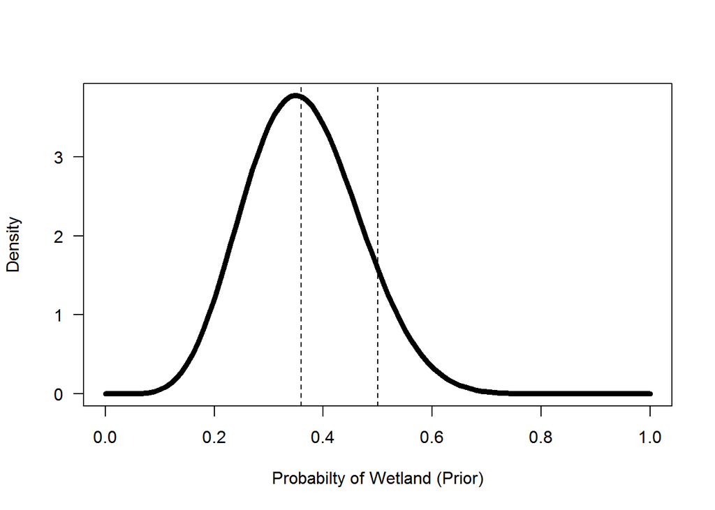

```r
curve(dbeta(x, a, b),
      from = 0, to = 1,
      xlab = "Probabilty of Wetland (Prior)",
      ylab = "Density",
      cex.lab  = 1,
      lwd = 5, las = 1,
      col="black")
abline(v = .5, lty = 2)
abline(v = Pr, lty = 2)
```

### Combine Upland and Wetland Data Frames

Extract a data frame from Soils.spdf and drop a few redundant columns in preparation for subsequent Principal Components Analysis (PCA) and Multiple Correspondence Analysis (MCA).

Ensure that MCA variables are Factor and those for PCA are numeric.

```r
Soils.df = Soils.spdf@data

Soils0.df = subset(Soils.df,
                   select = -c(AREASYMBOL,  SPATIALVER, NationalMu,
                                muhelcl,  muwathelcl,  muwndhelcl,  interpfocu,
                                invesinten,  lkey,  iacornsr,  projectsca,  tabularver,
                                iccdcd,   iccdcdpct,  engstafdcd,  engstafll,  engstafml,
                                albedo_h,  albedo_l,  cropprodin,  rsprod_h,  rsprod_l,
                                rsprod_r,  slopelen_h,  slopelen_l,  cokey,  comppct_l,
                                comppct_h,  compkind,  earthcovki,  earthcov_1,  aspectccwi,
                                aspectrep,  aspectcwis,  geomdesc,  nirrcapuni,  irrcapcl,
                                irrcapscl,  irrcapunit,  constreesh,  soilslippo,  frostact,
                                soiltaxedi,  taxclname,  taxorder,  taxsuborde,  taxgrtgrou,
                                taxsubgrp,  taxparts_1, map_h,  map_l,  map_r, Shape_Leng, Shape_Area))

Soils1.df = as.data.frame(lapply
                          (Soils0.df, factor))
Soils2.df = Soils1.df %>%
            mutate(Designation = as.numeric(Soils.df$Designation),
                   IDs = as.numeric(Soils.df$IDs),
                   wtdepaprju = as.numeric(round(Soils.df$wtdepaprju),5),
                   wtdepannmi = as.numeric(round(Soils.df$wtdepannmi),5),
                   slopegradd = as.numeric(round(Soils.df$slopegradd),5),
                   slopegradw = as.numeric(round(Soils.df$slopegradw), 5),
                   aws025wta = as.numeric(round(Soils.df$aws025wta), 5),
                   aws050wta = as.numeric(round(Soils.df$aws050wta), 5),
                   aws0100wta = as.numeric(round(Soils.df$aws0100wta), 5),
                   aws0150wta = as.numeric(round(Soils.df$aws0150wta), 5),
                   niccdcdpct = as.numeric(round(Soils.df$niccdcdpct), 5),
                   albedo_r = as.numeric(round(Soils.df$albedo_r), 5),
                   elev_h = as.numeric(round(Soils.df$elev_h), 5),
                   elev_l = as.numeric(round(Soils.df$elev_l), 5),
                   elev_r = as.numeric(round(Soils.df$elev_r), 5),
                   slope_h = as.numeric(round(Soils.df$slope_h), 5),
                   slope_r = as.numeric(round(Soils.df$niccdcdpct), 5))
```

### Conduct Principal Components Analysis (PCA)

This exploratory statistic for continuous numeric variables is used to reduce dimensionality for later Bayesian analysis.

*FactoMineR* is used to run the procedure, the developer’s website: http://factominer.free.fr/classical-methods/multiple-correspondence-analysis.html

First subset variables (columns) to be included in the PCA, then run the PCA()

```r
suppressMessages(library(FactoMineR))

Soils.PCA = Soils2.df %>%
                select(slopegradd, slopegradw, aws025wta, aws050wta, aws0100wta,
                aws0150wta, niccdcdpct, albedo_r, elev_h, elev_l, elev_r, slope_h,
                slope_r, wtdepaprju, wtdepannmi)

PCA.Result = PCA(Soils.PCA ,
                 scale.unit = TRUE,
                 ncp = 5,
                 graph = FALSE)
```

### Singular Value Decomposition (SVD) to Data Frame

```r
PCA.df = as.data.frame(PCA.Result$svd$U) %>%
                 mutate(Designation = as.numeric(Soils.df$Designation))
```

### Explore PCA Results for Significant Values

Run a series of non-spatial, Bayesian models to investigate explanatory power.

Decomposed dimensions from the PCA in which zero falls outside of the credible interval are retained for possible model inclusion.

```r
#source("http://www.math.ntnu.no/inla/givemeINLA.R")
#update.packages("INLA")
suppressMessages(library("INLA"))
```

```r
Form1 = Designation ~ V1 + V2 + V3 + V4 + V5

PCAmod  =  inla(Form1, family = "binomial",
                       control.family = list(link = "cloglog"),
                       control.predictor = list(compute = TRUE),
                       control.compute=list(dic = TRUE, cpo = TRUE),
                       data = PCA.df)

summary(PCAmod)
```

```
##
## Call:
## c("inla(formula = Form1, family = \"binomial\", data = PCA.df, control.compute = list(dic = TRUE, ",  "    cpo = TRUE), control.predictor = list(compute = TRUE), control.family = list(link = \"cloglog\"))" )
##
## Time used:
##  Pre-processing    Running inla Post-processing           Total
##          0.1812          0.4264          0.2673          0.8749
##
## Fixed effects:
##                mean     sd 0.025quant 0.5quant 0.975quant    mode kld
## (Intercept) -0.0067 0.0589    -0.1209  -0.0072     0.1105 -0.0083   0
## V1          -0.2464 0.0585    -0.3619  -0.2461    -0.1323 -0.2457   0
## V2          -0.1852 0.0614    -0.3083  -0.1843    -0.0672 -0.1824   0
## V3          -0.1276 0.0588    -0.2444  -0.1272    -0.0134 -0.1263   0
## V4          -0.0230 0.0579    -0.1362  -0.0231     0.0911 -0.0235   0
## V5           0.0670 0.0593    -0.0487   0.0668     0.1841  0.0663   0
##
## The model has no random effects
##
## The model has no hyperparameters
##
## Expected number of effective parameters(std dev): 6.005(0.00)
## Number of equivalent replicates : 85.93
##
## Deviance Information Criterion (DIC) ...: 655.19
## Effective number of parameters .........: 5.991
##
## Marginal log-Likelihood:  -354.93
## CPO and PIT are computed
##
## Posterior marginals for linear predictor and fitted values computed
```

```r
PCAmod$dic$dic
```

```
## [1] 655.1856
```

```r
Form1a = Designation ~ V1 + V2 + V3

PCAmod2  =  inla(Form1a, family = "binomial",
                       control.family = list(link = "cloglog"),
                       control.predictor = list(compute = TRUE),
                       control.compute=list(dic = TRUE, cpo = TRUE),
                       data = PCA.df)
summary(PCAmod2)
```

```
##
## Call:
## c("inla(formula = Form1a, family = \"binomial\", data = PCA.df, control.compute = list(dic = TRUE, ",  "    cpo = TRUE), control.predictor = list(compute = TRUE), control.family = list(link = \"cloglog\"))" )
##
## Time used:
##  Pre-processing    Running inla Post-processing           Total
##          0.1321          0.4103          0.2695          0.8119
##
## Fixed effects:
##                mean     sd 0.025quant 0.5quant 0.975quant    mode kld
## (Intercept) -0.0078 0.0589    -0.1219  -0.0083     0.1093 -0.0094   0
## V1          -0.2462 0.0580    -0.3607  -0.2459    -0.1330 -0.2455   0
## V2          -0.1924 0.0628    -0.3179  -0.1917    -0.0709 -0.1904   0
## V3          -0.1241 0.0584    -0.2402  -0.1236    -0.0107 -0.1227   0
##
## The model has no random effects
##
## The model has no hyperparameters
##
## Expected number of effective parameters(std dev): 4.005(0.00)
## Number of equivalent replicates : 128.84
##
## Deviance Information Criterion (DIC) ...: 652.64
## Effective number of parameters .........: 3.998
##
## Marginal log-Likelihood:  -343.06
## CPO and PIT are computed
##
## Posterior marginals for linear predictor and fitted values computed
```

```r
PCAmod2$dic$dic
```

```
## [1] 652.6368
```

### Conduct Multiple Correspondance Analysis (MCA)

The MCA is similar a Principal Components Analysis (PCA); but, for nominal datasets. As with the PCA, this exploratory statistic is used to narrow variables for later Bayesian analysis.

First subset variables (columns) to be included in the MCA, then run the MCA()

```r
Soils.MCA = Soils2.df %>%
               select(MUSYM, muname, mukind, farmlndcl, museq, brockdepmi,
                      flodfreqdc, flodfreqma, pondfreqpr, drclassdcd,
                      drclasswet, hydgrpdcd, niccdcd, engdwobdcd, engdwbdcd,  engdwbll,
                      engdwbml,   engsldcd,   engsldcp, englrsdcd,  engcmssdcd, engcmssmp,
                      urbrecptdc, urbrecptwt, forpehrtdc, hydclprs, awmmfpwwta, airtempa_h,
                      airtempa_l, airtempa_r, ffd_h, ffd_l, ffd_r, initsub_h, initsub_l,
                      initsub_r, slope_l, slopelen_r, totalsub_h, totalsub_l, totalsub_r,
                      compname, otherph, localphase, runoff, tfact, wei, weg, erocl,
                      hydricon, nirrcapcl, nirrcapscl, foragesuit, wlgrai, wlgrass, wlherbaceo,
                      wlshrub, wlconifero, wlhardwood, wlwetplant, wlshalloww, wlrangelan,
                      wlopenland, wlwoodland, wlwetland, corcon, corsteel, taxpartsiz,
                      taxceactcl, taxreactio, taxtempcl, taxmoistsc, taxtempreg)

MCA.Result = MCA(Soils.MCA,
                 ncp=5,
                 graph = FALSE)
```

### MCA Singular Value Decomposition (SVD) to .df

Pull SVD values from the MCA and add the associated Wetland/Upland “Designation” in a new data frame.

```r
MCA.df = as.data.frame(MCA.Result$svd$U) %>%
                 mutate(Designation = as.numeric(Soils.df$Designation))
```

### Explore MCA Results for Significant Values

As with the PCA, the explanatory power of values from the MCA are explored.

Decomposed dimensions from the MCA in which zero falls outside of the credible interval are retained for possible model inclusion.

```r
Form2 = Designation ~ V1 + V2 + V3 + V4 + V5

MCAmod  =  inla(Form2, family = "binomial",
                       control.family = list(link = "cloglog"),
                       control.predictor = list(compute = TRUE),
                       control.compute=list(dic = TRUE, cpo = TRUE),
                       data = MCA.df)

summary(MCAmod)
```

```
##
## Call:
## c("inla(formula = Form2, family = \"binomial\", data = MCA.df, control.compute = list(dic = TRUE, ",  "    cpo = TRUE), control.predictor = list(compute = TRUE), control.family = list(link = \"cloglog\"))" )
##
## Time used:
##  Pre-processing    Running inla Post-processing           Total
##          0.1501          0.4284          0.2847          0.8631
##
## Fixed effects:
##                mean     sd 0.025quant 0.5quant 0.975quant    mode kld
## (Intercept)  0.0610 0.0644    -0.0545   0.0571     0.1984  0.0488   0
## V1           0.2689 0.3127    -0.2004   0.2177     0.9973  0.0808   0
## V2          -0.1788 0.1650    -0.5625  -0.1523     0.0705 -0.0833   0
## V3           0.3378 0.0642     0.2189   0.3351     0.4714  0.3296   0
## V4          -0.0185 0.0610    -0.1331  -0.0204     0.1071 -0.0244   0
## V5           0.1065 0.0610    -0.0130   0.1063     0.2264  0.1061   0
##
## The model has no random effects
##
## The model has no hyperparameters
##
## Expected number of effective parameters(std dev): 6.005(0.00)
## Number of equivalent replicates : 85.93
##
## Deviance Information Criterion (DIC) ...: Inf
## Effective number of parameters .........: Inf
##
## Marginal log-Likelihood:  -354.33
## CPO and PIT are computed
##
## Posterior marginals for linear predictor and fitted values computed
```

```r
MCAmod$dic$dic
```

```
## [1] Inf
```

```r
Form2a = Designation ~ V3

MCAmod2  =  inla(Form2a, family = "binomial",
                       control.family = list(link = "cloglog"),
                       control.predictor = list(compute = TRUE),
                       control.compute=list(dic = TRUE, cpo = TRUE),
                       data = MCA.df)
summary(MCAmod2)
```

```
##
## Call:
## c("inla(formula = Form2a, family = \"binomial\", data = MCA.df, control.compute = list(dic = TRUE, ",  "    cpo = TRUE), control.predictor = list(compute = TRUE), control.family = list(link = \"cloglog\"))" )
##
## Time used:
##  Pre-processing    Running inla Post-processing           Total
##          0.1151          0.3863          0.2517          0.7531
##
## Fixed effects:
##                mean     sd 0.025quant 0.5quant 0.975quant    mode kld
## (Intercept) -0.0063 0.0586    -0.1198  -0.0068     0.1103 -0.0079   0
## V3           0.2893 0.0632     0.1673   0.2886     0.4154  0.2871   0
##
## The model has no random effects
##
## The model has no hyperparameters
##
## Expected number of effective parameters(std dev): 2.005(0.00)
## Number of equivalent replicates : 257.37
##
## Deviance Information Criterion (DIC) ...: 657.99
## Effective number of parameters .........: 2.003
##
## Marginal log-Likelihood:  -335.16
## CPO and PIT are computed
##
## Posterior marginals for linear predictor and fitted values computed
```

```r
MCAmod2$dic$dic
```

```
## [1] 657.9881
```

### Combine Significant MCA and PCA Results

Attach the significant MCA and PCA results to Soils2.spdf.

Also added is the “MUKEY” column from the Soils.spdf that will be used to explore additional soils data later.

```r
Soils2.spdf = Soils.spdf

Soils2.spdf@data = PCA.df %>%
                   select(Designation, V1, V2, V3) %>%
                   mutate(MCA3 = MCA.df[,"V3"],
                          MUKEY = as.numeric(Soils.spdf@data[,"MUKEY"]))
```

### Convert Soils PCA and MCA Results to Raster Objects

First, create a raster template based on the resolution specified at top of the script.

```r
Blank.r = raster(nrows = yROW, ncols = xCOL)
extent(Blank.r) = extent(Soils2.spdf)
proj4string(Blank.r) = proj4string(Soils2.spdf)
```

### Create Wetland/Upland Designation Raster

```r
w_rast = rasterize(Wet_Soils.spdf,
                   Blank.r,
                   field = 1)

w_rast = reclassify(w_rast,
                    cbind(NA, 0))
```

### Create Rasters for Significatnt PCA/MCA Results

```r
V1_rast = rasterize(Soils2.spdf,
                    Blank.r,
                    field = Soils2.spdf@data$V1)

V2_rast = rasterize(Soils2.spdf,
                    Blank.r,
                    field = Soils2.spdf@data$V2)

V3_rast = rasterize(Soils2.spdf,
                    Blank.r,
                    field = Soils2.spdf@data$V3)

MCA3_rast = rasterize(Soils2.spdf,
                    Blank.r,
                    field = Soils2.spdf@data$MCA3)
```

### Convert Rasters to SpatialPolygonsDataFrame

Add PCA and MCA results

```r
Wetlands.spdf = as(w_rast, "SpatialPolygonsDataFrame")
names(Wetlands.spdf) = "Designation"

Wetlands.spdf@data = Wetlands.spdf@data %>%
                        mutate(V1 = values(V1_rast),
                               V2 = values(V2_rast),
                               V3 = values(V3_rast),
                               MCAV3 = values(MCA3_rast))
```

### Soil Available Water Capacity (AWC) and Organic Mass (OM)

The soils attribute “awc_r” describes the amount of water that an increment of soil depth (inclusive of fragments) can store that is available to plants and can be used to calculate an “AWC”. AWC is expressed as a volume fraction, and is commonly estimated as the difference between the water contents at 1/10 or 1/3 bar (field capacity) and 15 bars (permanent wilting point) tension and adjusted for salinity, and fragments. AWC is often used to estimate Available Water Storage.

The soils attribute “OM_r” describes the amount (by weight) of decomposed plant and animal residue expressed as a weight percentage of the less than 2 mm soil material. The “Organic Mass” variable is commonly used to estimate Soil Organic Carbon content.

The “awc_r” and “OM_r” variables were not included in the soils data explored so far - though they are used to estimate some of the explored soils attributes. These are downloaded for the study domain from the NRCS “live” database; they’re then averaged by soil horizon, soil profile, and Soil Mapping Unit. ###Additional Libraries are Needed

```r
#install.packages('Hmisc', dep=TRUE)
suppressMessages(library(Hmisc))

#install.packages('soilDB', dep=TRUE) #from CRAN + dependencies
#install.packages("soilDB", repos="http://R-Forge.R-project.org") # most recent from r-forge
suppressMessages(library(soilDB))

#install.packages("SSOAP", repos = "http://www.omegahat.org/R", type="source") # SSOAP, XMLSchema
suppressMessages(library(SSOAP))
```

### Query Function

This function has been modified from the “SDA_Query()” included with the *SoilDB* package.

```r
SDAquery = function (q)
{
    if (!requireNamespace("SSOAP", quietly = TRUE) | !requireNamespace("XMLSchema",
        quietly = TRUE))
        stop("please install the `SSOAP` and `XMLSchema` packages",
            call. = FALSE)
    opt.original <- options(stringsAsFactors = FALSE)
    s <- SSOAP::SOAPServer("SDMDataAccess.nrcs.usda.gov", "/Tabular/SDMTabularService.asmx")
    a <- I("http://SDMDataAccess.nrcs.usda.gov/Tabular/SDMTabularService.asmx/RunQuery")
    x <- c(I("http://SDMDataAccess.nrcs.usda.gov/Tabular/SDMTabularService.asmx"))
    cat("sending SOAP request...\n")
    res <- SSOAP::.SOAP(s, "RunQuery",
                        Query = q,
                        action = a,
                        xmlns = x)
    cat("processing results...\n")
    df <- ldply(res$diffgram$NewDataSet, .fun = cleanSDA, .progress = "none")
    df$.id <- NULL
    f <- tempfile()
    write.table(df, file = f, col.names = TRUE, row.names = FALSE,
        quote = FALSE, sep = "|")
    df <- read.table(f, header = TRUE, sep = "|", quote = "",
        comment.char = "")
    options(opt.original)
    return(df)
}
```

### Rasterize MUKEY

The Mapped Unit Keys (MUKEY) are used to identify locations of Mapped Soils Units in the study domain.

```r
AWC.r = rasterize(Soils2.spdf,
                      Blank.r,
                      field = Soils2.spdf@data$MUKEY)

OM.r = rasterize(Soils2.spdf,
                      Blank.r,
                      field = Soils2.spdf@data$MUKEY)
```

### Soil Functions

These functions will be used for aggregating horizon-level data within each map unit.

The first two will profile AWC and OM values by soil horizon.

```r
HzWS = function(i) {
              wt = i$comppct_r[1]
              thick = with(i, hzdepb_r - hzdept_r)
              whc = thick * i$awc_r
                whc.total = sum(whc, na.rm=TRUE)
                data.frame(whc = whc.total, wt=wt)
}

HzWSO = function(i) {
              wto = i$comppct_r[1]
              thicko = with(i, hzdepb_r - hzdept_r)
              whco = thicko * i$Om_r
                whc.totalo = sum(whco, na.rm=TRUE)
                data.frame(whco = whc.totalo, wto=wto)
}
```

The next two functions find the average (weighted by component percentage) within each Soil Map Unit

```r
MU_mean = function(i) {
                  whc = wtd.mean(i$whc, weights=i$wt)
                  data.frame(whc=whc)
}

MU_meano = function(i) {
                  whco = wtd.mean(i$whco, weights=i$wto)
                  data.frame(whco=whco)
}
```

### Add Raster Attribute Table (RAT)

```r
AWC.r = ratify(AWC.r,
               count = TRUE)

OM.r = ratify(OM.r,
               count = TRUE)
```

### save RATs as Objects

```r
rat = levels(AWC.r)[[1]]

rato = levels(OM.r)[[1]]
```

### Extract MUKEYs from the RAT

To be used in a SQL “IN-statement” to query the soils database.

```r
in.statement = format_SQL_in_statement(rat$ID)

in.statement2 = format_SQL_in_statement(rato$ID)
```

### Query SDA

Submit a data SQL query to the Soil Data Access server (SDA); requesting horizon-level data.

```r
q = paste("SELECT component.mukey, component.cokey, compname, comppct_r, hzdept_r, hzdepb_r, hzname, Om_r, awc_r FROM component JOIN chorizon ON component.cokey = chorizon.cokey AND mukey IN ", in.statement, "ORDER BY mukey, comppct_r DESC, hzdept_r ASC", sep ="")

ACW.res = SDAquery(q)
```

```
## sending SOAP request...
## processing results...
```

```r
q2 = paste("SELECT component.mukey, component.cokey, compname, comppct_r, hzdept_r, hzdepb_r, hzname, Om_r, awc_r FROM component JOIN chorizon ON component.cokey = chorizon.cokey AND mukey IN ", in.statement2, "ORDER BY mukey, comppct_r DESC, hzdept_r ASC", sep ="")

OM.res = SDAquery(q2)
```

```
## sending SOAP request...
## processing results...
```

### Aggregate Data

Running custom soil functions.

```r
co.whc = ACW.res %>%
              group_by(mukey, cokey) %>%
              do(HzWS(.))

mu.whc = co.whc %>%
              group_by(mukey) %>%
              do(MU_mean(.))

co.whco = OM.res %>%
              group_by(mukey, cokey) %>%
              do(HzWSO(.))

mu.whco = co.whco %>%
              group_by(mukey) %>%
              do(MU_meano(.))
```

### Join Results to Domain Rasters

```r
names(mu.whc)[1] = 'ID'
rat.new = left_join(rat, mu.whc)
levels(AWC.r) = rat.new
AWC = deratify(AWC.r, att='whc')

names(mu.whco)[1] = 'ID'
rato.new = left_join(rato, mu.whco)
levels(OM.r) = rato.new
OM = deratify(OM.r, att='whco')
```

### Add Results to Wetlands.spdf

```r
Wetlands.spdf$AWC = values(AWC)
Wetlands.spdf$OM = values(OM)
```

### Verify Significance

```r
Form3 = Designation ~ AWC

AWCmod  =  inla(Form3, family = "binomial",
                       control.family = list(link = "cloglog"),
                       control.predictor = list(compute = TRUE),
                       control.compute=list(dic = TRUE, cpo = TRUE),
                       data = Wetlands.spdf@data)
summary(AWCmod)
```

```
##
## Call:
## c("inla(formula = Form3, family = \"binomial\", data = Wetlands.spdf@data, ",  "    control.compute = list(dic = TRUE, cpo = TRUE), control.predictor = list(compute = TRUE), ",  "    control.family = list(link = \"cloglog\"))")
##
## Time used:
##  Pre-processing    Running inla Post-processing           Total
##          0.1822         45.1271          2.5080         47.8172
##
## Fixed effects:
##                mean     sd 0.025quant 0.5quant 0.975quant    mode kld
## (Intercept) -1.0611 0.0144    -1.0893  -1.0611    -1.0330 -1.0611   0
## AWC          0.0370 0.0013     0.0346   0.0370     0.0395  0.0370   0
##
## The model has no random effects
##
## The model has no hyperparameters
##
## Expected number of effective parameters(std dev): 2.404(0.00)
## Number of equivalent replicates : 16639.11
##
## Deviance Information Criterion (DIC) ...: 31311.54
## Effective number of parameters .........: 2.404
##
## Marginal log-Likelihood:  -15668.02
## CPO and PIT are computed
##
## Posterior marginals for linear predictor and fitted values computed
```

```r
AWCmod$dic$dic
```

```
## [1] 31311.54
```

```r
Form4 = Designation ~ OM

OMmod  =  inla(Form4, family = "binomial",
                       control.family = list(link = "cloglog"),
                       control.predictor = list(compute = TRUE),
                       control.compute=list(dic = TRUE, cpo = TRUE),
                       data = Wetlands.spdf@data)
summary(OMmod)
```

```
##
## Call:
## c("inla(formula = Form4, family = \"binomial\", data = Wetlands.spdf@data, ",  "    control.compute = list(dic = TRUE, cpo = TRUE), control.predictor = list(compute = TRUE), ",  "    control.family = list(link = \"cloglog\"))")
##
## Time used:
##  Pre-processing    Running inla Post-processing           Total
##          0.1732         45.6474          2.3544         48.1751
##
## Fixed effects:
##                mean     sd 0.025quant 0.5quant 0.975quant    mode kld
## (Intercept) -1.3000 0.0137    -1.3269  -1.3000    -1.2732 -1.2999   0
## OM           0.0091 0.0002     0.0087   0.0091     0.0095  0.0091   0
##
## The model has no random effects
##
## The model has no hyperparameters
##
## Expected number of effective parameters(std dev): 2.371(0.00)
## Number of equivalent replicates : 16870.67
##
## Deviance Information Criterion (DIC) ...: 28862.11
## Effective number of parameters .........: 2.371
##
## Marginal log-Likelihood:  -14445.24
## CPO and PIT are computed
##
## Posterior marginals for linear predictor and fitted values computed
```

```r
OMmod$dic$dic
```

```
## [1] 28862.11
```

### Soil Adjusted Vegetation Index (SAVI)

Reflectance data from the LandSat8 Satellite is used to calculate a Soil Adjusted Vegetation Index (SAVI). The data is freely available from the USGS and can be accessed here: http://landsat.usgs.gov/landsat8.php

The SAVI is calculated as the ratio between the Red (R) and Near Infrared (NIR) values from the LandSat8 Satellite with a soil brightness correction factor (L) defined as 0.5 to accommodate most land cover types: ((NIR - R) / (NIR + R + L)) * (1 + L)

```r
Band4 = raster("./WetlandData/LS8/ls8_band4/w001001.adf")

Band5 = raster("./WetlandData/LS8/ls8_band5/w001001.adf")

savi = ((Band5 - Band4) / (Band5 + Band4 + 0.5)) * (1.5)

DomainB = readOGR(dsn = "./WetlandData/Domains/Domain100",
                  layer = "Domain100",
                  stringsAsFactors = FALSE)
DomainBp = spTransform(DomainB,
                       CRS(projection(savi)))

savi100 = crop(savi, DomainBp)
extent(savi100) = extent(Blank.r)

SAVI = resample(savi100, Blank.r,
                method = 'bilinear')

Wetlands.spdf$SAVI = values(SAVI)
```

### Verify Significance of SAVI

```r
Form5 = Designation ~ SAVI

SAVImod  =  inla(Form5, family = "binomial",
                       control.family = list(link = "cloglog"),
                       control.predictor = list(compute = TRUE),
                       control.compute=list(dic = TRUE, cpo = TRUE),
                       data = Wetlands.spdf@data)
summary(SAVImod)
```

```
##
## Call:
## c("inla(formula = Form5, family = \"binomial\", data = Wetlands.spdf@data, ",  "    control.compute = list(dic = TRUE, cpo = TRUE), control.predictor = list(compute = TRUE), ",  "    control.family = list(link = \"cloglog\"))")
##
## Time used:
##  Pre-processing    Running inla Post-processing           Total
##          0.1762         47.1490          2.2443         49.5695
##
## Fixed effects:
##                mean     sd 0.025quant 0.5quant 0.975quant    mode kld
## (Intercept) -1.2478 0.0397    -1.3255  -1.2479    -1.1696 -1.2481   0
## SAVI         0.4527 0.0314     0.3908   0.4528     0.5141  0.4530   0
##
## The model has no random effects
##
## The model has no hyperparameters
##
## Expected number of effective parameters(std dev): 2.417(0.00)
## Number of equivalent replicates : 16548.42
##
## Deviance Information Criterion (DIC) ...: 32020.44
## Effective number of parameters .........: 2.418
##
## Marginal log-Likelihood:  -16019.24
## CPO and PIT are computed
##
## Posterior marginals for linear predictor and fitted values computed
```

```r
SAVImod$dic$dic
```

```
## [1] 32020.44
```

### Explanatory Variables linked to Topograpy

The preceding analysis served to identify soil and vegetative related attributes. Next, explore topographic data to identify additional explanatory variables related to hydrology.

The calculations bellow incorporate the the 1/3 arc-second Digital Elevation Model from the National Elevation Dataset, which is freely available here: http://ned.usgs.gov/

Read DEM data and crop to domain.

```r
#DEM (USGS 1/3 arc-sec)
      DEM = raster("./WetlandData/DEM_NWF/dem_nwf/w001001.adf")
      DEM = reclassify(DEM,
                        cbind(0, 0.001))

      DomainBp = spTransform(DomainB,
                 CRS(projection(DEM)))

      DEM = crop(DEM, DomainBp)
```

### Calculate Topographic Indicies

The Topographic Position Index (TPI) is often used to classify different landscape morphologies (i.e. canyons vs. mountains vs. plains); it’s a type of “ruggedness” or “roughness” index. It is calculated as the difference between the value of a cell and the mean value of its 8 surrounding cells.

Here the TPI is automatically calculated using the *raster* package.  
Values are then added to the Wetlands.spdf.

```r
RR = raster(nrow = yROW, ncol = xCOL)
extent(RR) = extent(DEM)

DEM2 = resample(DEM, RR,
                method='bilinear')

tpi = terrain(DEM2,
              opt = 'tpi')

TPI = reclassify(tpi,
                 cbind(NA, minValue(tpi)))

proj4string(TPI) = proj4string(LCLU_NWF.spdf)
extent(TPI) = extent(LCLU_NWF.spdf)

Wetlands.spdf$TPI = values(TPI)
```

### Verify Significance of TPI

```r
Form6 = Designation ~ TPI

TPImod  =  inla(Form6, family = "binomial",
                       control.family = list(link = "cloglog"),
                       control.predictor = list(compute = TRUE),
                       control.compute=list(dic = TRUE, cpo = TRUE),
                       data = Wetlands.spdf@data)
summary(TPImod)
```

```
##
## Call:
## c("inla(formula = Form6, family = \"binomial\", data = Wetlands.spdf@data, ",  "    control.compute = list(dic = TRUE, cpo = TRUE), control.predictor = list(compute = TRUE), ",  "    control.family = list(link = \"cloglog\"))")
##
## Time used:
##  Pre-processing    Running inla Post-processing           Total
##          0.1791         45.9697          2.4622         48.6110
##
## Fixed effects:
##                mean     sd 0.025quant 0.5quant 0.975quant    mode kld
## (Intercept) -0.7022 0.0064    -0.7148  -0.7022    -0.6896 -0.7022   0
## TPI         -0.2254 0.0137    -0.2525  -0.2253    -0.1987 -0.2252   0
##
## The model has no random effects
##
## The model has no hyperparameters
##
## Expected number of effective parameters(std dev): 2.415(0.00)
## Number of equivalent replicates : 16562.96
##
## Deviance Information Criterion (DIC) ...: 31909.30
## Effective number of parameters .........: 2.415
##
## Marginal log-Likelihood:  -15964.66
## CPO and PIT are computed
##
## Posterior marginals for linear predictor and fitted values computed
```

```r
TPImod$dic$dic
```

```
## [1] 31909.3
```

Create a Compound Topographic Index (CTI) (aka a “Wetness Index”).

CTI values are scaled such that higher values represent represent drainage depressions (wetter areas), and lower values represent elevated or drier areas.

CTI = ln(a/tan B) Where “a” is the upstream contributing area in m2 (Flow Accumulation) and “B” is the slope as measured in (Radians)

This calculation is carried-out using the *dynatopmodel* package. Resulting values are added to the Wetlands.spdf.

```r
suppressMessages(library(dynatopmodel))
CTI0 = upslope.area(DEM,
                    log = TRUE,
                    atb = TRUE,
                    deg = 0.1)

CTI = reclassify(CTI0$atb,
                 cbind(NA, maxValue(CTI0)))

extent(CTI) = extent(LCLU_NWF.spdf)
CTI = resample(CTI, Blank.r, method = 'bilinear')

Wetlands.spdf$CTI = values(CTI)
```

### Verify Significance of CTI

```r
Form7 = Designation ~ CTI

CTImod  =  inla(Form7, family = "binomial",
                       control.family = list(link = "cloglog"),
                       control.predictor = list(compute = TRUE),
                       control.compute=list(dic = TRUE, cpo = TRUE),
                       data = Wetlands.spdf@data)
summary(CTImod)
```

```
##
## Call:
## c("inla(formula = Form7, family = \"binomial\", data = Wetlands.spdf@data, ",  "    control.compute = list(dic = TRUE, cpo = TRUE), control.predictor = list(compute = TRUE), ",  "    control.family = list(link = \"cloglog\"))")
##
## Time used:
##  Pre-processing    Running inla Post-processing           Total
##          0.1851         46.2109          2.5070         48.9030
##
## Fixed effects:
##                mean     sd 0.025quant 0.5quant 0.975quant    mode kld
## (Intercept) -2.4521 0.0450    -2.5406  -2.4520    -2.3639 -2.4520   0
## CTI          0.1611 0.0041     0.1531   0.1611     0.1691  0.1611   0
##
## The model has no random effects
##
## The model has no hyperparameters
##
## Expected number of effective parameters(std dev): 2.393(0.00)
## Number of equivalent replicates : 16718.01
##
## Deviance Information Criterion (DIC) ...: 30522.06
## Effective number of parameters .........: 2.393
##
## Marginal log-Likelihood:  -15272.10
## CPO and PIT are computed
##
## Posterior marginals for linear predictor and fitted values computed
```

```r
CTImod$dic$dic
```

```
## [1] 30522.06
```

### Initial Evaluation for Collinearity

Colldiag() is an implementation of the regression collinearity diagnostic procedures found in Belsley, Kuh, and Welsch (1980). These procedures examine the “conditioning” of the matrix of independent variables.

Colldiag() computes the condition indexes of the matrix. If the largest condition index (the condition number) is large (Belsley et al suggest 30 or higher), then there may be collinearity problem.

```r
suppressMessages(library(perturb))
Col.df = Wetlands.spdf@data %>%
            select(V1, V2, V3, MCAV3, AWC, OM, SAVI, TPI, CTI)

CI = colldiag(Col.df)
CI
```

```
## Condition
## Index    Variance Decomposition Proportions
##            intercept V1    V2    V3    MCAV3 AWC   OM    SAVI  TPI   CTI
## 1    1.000 0.000     0.001 0.004 0.001 0.002 0.001 0.003 0.001 0.001 0.001
## 2    1.707 0.000     0.044 0.025 0.000 0.030 0.000 0.004 0.000 0.012 0.000
## 3    2.067 0.000     0.000 0.106 0.330 0.003 0.000 0.001 0.000 0.028 0.000
## 4    2.331 0.000     0.002 0.002 0.016 0.001 0.000 0.001 0.000 0.952 0.000
## 5    2.976 0.000     0.033 0.510 0.235 0.007 0.000 0.010 0.000 0.000 0.000
## 6    6.046 0.004     0.004 0.067 0.226 0.002 0.002 0.467 0.012 0.001 0.019
## 7    7.237 0.000     0.816 0.012 0.111 0.794 0.006 0.002 0.001 0.002 0.002
## 8   14.865 0.000     0.065 0.193 0.060 0.145 0.610 0.399 0.006 0.001 0.277
## 9   16.975 0.002     0.023 0.065 0.006 0.016 0.225 0.105 0.483 0.004 0.353
## 10  31.151 0.994     0.013 0.015 0.016 0.000 0.156 0.008 0.497 0.000 0.348
```

```r
detach("package:perturb", unload=TRUE)
```

# Bayesian Analysis

Bayesian analysis is conducted to identify the probability of wetland presence using the explanatory variables from the PCA, MCA, SAVI, and Topographic Indices.

### Assign Region and IDs Labels

```r
Wetlands.spdf$Region = 1:nrow(Wetlands.spdf)
```

### Spatial Neighborhood as an INLA Graph

Define spatial neighborhood.

```r
nb = poly2nb(Wetlands.spdf,
                queen = FALSE)

nb2INLA("J", nb)
J = inla.read.graph("J")

#summary(nb)
```

## Spatial Structure Only

### (Conditional Autoregressive - CAR)

The “adjust.for.con.comp”" control adjust the graph when it has more than one connected component.

The “scale.model” option specifies that the model should be scaled to have an average variance equal to 1. See: http://www.math.ntnu.no/inla/r-inla.org/doc/latent/besag.pdf

```r
formula0 = Designation ~ f(Region, model = "besag",
                           scale.model = TRUE,
                           adjust.for.con.comp = FALSE,
                           graph = J)


model0  =  inla(formula0, family = "binomial",
                control.family = list(link = "cloglog"),
                control.predictor = list(compute = TRUE),
                control.compute = list(cpo = TRUE, waic=TRUE),
                data = Wetlands.spdf@data)

summary(model0)
```

```
##
## Call:
## c("inla(formula = formula0, family = \"binomial\", data = Wetlands.spdf@data, ",  "    control.compute = list(cpo = TRUE, waic = TRUE), control.predictor = list(compute = TRUE), ",  "    control.family = list(link = \"cloglog\"))")
##
## Time used:
##  Pre-processing    Running inla Post-processing           Total
##          0.9297        906.1750          4.1483        911.2530
##
## Fixed effects:
##               mean     sd 0.025quant 0.5quant 0.975quant    mode   kld
## (Intercept) -8.071 0.2437    -8.4589  -7.9435    -7.7776 -7.8428 1e-04
##
## Random effects:
## Name   Model
##  Region   Besags ICAR model
##
## Model hyperparameters:
##                        mean     sd 0.025quant 0.5quant 0.975quant   mode
## Precision for Region 0.1431 0.0041     0.1347   0.1433      0.151 0.1437
##
## Expected number of effective parameters(std dev): 5089.35(44.27)
## Number of equivalent replicates : 7.86
##
## Watanabe-Akaike information criterion (WAIC) ...: 5319.73
## Effective number of parameters .................: 449.64
##
## Marginal log-Likelihood:  -32414.57
## CPO and PIT are computed
##
## Posterior marginals for linear predictor and fitted values computed
```

```r
Wetlands.spdf@data = Wetlands.spdf@data %>%
                        mutate(M0SLPM = model0$summary.linear.predictor[,"mean"],
                               M0Prob = exp(M0SLPM)/(1+exp(M0SLPM)))
```

### Figure 2a (Plot Random Effects)

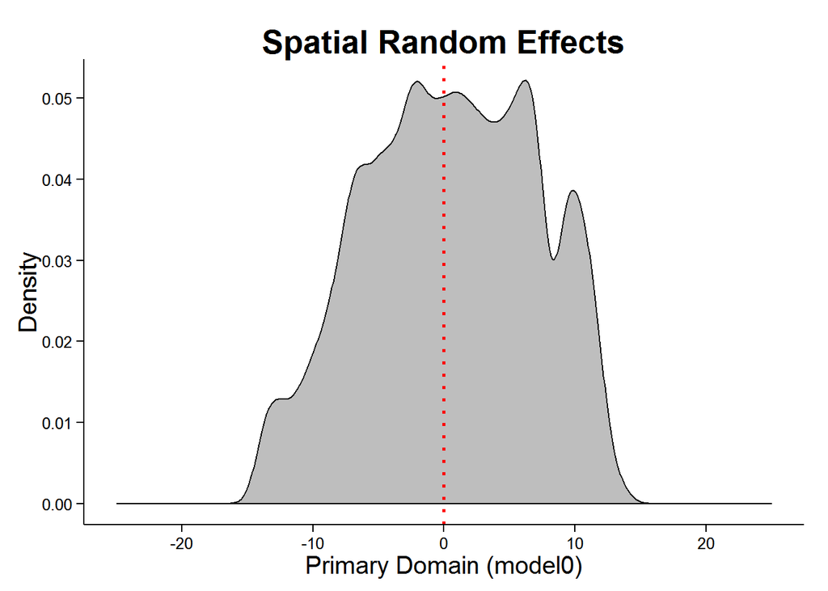

```r
RE.r = Blank.r
Wetlands.spdf$SREm0 = model0$summary.random$Region[,2]
values(RE.r) = (exp(model0$summary.random$Region$mean/12) - 1) * 100

REffect = round(Wetlands.spdf$SREm0, 4)
Var = rep("RE", length(REffect))
RE.df = data.frame(Var, REffect)
RE.df$REffect = as.numeric(RE.df$REffect)

RE.d = ggplot(RE.df, aes(REffect, fill = as.factor(Var))) +
              geom_density(fill = "grey") +
              theme_classic() +
              xlim(-25, 25) +
                 xlab("Primary Domain (model0)") +
                 ylab("Density") +
                 theme(axis.title.y = element_text(size = 15),
                       axis.title.x = element_text(size = 15),
                       plot.title = element_text(size = 20, face="bold")) +
                 geom_vline(data = RE.df,
                 aes(xintercept = 0,
                     colour = Run),
                     linetype = "dotted",
                     size = 1, col = "red") +
                ggtitle("Spatial Random Effects")

RE.d
```

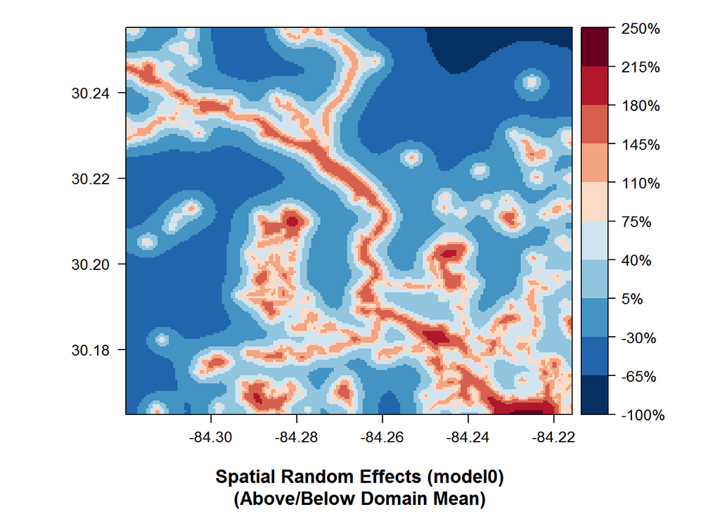

```r
rng = seq(-100, 250, 35)

rngL = paste(rng, '%', sep = "")
cr = rev(brewer.pal(10, "RdBu"))

M0RE = levelplot(RE.r, margin = FALSE,
          sub = "                Spatial Random Effects (model0)                \n(Above/Below Domain Mean)",
          xlab = NULL, ylab = NULL,
          col.regions = cr, at = rng,
          colorkey = list(at = rng, labels = rngL, col = cr),
          par.settings = list(fontsize = list(text = 13)))

M0RE
```

## Add Explanatory Variables

### (Spatial Structure + Covariates)

```r
formula1 = Designation ~ f(Region, model = "besag",
                           adjust.for.con.comp = FALSE,
                           scale.model = TRUE,
                           hyper = hyper.p,
                           graph = J) +
                         V1

model1  =  inla(formula1, family = "binomial",
                       control.family = list(link = "cloglog"),
                       control.predictor = list(compute = TRUE),
                       control.compute=list(cpo = TRUE, waic=TRUE),
                       data = Wetlands.spdf@data)

summary(model1)
```

```
##
## Call:
## c("inla(formula = formula1, family = \"binomial\", data = Wetlands.spdf@data, ",  "    control.compute = list(cpo = TRUE, waic = TRUE), control.predictor = list(compute = TRUE), ",  "    control.family = list(link = \"cloglog\"))")
##
## Time used:
##  Pre-processing    Running inla Post-processing           Total
##          0.9336        937.7827          4.0235        942.7398
##
## Fixed effects:
##                mean     sd 0.025quant 0.5quant 0.975quant    mode kld
## (Intercept) -7.4277 0.1964    -7.7070  -7.5003    -7.0270 -7.5478   0
## V1          -2.1133 0.0604    -2.2296  -2.1140    -1.9939 -2.1162   0
##
## Random effects:
## Name   Model
##  Region   Besags ICAR model
##
## Model hyperparameters:
##                        mean     sd 0.025quant 0.5quant 0.975quant   mode
## Precision for Region 0.1346 0.0046     0.1252   0.1348      0.143 0.1354
##
## Expected number of effective parameters(std dev): 4488.50(34.32)
## Number of equivalent replicates : 8.912
##
## Watanabe-Akaike information criterion (WAIC) ...: 4929.66
## Effective number of parameters .................: 449.10
##
## Marginal log-Likelihood:  -31758.88
## CPO and PIT are computed
##
## Posterior marginals for linear predictor and fitted values computed
```

```r
Wetlands.spdf@data = Wetlands.spdf@data %>%
                        mutate(M1SLPM = model1$summary.linear.predictor[,"mean"],
                               M1Prob = exp(M1SLPM)/(1+exp(M1SLPM)))
```

## model2

```r
formula2 = Designation ~ f(Region, model = "besag",
                           adjust.for.con.comp = FALSE,
                           scale.model = TRUE,
                           hyper = hyper.p,
                           graph = J) +
                         V1 + V2

model2  =  inla(formula2, family = "binomial",
                       control.family = list(link = "cloglog"),
                       control.predictor = list(compute = TRUE),
                       control.compute=list(cpo = TRUE, waic=TRUE),
                       data = Wetlands.spdf@data)

summary(model2)
```

```
##
## Call:
## c("inla(formula = formula2, family = \"binomial\", data = Wetlands.spdf@data, ",  "    control.compute = list(cpo = TRUE, waic = TRUE), control.predictor = list(compute = TRUE), ",  "    control.family = list(link = \"cloglog\"))")
##
## Time used:
##  Pre-processing    Running inla Post-processing           Total
##          1.0268        972.6336          4.2601        977.9205
##
## Fixed effects:
##                mean     sd 0.025quant 0.5quant 0.975quant    mode kld
## (Intercept) -6.3861 0.2412    -6.8061  -6.3928    -5.9532 -6.3734   0
## V1          -2.5001 0.0825    -2.6597  -2.5006    -2.3399 -2.5037   0
## V2          -0.9213 0.0500    -1.0214  -0.9205    -0.8251 -0.9191   0
##
## Random effects:
## Name   Model
##  Region   Besags ICAR model
##
## Model hyperparameters:
##                        mean     sd 0.025quant 0.5quant 0.975quant   mode
## Precision for Region 0.1328 0.0073     0.1197   0.1323     0.1483 0.1311
##
## Expected number of effective parameters(std dev): 4283.44(51.45)
## Number of equivalent replicates : 9.338
##
## Watanabe-Akaike information criterion (WAIC) ...: 4815.65
## Effective number of parameters .................: 445.04
##
## Marginal log-Likelihood:  -31557.24
## CPO and PIT are computed
##
## Posterior marginals for linear predictor and fitted values computed
```

```r
Wetlands.spdf@data = Wetlands.spdf@data %>%
                        mutate(M2SLPM = model2$summary.linear.predictor[,"mean"],
                               M2Prob = exp(M2SLPM)/(1+exp(M2SLPM)))
```

## model3

```r
formula3 = Designation ~ f(Region, model = "besag",
                           adjust.for.con.comp = FALSE,
                           scale.model = TRUE,
                           hyper = hyper.p,
                           graph = J) +
                         V1 + V2 + V3

model3  =  inla(formula3, family = "binomial",
                       control.family = list(link = "cloglog"),
                       control.predictor = list(compute = TRUE),
                       control.compute=list(cpo = TRUE, waic=TRUE),
                       data = Wetlands.spdf@data)

summary(model3)
```

```
##
## Call:
## c("inla(formula = formula3, family = \"binomial\", data = Wetlands.spdf@data, ",  "    control.compute = list(cpo = TRUE, waic = TRUE), control.predictor = list(compute = TRUE), ",  "    control.family = list(link = \"cloglog\"))")
##
## Time used:
##  Pre-processing    Running inla Post-processing           Total
##          0.9697        980.8103          3.4170        985.1970
##
## Fixed effects:
##                mean     sd 0.025quant 0.5quant 0.975quant    mode   kld
## (Intercept) -6.8582 0.3010    -7.4516  -6.7375    -6.4904 -6.5853 2e-04
## V1          -2.5412 0.0877    -2.7226  -2.5342    -2.3873 -2.5087 0e+00
## V2          -0.8938 0.0523    -0.9996  -0.8926    -0.7945 -0.8901 0e+00
## V3          -1.0848 0.0579    -1.2005  -1.0840    -0.9734 -1.0823 0e+00
##
## Random effects:
## Name   Model
##  Region   Besags ICAR model
##
## Model hyperparameters:
##                        mean     sd 0.025quant 0.5quant 0.975quant   mode
## Precision for Region 0.1379 0.0079     0.1238   0.1373     0.1549 0.1359
##
## Expected number of effective parameters(std dev): 4114.13(56.05)
## Number of equivalent replicates : 9.723
##
## Watanabe-Akaike information criterion (WAIC) ...: 4741.55
## Effective number of parameters .................: 433.14
##
## Marginal log-Likelihood:  -31385.73
## CPO and PIT are computed
##
## Posterior marginals for linear predictor and fitted values computed
```

```r
Wetlands.spdf@data = Wetlands.spdf@data %>%
                        mutate(M3SLPM = model3$summary.linear.predictor[,"mean"],
                               M3Prob = exp(M3SLPM)/(1+exp(M3SLPM)))
```

## model4

```r
formula4 = Designation ~ f(Region, model = "besag",
                           adjust.for.con.comp = FALSE,
                           scale.model = TRUE,
                           hyper = hyper.p,
                           graph = J) +
                         V1 + V2 + V3 + AWC

model4  =  inla(formula4, family = "binomial",
                       control.family = list(link = "cloglog"),
                       control.predictor = list(compute = TRUE),
                       control.compute=list(cpo = TRUE, waic=TRUE),
                       data = Wetlands.spdf@data)

summary(model4)
```

```
##
## Call:
## c("inla(formula = formula4, family = \"binomial\", data = Wetlands.spdf@data, ",  "    control.compute = list(cpo = TRUE, waic = TRUE), control.predictor = list(compute = TRUE), ",  "    control.family = list(link = \"cloglog\"))")
##
## Time used:
##  Pre-processing    Running inla Post-processing           Total
##          1.1558       1019.1866          3.5859       1023.9283
##
## Fixed effects:
##                mean     sd 0.025quant 0.5quant 0.975quant    mode kld
## (Intercept) -8.0487 0.3220    -8.6901  -8.0079    -7.5676 -7.7651   0
## V1          -2.3634 0.0868    -2.5401  -2.3585    -2.2067 -2.3403   0
## V2          -1.1533 0.0556    -1.2660  -1.1518    -1.0485 -1.1482   0
## V3          -0.9472 0.0562    -1.0589  -0.9467    -0.8381 -0.9457   0
## AWC          0.1891 0.0104     0.1693   0.1889     0.2101  0.1884   0
##
## Random effects:
## Name   Model
##  Region   Besags ICAR model
##
## Model hyperparameters:
##                        mean     sd 0.025quant 0.5quant 0.975quant   mode
## Precision for Region 0.1347 0.0076     0.1208   0.1343     0.1507 0.1333
##
## Expected number of effective parameters(std dev): 3973.31(54.43)
## Number of equivalent replicates : 10.07
##
## Watanabe-Akaike information criterion (WAIC) ...: 4650.67
## Effective number of parameters .................: 438.92
##
## Marginal log-Likelihood:  -31230.15
## CPO and PIT are computed
##
## Posterior marginals for linear predictor and fitted values computed
```

```r
Wetlands.spdf@data = Wetlands.spdf@data %>%
                        mutate(M4SLPM = model4$summary.linear.predictor[,"mean"],
                               M4Prob = exp(M4SLPM)/(1+exp(M4SLPM)))
```

## model5

```r
formula5 = Designation ~ f(Region, model = "besag",
                           adjust.for.con.comp = FALSE,
                           scale.model = TRUE,
                           hyper = hyper.p,
                           graph = J) +
                         V1 + V2 + V3 + AWC + OM

model5  =  inla(formula5, family = "binomial",
                       control.family = list(link = "cloglog"),
                       control.predictor = list(compute = TRUE),
                       control.compute=list(cpo = TRUE, waic=TRUE),
                       data = Wetlands.spdf@data)

summary(model5)
```

```
##
## Call:
## c("inla(formula = formula5, family = \"binomial\", data = Wetlands.spdf@data, ",  "    control.compute = list(cpo = TRUE, waic = TRUE), control.predictor = list(compute = TRUE), ",  "    control.family = list(link = \"cloglog\"))")
##
## Time used:
##  Pre-processing    Running inla Post-processing           Total
##          1.1148       1276.5699          2.6075       1280.2923
##
## Fixed effects:
##                mean     sd 0.025quant 0.5quant 0.975quant    mode kld
## (Intercept) -7.9469 0.3199    -8.5910  -7.8965    -7.4722 -7.6762   0
## V1          -2.3821 0.0875    -2.5608  -2.3770    -2.2242 -2.3587   0
## V2          -1.1677 0.0570    -1.2832  -1.1661    -1.0603 -1.1625   0
## V3          -0.9846 0.0575    -1.0989  -0.9841    -0.8730 -0.9830   0
## AWC          0.2087 0.0124     0.1850   0.2085     0.2334  0.2081   0
## OM          -0.0024 0.0008    -0.0040  -0.0024    -0.0008 -0.0024   0
##
## Random effects:
## Name   Model
##  Region   Besags ICAR model
##
## Model hyperparameters:
##                        mean     sd 0.025quant 0.5quant 0.975quant  mode
## Precision for Region 0.1356 0.0078     0.1217   0.1351     0.1521 0.134
##
## Expected number of effective parameters(std dev): 3969.61(54.76)
## Number of equivalent replicates : 10.08
##
## Watanabe-Akaike information criterion (WAIC) ...: 4654.40
## Effective number of parameters .................: 438.16
##
## Marginal log-Likelihood:  -31238.14
## CPO and PIT are computed
##
## Posterior marginals for linear predictor and fitted values computed
```

```r
Wetlands.spdf@data = Wetlands.spdf@data %>%
                        mutate(M5SLPM = model5$summary.linear.predictor[,"mean"],
                               M5Prob = exp(M5SLPM)/(1+exp(M5SLPM)))
```

## model6

```r
formula6 = Designation ~ f(Region, model = "besag",
                           adjust.for.con.comp = FALSE,
                           scale.model = TRUE,
                           hyper = hyper.p,
                           graph = J) +
                         V1 + V2 + V3 + AWC + OM + CTI

model6  =  inla(formula6, family = "binomial",
                       control.family = list(link = "cloglog"),
                       control.predictor = list(compute = TRUE),
                       control.compute=list(cpo = TRUE, waic=TRUE),
                       data = Wetlands.spdf@data)

summary(model6)
```

```
##
## Call:
## c("inla(formula = formula6, family = \"binomial\", data = Wetlands.spdf@data, ",  "    control.compute = list(cpo = TRUE, waic = TRUE), control.predictor = list(compute = TRUE), ",  "    control.family = list(link = \"cloglog\"))")
##
## Time used:
##  Pre-processing    Running inla Post-processing           Total
##          1.1048       1163.2841          3.9233       1168.3122
##
## Fixed effects:
##                 mean     sd 0.025quant 0.5quant 0.975quant     mode kld
## (Intercept) -13.1533 0.5189   -14.1946 -13.1039   -12.2827 -12.8214   0
## V1           -2.2390 0.0856    -2.4123  -2.2355    -2.0815  -2.2237   0
## V2           -1.1169 0.0573    -1.2326  -1.1155    -1.0082  -1.1125   0
## V3           -1.0052 0.0596    -1.1237  -1.0046    -0.8897  -1.0035   0
## AWC           0.2135 0.0128     0.1890   0.2133     0.2390   0.2129   0
## OM           -0.0023 0.0008    -0.0039  -0.0023    -0.0006  -0.0023   0
## CTI           0.4805 0.0253     0.4329   0.4799     0.5316   0.4781   0
##
## Random effects:
## Name   Model
##  Region   Besags ICAR model
##
## Model hyperparameters:
##                        mean     sd 0.025quant 0.5quant 0.975quant   mode
## Precision for Region 0.1321 0.0076      0.118   0.1318     0.1479 0.1311
##
## Expected number of effective parameters(std dev): 3841.67(53.29)
## Number of equivalent replicates : 10.41
##
## Watanabe-Akaike information criterion (WAIC) ...: 4546.17
## Effective number of parameters .................: 437.30
##
## Marginal log-Likelihood:  -31093.11
## CPO and PIT are computed
##
## Posterior marginals for linear predictor and fitted values computed
```

```r
Wetlands.spdf@data = Wetlands.spdf@data %>%
                        mutate(M6SLPM = model6$summary.linear.predictor[,"mean"],
                               M6Prob = exp(M6SLPM)/(1+exp(M6SLPM)))
```

## model7

```r
D100ST = Sys.time()

formula7 = Designation ~ f(Region, model = "besag",
                           adjust.for.con.comp = FALSE,
                           scale.model = TRUE,
                           hyper = hyper.p,
                           graph = J) +
                         V1 + V2 + V3 + AWC + OM + CTI + TPI

model7  =  inla(formula7, family = "binomial",
                       control.family = list(link = "cloglog"),
                       control.predictor = list(compute = TRUE),
                       control.compute=list(cpo = TRUE, waic=TRUE),
                       data = Wetlands.spdf@data)

summary(model7)
```

```
##
## Call:
## c("inla(formula = formula7, family = \"binomial\", data = Wetlands.spdf@data, ",  "    control.compute = list(cpo = TRUE, waic = TRUE), control.predictor = list(compute = TRUE), ",  "    control.family = list(link = \"cloglog\"))")
##
## Time used:
##  Pre-processing    Running inla Post-processing           Total
##          1.0998       1214.1256          2.6767       1217.9021
##
## Fixed effects:
##                 mean     sd 0.025quant 0.5quant 0.975quant     mode kld
## (Intercept) -12.7078 0.5011   -13.7166 -12.6630   -11.8575 -12.4160   0
## V1           -2.1567 0.0843    -2.3273  -2.1535    -2.0005  -2.1440   0
## V2           -1.0858 0.0567    -1.2002  -1.0846    -0.9779  -1.0819   0
## V3           -1.0120 0.0608    -1.1330  -1.0114    -0.8944  -1.0100   0
## AWC           0.2198 0.0131     0.1948   0.2196     0.2459   0.2191   0
## OM           -0.0028 0.0008    -0.0045  -0.0029    -0.0012  -0.0029   0
## CTI           0.4459 0.0252     0.3981   0.4453     0.4965   0.4439   0
## TPI          -0.9137 0.0606    -1.0346  -0.9129    -0.7969  -0.9112   0
##
## Random effects:
## Name   Model
##  Region   Besags ICAR model
##
## Model hyperparameters:
##                        mean     sd 0.025quant 0.5quant 0.975quant   mode
## Precision for Region 0.1313 0.0076     0.1173    0.131      0.147 0.1302
##
## Expected number of effective parameters(std dev): 3790.06(51.96)
## Number of equivalent replicates : 10.55
##
## Watanabe-Akaike information criterion (WAIC) ...: 4427.97
## Effective number of parameters .................: 425.63
##
## Marginal log-Likelihood:  -31014.37
## CPO and PIT are computed
##
## Posterior marginals for linear predictor and fitted values computed
```

```r
Wetlands.spdf@data = Wetlands.spdf@data %>%
                        mutate(M7SLPM = model7$summary.linear.predictor[,"mean"],
                               M7Prob = exp(M7SLPM)/(1+exp(M7SLPM)))

D100ET = Sys.time()
D100Time = as.numeric(D100ET - D100ST, units = "mins")
D100cnt = length(Wetlands.spdf@data$Designation)
```

## model8

```r
formula8 = Designation ~ f(Region, model = "besag",
                           adjust.for.con.comp = FALSE,
                           scale.model = TRUE,
                           hyper = hyper.p,
                           graph = J) +
                         V1 + V2 + V3 + AWC + OM + CTI + TPI + SAVI

model8  =  inla(formula8, family = "binomial",
                       control.family = list(link = "cloglog"),
                       control.predictor = list(compute = TRUE),
                       control.compute=list(cpo = TRUE, waic=TRUE),
                       data = Wetlands.spdf@data)

summary(model8)
```

```
##
## Call:
## c("inla(formula = formula8, family = \"binomial\", data = Wetlands.spdf@data, ",  "    control.compute = list(cpo = TRUE, waic = TRUE), control.predictor = list(compute = TRUE), ",  "    control.family = list(link = \"cloglog\"))")
##
## Time used:
##  Pre-processing    Running inla Post-processing           Total
##          1.0808       1203.5941          3.9743       1208.6492
##
## Fixed effects:
##                 mean     sd 0.025quant 0.5quant 0.975quant     mode kld
## (Intercept) -12.9012 0.5769   -14.0720 -12.8670   -11.8663 -12.7323   0
## V1           -2.1595 0.0844    -2.3304  -2.1563    -2.0032  -2.1466   0
## V2           -1.0881 0.0568    -1.2027  -1.0868    -0.9801  -1.0841   0
## V3           -1.0129 0.0608    -1.1340  -1.0123    -0.8953  -1.0110   0
## AWC           0.2197 0.0131     0.1948   0.2195     0.2459   0.2190   0
## OM           -0.0028 0.0008    -0.0045  -0.0029    -0.0012  -0.0029   0
## CTI           0.4462 0.0252     0.3984   0.4456     0.4969   0.4442   0
## TPI          -0.9144 0.0606    -1.0354  -0.9136    -0.7976  -0.9119   0
## SAVI          0.1494 0.2282    -0.2982   0.1492     0.5976   0.1488   0
##
## Random effects:
## Name   Model
##  Region   Besags ICAR model
##
## Model hyperparameters:
##                        mean     sd 0.025quant 0.5quant 0.975quant   mode
## Precision for Region 0.1312 0.0075     0.1172   0.1309     0.1469 0.1302
##
## Expected number of effective parameters(std dev): 3791.96(51.89)
## Number of equivalent replicates : 10.55
##
## Watanabe-Akaike information criterion (WAIC) ...: 4428.05
## Effective number of parameters .................: 425.64
##
## Marginal log-Likelihood:  -31019.74
## CPO and PIT are computed
##
## Posterior marginals for linear predictor and fitted values computed
```

```r
Wetlands.spdf@data = Wetlands.spdf@data %>%
                        mutate(M8SLPM = model8$summary.linear.predictor[,"mean"],
                               M8Prob = exp(M8SLPM)/(1+exp(M8SLPM)))
```

## model9

```r
formula9 = Designation ~ f(Region, model = "besag",
                           adjust.for.con.comp = FALSE,
                           scale.model = TRUE,
                           hyper = hyper.p,
                           graph = J) +
                          V1 + V2 + V3 + AWC + CTI + TPI

model9  =  inla(formula9, family = "binomial",
                       control.family = list(link = "cloglog"),
                       control.predictor = list(compute = TRUE),
                       control.compute=list(cpo = TRUE, waic=TRUE),
                       data = Wetlands.spdf@data)

summary(model9)
```

```
##
## Call:
## c("inla(formula = formula9, family = \"binomial\", data = Wetlands.spdf@data, ",  "    control.compute = list(cpo = TRUE, waic = TRUE), control.predictor = list(compute = TRUE), ",  "    control.family = list(link = \"cloglog\"))")
##
## Time used:
##  Pre-processing    Running inla Post-processing           Total
##          1.1128       1086.7388          2.5675       1090.4191
##
## Fixed effects:
##                 mean     sd 0.025quant 0.5quant 0.975quant     mode kld
## (Intercept) -12.7014 0.5085   -13.7504 -12.6455   -11.8545 -12.4053   0
## V1           -2.1285 0.0841    -2.3005  -2.1246    -1.9743  -2.1131   0
## V2           -1.0618 0.0555    -1.1741  -1.0605    -0.9567  -1.0575   0
## V3           -0.9733 0.0594    -1.0918  -0.9727    -0.8586  -0.9712   0
## AWC           0.1958 0.0110     0.1750   0.1955     0.2180   0.1948   0
## CTI           0.4475 0.0254     0.3996   0.4468     0.4989   0.4452   0
## TPI          -0.9013 0.0606    -1.0226  -0.9005    -0.7846  -0.8987   0
##
## Random effects:
## Name   Model
##  Region   Besags ICAR model
##
## Model hyperparameters:
##                        mean     sd 0.025quant 0.5quant 0.975quant   mode
## Precision for Region 0.1303 0.0078     0.1158   0.1301     0.1465 0.1294
##
## Expected number of effective parameters(std dev): 3791.22(53.01)
## Number of equivalent replicates : 10.55
##
## Watanabe-Akaike information criterion (WAIC) ...: 4433.28
## Effective number of parameters .................: 426.78
##
## Marginal log-Likelihood:  -31007.84
## CPO and PIT are computed
##
## Posterior marginals for linear predictor and fitted values computed
```

```r
Wetlands.spdf@data = Wetlands.spdf@data %>%
                        mutate(M9SLPM = model9$summary.linear.predictor[,"mean"],
                               M9Prob = exp(M9SLPM)/(1+exp(M9SLPM)))
```

## model10

```r
#No Prior
formula10 = Designation ~ f(Region, model = "besag",
                           adjust.for.con.comp = FALSE,
                           scale.model = TRUE,
                           graph = J) +
                         V1 + V2 + V3 + AWC + OM + CTI + TPI

model10  =  inla(formula10, family = "binomial",
                       control.family = list(link = "cloglog"),
                       control.predictor = list(compute = TRUE),
                       control.compute=list(cpo = TRUE, waic=TRUE),
                       data = Wetlands.spdf@data)

summary(model10)
```

```
##
## Call:
## c("inla(formula = formula10, family = \"binomial\", data = Wetlands.spdf@data, ",  "    control.compute = list(cpo = TRUE, waic = TRUE), control.predictor = list(compute = TRUE), ",  "    control.family = list(link = \"cloglog\"))")
##
## Time used:
##  Pre-processing    Running inla Post-processing           Total
##          1.1198       1178.4121          2.4777       1182.0096
##
## Fixed effects:
##                 mean     sd 0.025quant 0.5quant 0.975quant     mode kld
## (Intercept) -12.7070 0.5014   -13.7153 -12.6625   -11.8559 -12.4128   0
## V1           -2.1565 0.0843    -2.3272  -2.1535    -2.0003  -2.1439   0
## V2           -1.0857 0.0567    -1.2002  -1.0845    -0.9779  -1.0818   0
## V3           -1.0119 0.0608    -1.1330  -1.0113    -0.8943  -1.0100   0
## AWC           0.2198 0.0131     0.1948   0.2195     0.2459   0.2190   0
## OM           -0.0028 0.0008    -0.0045  -0.0029    -0.0012  -0.0029   0
## CTI           0.4458 0.0252     0.3981   0.4453     0.4965   0.4439   0
## TPI          -0.9136 0.0606    -1.0345  -0.9128    -0.7969  -0.9112   0
##
## Random effects:
## Name   Model
##  Region   Besags ICAR model
##
## Model hyperparameters:
##                        mean     sd 0.025quant 0.5quant 0.975quant   mode
## Precision for Region 0.1314 0.0076     0.1175    0.131     0.1471 0.1302
##
## Expected number of effective parameters(std dev): 3789.95(52.03)
## Number of equivalent replicates : 10.55
##
## Watanabe-Akaike information criterion (WAIC) ...: 4428.14
## Effective number of parameters .................: 425.64
##
## Marginal log-Likelihood:  -31014.34
## CPO and PIT are computed
##
## Posterior marginals for linear predictor and fitted values computed
```

```r
Wetlands.spdf@data = Wetlands.spdf@data %>%
                        mutate(M10SLPM = model10$summary.linear.predictor[,"mean"],
                               M10Prob = exp(M10SLPM)/(1+exp(M10SLPM)))
```

## model11

```r
#Non-spatial
formula11 = Designation ~ V1 + V2 + V3 + AWC + OM + CTI + TPI

model11  =  inla(formula11, family = "binomial",
                       control.family = list(link = "cloglog"),
                       control.predictor = list(compute = TRUE),
                       control.compute=list(cpo = TRUE, waic=TRUE),
                       data = Wetlands.spdf@data)

summary(model11)
```

```
##
## Call:
## c("inla(formula = formula11, family = \"binomial\", data = Wetlands.spdf@data, ",  "    control.compute = list(cpo = TRUE, waic = TRUE), control.predictor = list(compute = TRUE), ",  "    control.family = list(link = \"cloglog\"))")
##
## Time used:
##  Pre-processing    Running inla Post-processing           Total
##          0.2742         50.2837          2.1240         52.6819
##
## Fixed effects:
##                mean     sd 0.025quant 0.5quant 0.975quant    mode kld
## (Intercept) -2.8307 0.0703    -2.9693  -2.8305    -2.6933 -2.8302   0
## V1          -0.7284 0.0110    -0.7499  -0.7284    -0.7070 -0.7284   0
## V2          -0.4443 0.0109    -0.4657  -0.4442    -0.4231 -0.4441   0
## V3          -0.3410 0.0111    -0.3628  -0.3410    -0.3192 -0.3410   0
## AWC          0.0685 0.0026     0.0633   0.0685     0.0737  0.0685   0
## OM          -0.0005 0.0002    -0.0009  -0.0005     0.0000 -0.0005   0
## CTI          0.1281 0.0058     0.1168   0.1281     0.1395  0.1281   0
## TPI         -0.1464 0.0160    -0.1777  -0.1464    -0.1148 -0.1465   0
##
## The model has no random effects
##
## The model has no hyperparameters
##
## Expected number of effective parameters(std dev): 8.196(0.00)
## Number of equivalent replicates : 4880.37
##
## Watanabe-Akaike information criterion (WAIC) ...: 18205.17
## Effective number of parameters .................: 9.557
##
## Marginal log-Likelihood:  -9159.01
## CPO and PIT are computed
##
## Posterior marginals for linear predictor and fitted values computed
```

```r
Wetlands.spdf@data = Wetlands.spdf@data %>%
                        mutate(M11SLPM = model11$summary.linear.predictor[,"mean"],
                               M11Prob = exp(M11SLPM)/(1+exp(M11SLPM)))
```

## Model Selection Tables

Setting-up tables to compare models

```r
Models = c("model0", "model1",
           "model2", "model3",
           "model4", "model5",
           "model6","model7",
           "model8", "model9",
           "model10", "model11")

Fixed =  c("u (Spatial structure only) ",
           "V1 + u",
           "V1 + V2 + u",
           "V1 + V2 + V3 + u",
           "V1 + V2 + V3 + AWC + u",
           "V1 + V2 + V3 + AWC + OM + u",
           "V1 + V2 + V3 + AWC + OM + CTI + u",
           "V1 + V2 + V3 + AWC + OM + CTI + TPI + u",
           "V1 + V2 + V3 + AWC + OM + CTI + TPI + SAVI + u",
           "V1 + V2 + V3 + AWC + CTI + TPI + u",
           "(model7 with no prior specification)",
           "(model7 excluding spatial structure)")

#Watanabe-Akaike information criteria
WAICs = c(model0$waic$waic, model1$waic$waic,
          model2$waic$waic, model3$waic$waic,
          model4$waic$waic, model5$waic$waic,
          model6$waic$waic, model7$waic$waic,
          model8$waic$waic, model9$waic$waic,
          model10$waic$waic, model11$waic$waic)

LCPOs = c(-mean(log(model0$cpo$cpo)), -mean(log(model1$cpo$cpo)),
          -mean(log(model2$cpo$cpo)), -mean(log(model3$cpo$cpo)),
          -mean(log(model4$cpo$cpo)), -mean(log(model5$cpo$cpo)),
          -mean(log(model6$cpo$cpo)), -mean(log(model7$cpo$cpo)),
          -mean(log(model8$cpo$cpo)), -mean(log(model8$cpo$cpo)),
          -mean(log(model10$cpo$cpo)), -mean(log(model11$cpo$cpo)))

#Brier score (looking only at Wetlands - not uplands)
BSs.df = filter(Wetlands.spdf@data, Designation == 1)
BSs = c(mean((BSs.df$M0Prob - 1)^2), mean((BSs.df$M1Prob - 1)^2),
        mean((BSs.df$M2Prob - 1)^2), mean((BSs.df$M3Prob - 1)^2),
        mean((BSs.df$M4Prob - 1)^2), mean((BSs.df$M5Prob - 1)^2),
        mean((BSs.df$M6Prob - 1)^2), mean((BSs.df$M7Prob - 1)^2),
        mean((BSs.df$M8Prob - 1)^2), mean((BSs.df$M9Prob - 1)^2),
        mean((BSs.df$M10Prob - 1)^2), mean((BSs.df$M11Prob - 1)^2))

Model_mets = as.data.frame(cbind(MODEL = Models,
                                 WAIC = round(WAICs, 2),
                                 LCPO = round(LCPOs, 3),
                                 BS = round(BSs, 3),
                                 COVARIATES = Fixed))
```

### Function to Exponentiate Model Summary

```r
FIX = function(x){
             IM = as.data.frame(x["summary.fixed"])
             expMean = round((exp(IM["summary.fixed.mean"])-1)*100, 2)
             exp0.025 = round((exp(IM["summary.fixed.0.025quant"])-1)*100, 2)
             exp0.975 = round((exp(IM["summary.fixed.0.975quant"])-1)*100, 2)
             IM.rpt = as.data.frame(cbind(expMean, exp0.025, exp0.975=exp0.975))
             rownames(IM.rpt) = rownames(IM)
             colnames(IM.rpt) = c("expMean", "exp0.025", "exp0.975")
             IM.rpt
             }
```

### Table 1 and Table 2

Watanabe-Akaike information criterion (WAIC), Log Conditional Predictive Ordinancesand (LCPO), and Brier Score (BS) for all model are compared below.

```r
print.data.frame(Model_mets, right = FALSE)
```

```
##    MODEL   WAIC     LCPO  BS
## 1  model0  5319.73  1.196 0.036
## 2  model1  4929.66  1.24  0.033
## 3  model2  4815.65  1.271 0.032
## 4  model3  4741.55  1.156 0.033
## 5  model4  4650.67  1.188 0.03
## 6  model5  4654.4   1.182 0.03
## 7  model6  4546.17  1.194 0.029
## 8  model7  4427.97  1.197 0.028
## 9  model8  4428.05  1.198 0.028
## 10 model9  4433.28  1.198 0.028
## 11 model10 4428.14  1.197 0.028
## 12 model11 18205.17 0.228 0.204
##    COVARIATES
## 1  u (Spatial structure only)
## 2  V1 + u
## 3  V1 + V2 + u
## 4  V1 + V2 + V3 + u
## 5  V1 + V2 + V3 + AWC + u
## 6  V1 + V2 + V3 + AWC + OM + u
## 7  V1 + V2 + V3 + AWC + OM + CTI + u
## 8  V1 + V2 + V3 + AWC + OM + CTI + TPI + u
## 9  V1 + V2 + V3 + AWC + OM + CTI + TPI + SAVI + u
## 10 V1 + V2 + V3 + AWC + CTI + TPI + u
## 11 (model7 with no prior specification)
## 12 (model7 excluding spatial structure)
```

```r
print.data.frame(model7$summary.fixed)
```

```
##                      mean          sd    0.025quant      0.5quant
## (Intercept) -12.707833274 0.501098467 -13.716584484 -12.663045114
## V1           -2.156654419 0.084289678  -2.327274398  -2.153541899
## V2           -1.085784355 0.056696773  -1.200227462  -1.084557787
## V3           -1.011975732 0.060783426  -1.133013188  -1.011360763
## AWC           0.219766480 0.013055071   0.194785173   0.219551030
## OM           -0.002848649 0.000839983  -0.004483726  -0.002853736
## CTI           0.445874923 0.025163941   0.398116676   0.445314062
## TPI          -0.913662366 0.060554799  -1.034588210  -0.912894824
##                0.975quant          mode          kld
## (Intercept) -11.857489127 -12.416023391 5.275617e-10
## V1           -2.000464930  -2.144013473 3.600323e-11
## V2           -0.977944588  -1.081855512 2.106799e-12
## V3           -0.894353251  -1.010046803 6.911428e-13
## AWC           0.245929411   0.219060052 1.424950e-12
## OM           -0.001186922  -0.002863913 1.320541e-13
## CTI           0.496543209   0.443925063 5.172185e-12
## TPI          -0.796911271  -0.911207429 8.704642e-13
```

```r
#Exponentiate
FIX(model7)
```

```
##             expMean exp0.025 exp0.975
## (Intercept) -100.00  -100.00  -100.00
## V1           -88.43   -90.24   -86.47
## V2           -66.24   -69.89   -62.39
## V3           -63.65   -67.79   -59.11
## AWC           24.58    21.50    27.88
## OM            -0.28    -0.45    -0.12
## CTI           56.19    48.90    64.30
## TPI          -59.89   -64.46   -54.93
```

```r
#library(xtable)
#Table2 = xtable(Model_mets)
#print(Table2, include.rownames = FALSE)

#M7.df = as.data.frame(model7$summary.fixed)
#colnames(M7.df) = c("Mean", "sd", "Quant0.025", "Quant0.5", "Quant0.975", "mode", "kld")
#M7b.df = M7.df %>%
#            select(Mean, Quant0.025, Quant0.975)

#Mod7Table = xtable(M7b.df,
#                   digits=c(0,4,4, 4))
#print(Mod7Table,
#     include.rownames = TRUE,
#      floating = TRUE )
```

### Second Evaluation for Collinearity

Check models for possible collinearity

```r
suppressMessages(library(perturb))
Col_M8.df = Wetlands.spdf@data %>%
            select(V1, V2, V3, AWC, OM, SAVI, TPI, CTI)

M8_col = colldiag(Col_M8.df)
M8_col
```

```
## Condition
## Index    Variance Decomposition Proportions
##           intercept V1    V2    V3    AWC   OM    SAVI  TPI   CTI
## 1   1.000 0.000     0.003 0.003 0.001 0.001 0.004 0.001 0.001 0.001
## 2   1.949 0.000     0.148 0.163 0.151 0.000 0.001 0.000 0.003 0.000
## 3   2.148 0.000     0.160 0.000 0.225 0.000 0.004 0.000 0.337 0.000
## 4   2.327 0.000     0.127 0.002 0.135 0.000 0.005 0.000 0.651 0.000
## 5   2.995 0.000     0.425 0.473 0.173 0.000 0.007 0.000 0.000 0.000
## 6   5.918 0.004     0.046 0.068 0.282 0.002 0.503 0.012 0.001 0.019
## 7  13.667 0.000     0.029 0.230 0.014 0.670 0.404 0.000 0.002 0.206
## 8  16.529 0.002     0.010 0.044 0.000 0.155 0.064 0.489 0.004 0.424
## 9  30.476 0.994     0.054 0.016 0.019 0.171 0.009 0.498 0.000 0.350
```

```r
Col_M7.df = Wetlands.spdf@data %>%
            select(V1, V2, V3, AWC, OM, TPI, CTI)

M7_col = colldiag(Col_M7.df)
M7_col
```

```
## Condition
## Index    Variance Decomposition Proportions
##           intercept V1    V2    V3    AWC   OM    TPI   CTI
## 1   1.000 0.001     0.004 0.006 0.001 0.002 0.006 0.002 0.001
## 2   1.759 0.000     0.150 0.160 0.151 0.000 0.002 0.006 0.000
## 3   1.933 0.000     0.158 0.000 0.242 0.000 0.004 0.326 0.000
## 4   2.092 0.000     0.126 0.003 0.126 0.000 0.005 0.661 0.000
## 5   2.691 0.000     0.428 0.473 0.171 0.000 0.007 0.000 0.000
## 6   5.653 0.013     0.044 0.082 0.275 0.000 0.532 0.001 0.039
## 7  12.281 0.000     0.029 0.230 0.014 0.670 0.404 0.002 0.206
## 8  22.025 0.986     0.061 0.047 0.021 0.328 0.040 0.002 0.753
```

```r
detach("package:perturb", unload=TRUE)
```

### ggplotmargin Function

Function for plotting the density of the marginal terms.

```r
ggplotmargin <- function(x, type, effect, xlab, ylab = "Posterior Density",
                         int.value = c(value = 0, 5, 95),
                         color = c("red", "gray", "gray")){
xx = as.data.frame(inla.smarginal(x[[paste("marginals", type, sep=".")]][[effect]]))
  out = ggplot(xx, aes(x, y)) + geom_line(size = 1) + ylab(ylab) + xlab(xlab)
if(length(int.value) == 0) int.value = 0
int.value = lapply(int.value, function(x) if(is.character(x))
  type.convert(x, as.is = TRUE) else x)
int.value = lapply(int.value, function(x) if(is.character(x))
  lapply(strsplit(x, "=")[[1]], type.convert, as.is = TRUE) else x)
nx = names(int.value)
if(!is.null(nx))
   for(i in which(nx != ""))  int.value[[i]] = list(nx[i], int.value[[i]])
    int.value = sapply(int.value, function(x) {
                      if(is.numeric(x)) xx$x[which.max(cumsum(xx$y)/sum(xx$y) >= as.numeric(x/100))]
                      else switch(x[[1]],
                      mean = sum(xx$y*xx$x)/sum(xx$y),
                      median = xx$x[which.max(cumsum(xx$y)/sum(xx$y) >=.5)],
                      mode = xx$x[which.max(xx$y)],
                      value = x[[2]],
                      zero = 0)})

if(length(color) <= length(int.value)) color = rep(color, length = length(int.value))
for(i in 1:length(int.value)) out = out + geom_vline(xintercept = int.value[i], color = color[i])
out
}
```

## Density of the Marginal Terms

### (Selected Model)

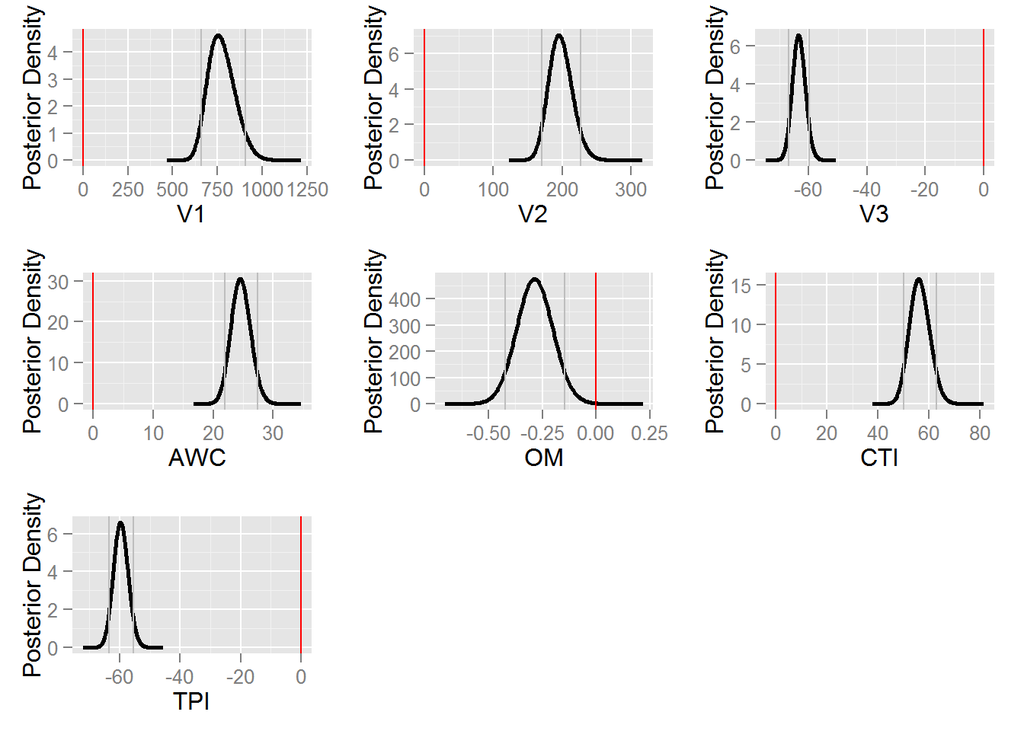

```r
results = model7
results$marginals.fixed$V1[, 1] = (exp(-results$marginals.fixed$V1[, 1]) - 1) * 100
results$marginals.fixed$V2[, 1] = (exp(-results$marginals.fixed$V2[, 1]) - 1) * 100
results$marginals.fixed$TPI[, 1] = (exp(results$marginals.fixed$TPI[, 1]) - 1) * 100
results$marginals.fixed$V3[, 1] = (exp(results$marginals.fixed$V3[, 1]) - 1) * 100
results$marginals.fixed$AWC[, 1] = (exp(results$marginals.fixed$AWC[, 1]) - 1) * 100
results$marginals.fixed$CTI[, 1] = (exp(results$marginals.fixed$CTI[, 1]) - 1) * 100
results$marginals.fixed$OM[, 1] = (exp(results$marginals.fixed$OM[, 1]) - 1) * 100

plotV1 = ggplotmargin(results, type = "fixed",
                     effect = "V1", xlab = "V1")

plotV2 = ggplotmargin(results, type = "fixed",
                      effect = "V2", xlab = "V2")

plotV3 = ggplotmargin(results, type = "fixed",
                       effect = "V3", xlab = "V3")

plotCTI = ggplotmargin(results, type = "fixed",
                       effect = "CTI", xlab = "CTI")

plotTPI = ggplotmargin(results, type = "fixed",
                       effect = "TPI", xlab = "TPI")

plotAWC = ggplotmargin(results, type = "fixed",
                       effect = "AWC", xlab = "AWC")

plotOM = ggplotmargin(results, type = "fixed",
                       effect = "OM", xlab = "OM")

grid.arrange(plotV1, plotV2, plotV3, plotAWC, plotOM, plotCTI, plotTPI, ncol=3)
```

### Figure 2b (Plot Random Effects)

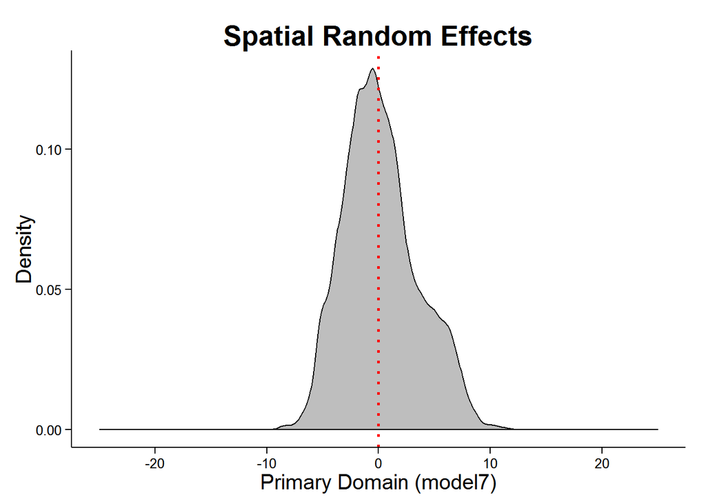

```r
RE1.r = Blank.r
Wetlands.spdf$SREm7 = model7$summary.random$Region[,2]
values(RE1.r) = exp((-model7$summary.random$Region[,2]/12) - 1) * 100


REffect = round(Wetlands.spdf$SREm7, 4)
Var = rep("RE", length(REffect))
RE.df = data.frame(Var, REffect)
RE.df$REffect = as.numeric(RE.df$REffect)

RE.d = ggplot(RE.df, aes(REffect, fill = as.factor(Var))) +
              geom_density(fill = "grey") +
              theme_classic() +
              xlim(-25, 25) +
                 xlab("Primary Domain (model7)") +
                 ylab("Density") +
                 theme(axis.title.y = element_text(size = 15),
                       axis.title.x = element_text(size = 15),
                       plot.title = element_text(size = 20, face="bold")) +
                 geom_vline(data = RE.df,
                 aes(xintercept = 0,
                     colour = Run),
                     linetype = "dotted",
                     size = 1, col = "red") +
                ggtitle("Spatial Random Effects")

RE.d
```

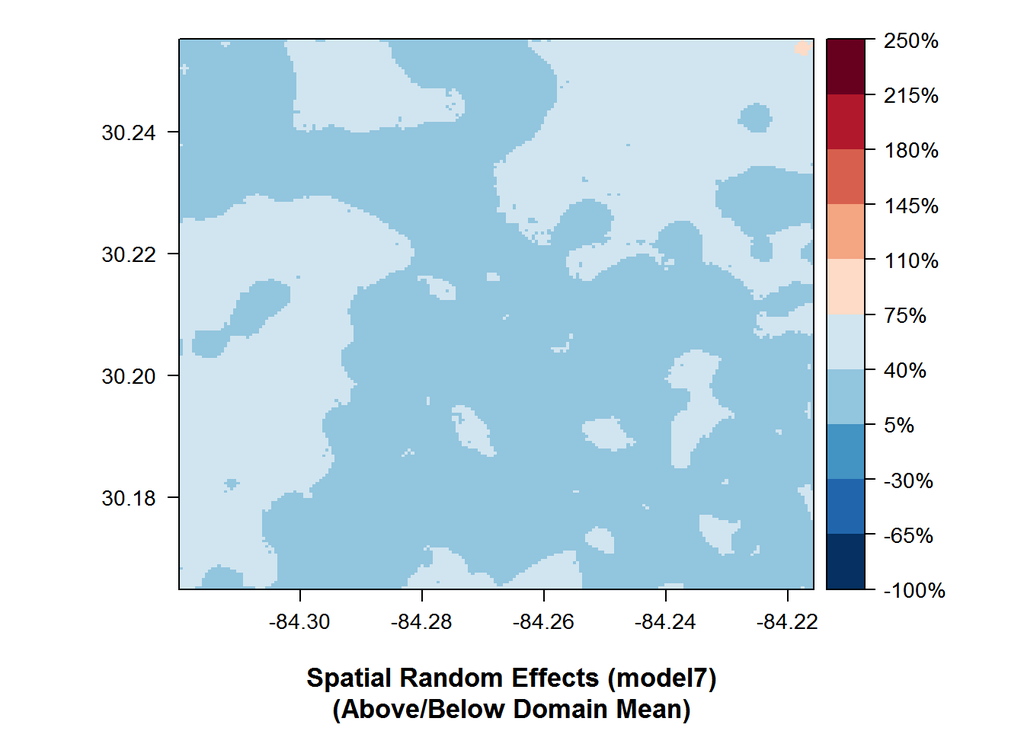

```r
rng = seq(-100, 250, 35)

rngL = paste(rng, '%', sep = "")
cr = rev(brewer.pal(10, "RdBu"))

M7RE = levelplot(RE1.r, margin = FALSE,
          sub = "                Spatial Random Effects (model7)                \n(Above/Below Domain Mean)",
          xlab = NULL, ylab = NULL,
          col.regions = cr, at = rng,
          colorkey = list(at = rng, labels = rngL, col = cr),
          par.settings = list(fontsize = list(text = 13)))

M7RE
```

### Wetland Probabilty Map

Plot the Wetland Probability Map

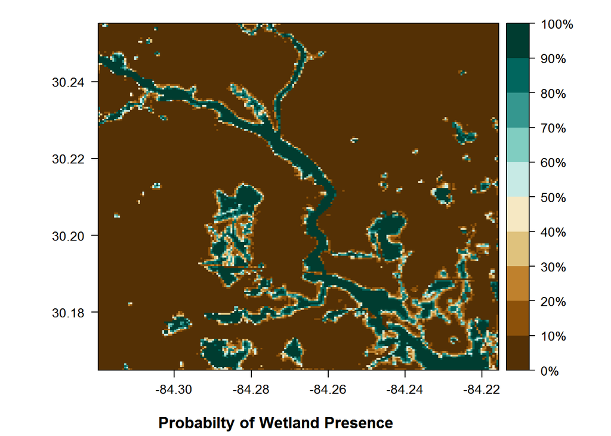

```r
M2p = Blank.r
values(M2p) = Wetlands.spdf@data$M7Prob

rng = seq(0, 1, 0.1)
rngL = paste(rng*100, '%', sep = "")
cr = brewer.pal(10, "BrBG")
M2pb = levelplot(M2p, margin = FALSE,
          sub = "Probabilty of Wetland Presence             ",
          xlab = NULL, ylab = NULL,
          col.regions = cr, at = rng,
          colorkey = list(at = rng, labels = rngL, col = cr),
          par.settings = list(fontsize = list(text = 13)))

M2pb
```

```r
rm(list=setdiff(ls(), c("FIX", "model7", "SDAquery", "D100Time", "D100cnt")))
```

# Change Resolution

The initial project domain encompassed a 100km^2 area and processed raster objects utilizing a cell edge of 50m. The sensitivity of the model to changes in resolution is explored below by first increasing the resolution to 30m and then coarsening data to a 70m cell edge length. The selected model (“model7”) is applied to both resolutions while holding the domain areal extent constant.

## 30m Cell Edge

### Domain Shapefile

```r
#Domain (shapefile)
Domain100 = readOGR(dsn = "./WetlandData/Domains/Domain100", layer = "Domain100",
                    stringsAsFactors = FALSE, p4s = "+proj=utm +zone=17 +datum=NAD83")
                    gIsValid(Domain100)
```

```
## [1] TRUE
```

```r
                    Domain100 = gBuffer(Domain100, width=0, byid=TRUE)
```

### Domain Target Cell Size (TCS)

```r
TCS = 30 #Raster cell edge length (meters)

xCOL = ceiling(10000/TCS)
yROW = ceiling(10000/TCS)
```

### Read Soil and Landuse/Landcover Shapefiles

```r
#Soils Data
    Raw_Soils.spdf = readOGR(dsn = "./WetlandData/SSURGO_NWF", layer = "SSURGO_NWF",
                     stringsAsFactors = FALSE, p4s = "+proj=utm +zone=17 +datum=NAD83")
                     Raw_Soils.spdf = crop(Raw_Soils.spdf, Domain100)
                     gIsValid(Raw_Soils.spdf) #Chk TopologY
```

```
## [1] TRUE
```

```r
                     Raw_Soils.spdf = gBuffer(Raw_Soils.spdf, width=0, byid=TRUE) #Fix Topology
    Raw_Soils.df = Raw_Soils.spdf@data


#Landcover/Landuse Data
    LCLU_NWF.spdf = readOGR(dsn = "./WetlandData/LCLU_NWF", layer = "LCLU_NWF",
                    stringsAsFactors = FALSE, p4s = "+proj=utm +zone=17 +datum=NAD83")
                    LCLU_NWF.spdf = crop(LCLU_NWF.spdf, Domain100)
                    gIsValid(LCLU_NWF.spdf)
```

```
## [1] FALSE
```

```r
    LCLU_NWF.spdf = gBuffer(LCLU_NWF.spdf, width=0, byid=TRUE)
```

### Subset Landcover Groups

```r
UP_LC.spdf = subset(LCLU_NWF.spdf,
                    LANDUSE_CO >= 2600 &
                    LANDUSE_CO <= 4430 )

Wet_LC.spdf = subset(LCLU_NWF.spdf,
                     LANDUSE_CO >= 5000 &
                     LANDUSE_CO <= 6999 )
```

### Crop soils data

```r
UP_Soils.spdf = crop(Raw_Soils.spdf, UP_LC.spdf)
UP_Soils.spdf@data = UP_Soils.spdf@data %>%
                     mutate(Designation = 0)


Wet_Soils.spdf = crop(Raw_Soils.spdf, Wet_LC.spdf)
Wet_Soils.spdf@data = Wet_Soils.spdf@data %>%
                      mutate(Designation = 1)
```

```r
UP_Soils1.spdf = spChFIDs(UP_Soils.spdf,
                          paste(as.character(
                                1:nrow(UP_Soils.spdf)),"U", sep = ""))

Wet_Soils1.spdf = spChFIDs(Wet_Soils.spdf,
                           paste(as.character(
                                1:nrow(Wet_Soils.spdf)),"W", sep = ""))

Soils.spdf = spRbind(UP_Soils1.spdf, Wet_Soils1.spdf)

Soils.spdf$IDs = 1:nrow(Soils.spdf)
```

### Combine Upland and Wetland Data Frames

```r
Soils.df = Soils.spdf@data

Soils0.df = subset(Soils.df,
                   select = -c(AREASYMBOL,  SPATIALVER, NationalMu,
                                muhelcl,  muwathelcl,  muwndhelcl,  interpfocu,
                                invesinten,  lkey,  iacornsr,  projectsca,  tabularver,
                                iccdcd,   iccdcdpct,  engstafdcd,  engstafll,  engstafml,
                                albedo_h,  albedo_l,  cropprodin,  rsprod_h,  rsprod_l,
                                rsprod_r,  slopelen_h,  slopelen_l,  cokey,  comppct_l,
                                comppct_h,  compkind,  earthcovki,  earthcov_1,  aspectccwi,
                                aspectrep,  aspectcwis,  geomdesc,  nirrcapuni,  irrcapcl,
                                irrcapscl,  irrcapunit,  constreesh,  soilslippo,  frostact,
                                soiltaxedi,  taxclname,  taxorder,  taxsuborde,  taxgrtgrou,
                                taxsubgrp,  taxparts_1, map_h,  map_l,  map_r, Shape_Leng, Shape_Area))

Soils1.df = as.data.frame(lapply
                          (Soils0.df, factor))
Soils2.df = Soils1.df %>%
            mutate(Designation = as.numeric(Soils.df$Designation),
                   IDs = as.numeric(Soils.df$IDs),
                   wtdepaprju = as.numeric(round(Soils.df$wtdepaprju),5),
                   wtdepannmi = as.numeric(round(Soils.df$wtdepannmi),5),
                   slopegradd = as.numeric(round(Soils.df$slopegradd),5),
                   slopegradw = as.numeric(round(Soils.df$slopegradw), 5),
                   aws025wta = as.numeric(round(Soils.df$aws025wta), 5),
                   aws050wta = as.numeric(round(Soils.df$aws050wta), 5),
                   aws0100wta = as.numeric(round(Soils.df$aws0100wta), 5),
                   aws0150wta = as.numeric(round(Soils.df$aws0150wta), 5),
                   niccdcdpct = as.numeric(round(Soils.df$niccdcdpct), 5),
                   albedo_r = as.numeric(round(Soils.df$albedo_r), 5),
                   elev_h = as.numeric(round(Soils.df$elev_h), 5),
                   elev_l = as.numeric(round(Soils.df$elev_l), 5),
                   elev_r = as.numeric(round(Soils.df$elev_r), 5),
                   slope_h = as.numeric(round(Soils.df$slope_h), 5),
                   slope_r = as.numeric(round(Soils.df$niccdcdpct), 5))
```

### Prior Distribution

```r
D0 = 0.33 #Prob of wetlands in Florida
D1 = 0.50 #Prop of being wetland if known to have wetland vegetation

Soils.spdf$Extent = gArea(Soils.spdf,
                          byid = TRUE)

Wet_area = as.numeric(
             Soils.spdf@data %>%
                       filter(Designation == 1) %>%
                       summarise(sum(Extent, na.rm = TRUE)))

Up_area = as.numeric(
            Soils.spdf@data %>%
                      filter(Designation == 0) %>%
                      summarise(sum(Extent, na.rm = TRUE)))

Wp = (Wet_area/(Wet_area + Up_area))
Up = (Up_area/(Wet_area + Up_area))

Pr = (Up*D0) + (Wp*D1)

q1 = list(p = .5, x = Pr)
q2 = list(p = .9, x = D1)
B.select = beta.select(q1, q2)

a = B.select[1]
b = B.select[2]

hyper.p = list(prec = list(
                        list(prior = "logitbeta",
                             param = c(a, b),
                             initial = 0)))
```

### Conduct Principal Components Analysis (PCA)

```r
Soils.PCA = Soils2.df %>%
                select(slopegradd, slopegradw, aws025wta, aws050wta, aws0100wta,
                aws0150wta, niccdcdpct, albedo_r, elev_h, elev_l, elev_r, slope_h,
                slope_r, wtdepaprju, wtdepannmi)

PCA.Result = PCA(Soils.PCA ,
                 scale.unit = TRUE,
                 ncp = 5,
                 graph = FALSE)
```

### Singular Value Decomposition (SVD) to Data Frame

```r
PCA.df = as.data.frame(PCA.Result$svd$U) %>%
                 mutate(Designation = as.numeric(Soils.df$Designation))
```

### Conduct Multiple Correspondance Analysis (MCA)

```r
Soils.MCA = Soils2.df %>%
               select(MUSYM, muname, mukind, farmlndcl, museq, brockdepmi,
                      flodfreqdc, flodfreqma, pondfreqpr, drclassdcd,
                      drclasswet, hydgrpdcd, niccdcd, engdwobdcd, engdwbdcd,  engdwbll,
                      engdwbml,   engsldcd,   engsldcp, englrsdcd,  engcmssdcd, engcmssmp,
                      urbrecptdc, urbrecptwt, forpehrtdc, hydclprs, awmmfpwwta, airtempa_h,
                      airtempa_l, airtempa_r, ffd_h, ffd_l, ffd_r, initsub_h, initsub_l,
                      initsub_r, slope_l, slopelen_r, totalsub_h, totalsub_l, totalsub_r,
                      compname, otherph, localphase, runoff, tfact, wei, weg, erocl,
                      hydricon, nirrcapcl, nirrcapscl, foragesuit, wlgrai, wlgrass, wlherbaceo,
                      wlshrub, wlconifero, wlhardwood, wlwetplant, wlshalloww, wlrangelan,
                      wlopenland, wlwoodland, wlwetland, corcon, corsteel, taxpartsiz,
                      taxceactcl, taxreactio, taxtempcl, taxmoistsc, taxtempreg)

MCA.Result = MCA(Soils.MCA,
                 ncp=5,
                 graph = FALSE)
```

### MCA Singular Value Decomposition (SVD) to .df

```r
MCA.df = as.data.frame(MCA.Result$svd$U) %>%
                 mutate(Designation = as.numeric(Soils.df$Designation))
```

### Combine Significant MCA and PCA Results

Attach the significant MCA and PCA results to Soils2.spdf.

Also added is the “MUKEY” column from the Soils.spdf that will be used to explore additional soils data later.

```r
Soils2.spdf = Soils.spdf

Soils2.spdf@data = PCA.df %>%
                   select(Designation, V1, V2, V3) %>%
                   mutate(MCA3 = MCA.df[,"V3"],
                          MUKEY = as.numeric(Soils.spdf@data[,"MUKEY"]))
```

### Convert Soils PCA and MCA Results to Raster Objects

First, create a raster template based on the resolution specified at top of the script.

```r
Blank.r = raster(nrows = yROW, ncols = xCOL)
extent(Blank.r) = extent(Soils2.spdf)
proj4string(Blank.r) = proj4string(Soils2.spdf)
```

### Create Wetland/Upland Designation Raster

```r
w_rast = rasterize(Wet_Soils.spdf,
                   Blank.r,
                   field = 1)

w_rast = reclassify(w_rast,
                    cbind(NA, 0))
```

### Create Rasters for Significatnt PCA/MCA Results

```r
V1_rast = rasterize(Soils2.spdf,
                    Blank.r,
                    field = Soils2.spdf@data$V1)

V2_rast = rasterize(Soils2.spdf,
                    Blank.r,
                    field = Soils2.spdf@data$V2)

V3_rast = rasterize(Soils2.spdf,
                    Blank.r,
                    field = Soils2.spdf@data$V3)

MCA3_rast = rasterize(Soils2.spdf,
                    Blank.r,
                    field = Soils2.spdf@data$MCA3)
```

### Convert Rasters to SpatialPolygonsDataFrame

Add PCA and MCA results

```r
Wetlands.spdf = as(w_rast, "SpatialPolygonsDataFrame")
names(Wetlands.spdf) = "Designation"

Wetlands.spdf@data = Wetlands.spdf@data %>%
                        mutate(V1 = values(V1_rast),
                               V2 = values(V2_rast),
                               V3 = values(V3_rast),
                               MCAV3 = values(MCA3_rast))
```

## AWC and OM

### Rasterize MUKEY

```r
AWC.r = rasterize(Soils2.spdf,
                      Blank.r,
                      field = Soils2.spdf@data$MUKEY)

OM.r = rasterize(Soils2.spdf,
                      Blank.r,
                      field = Soils2.spdf@data$MUKEY)
```

### Soil Functions

```r
HzWS = function(i) {
              wt = i$comppct_r[1]
              thick = with(i, hzdepb_r - hzdept_r)
              whc = thick * i$awc_r
                whc.total = sum(whc, na.rm=TRUE)
                data.frame(whc = whc.total, wt=wt)
}

HzWSO = function(i) {
              wto = i$comppct_r[1]
              thicko = with(i, hzdepb_r - hzdept_r)
              whco = thicko * i$Om_r
                whc.totalo = sum(whco, na.rm=TRUE)
                data.frame(whco = whc.totalo, wto=wto)
}
```

The next two functions find the average (weighted by component percentage) within each Soil Map Unit

```r
MU_mean = function(i) {
                  whc = wtd.mean(i$whc, weights=i$wt)
                  data.frame(whc=whc)
}

MU_meano = function(i) {
                  whco = wtd.mean(i$whco, weights=i$wto)
                  data.frame(whco=whco)
}
```

### Add Raster Attribute Table (RAT)

```r
AWC.r = ratify(AWC.r,
               count = TRUE)

OM.r = ratify(OM.r,
               count = TRUE)
```

### save RATs as Objects

```r
rat = levels(AWC.r)[[1]]

rato = levels(OM.r)[[1]]
```

### Extract MUKEYs from the RAT

```r
in.statement = format_SQL_in_statement(rat$ID)

in.statement2 = format_SQL_in_statement(rato$ID)
```

### Query SDA

```r
q = paste("SELECT component.mukey, component.cokey, compname, comppct_r, hzdept_r, hzdepb_r, hzname, Om_r, awc_r FROM component JOIN chorizon ON component.cokey = chorizon.cokey AND mukey IN ", in.statement, "ORDER BY mukey, comppct_r DESC, hzdept_r ASC", sep ="")

ACW.res = SDAquery(q)
```

```
## sending SOAP request...
## processing results...
```

```r
q2 = paste("SELECT component.mukey, component.cokey, compname, comppct_r, hzdept_r, hzdepb_r, hzname, Om_r, awc_r FROM component JOIN chorizon ON component.cokey = chorizon.cokey AND mukey IN ", in.statement2, "ORDER BY mukey, comppct_r DESC, hzdept_r ASC", sep ="")

OM.res = SDAquery(q2)
```

```
## sending SOAP request...
## processing results...
```

### Aggregate Data

```r
co.whc = ACW.res %>%
              group_by(mukey, cokey) %>%
              do(HzWS(.))

mu.whc = co.whc %>%
              group_by(mukey) %>%
              do(MU_mean(.))

co.whco = OM.res %>%
              group_by(mukey, cokey) %>%
              do(HzWSO(.))

mu.whco = co.whco %>%
              group_by(mukey) %>%
              do(MU_meano(.))
```

### Join Results to Domain Rasters

```r
names(mu.whc)[1] = 'ID'
rat.new = left_join(rat, mu.whc)
levels(AWC.r) = rat.new
AWC = deratify(AWC.r, att='whc')

names(mu.whco)[1] = 'ID'
rato.new = left_join(rato, mu.whco)
levels(OM.r) = rato.new
OM = deratify(OM.r, att='whco')
```

### Add Results to Wetlands.spdf

```r
Wetlands.spdf$AWC = values(AWC)
Wetlands.spdf$OM = values(OM)
```

### Explanatory Variables linked to Topograpy

```r
#DEM (USGS 1/3 arc-sec)
      DEM = raster("./WetlandData/DEM_NWF/dem_nwf/w001001.adf")
      DEM = reclassify(DEM,
                        cbind(0, 0.001))

      DomainB = readOGR(dsn = "./WetlandData/Domains/Domain100", layer = "Domain100",
                    stringsAsFactors = FALSE)
            DomainBp = spTransform(DomainB,
                       CRS(projection(DEM)))

      DEM = crop(DEM, DomainBp)
```

### Calculate Topographic Indicies

```r
RR = raster(nrow = yROW, ncol = xCOL)
extent(RR) = extent(DEM)

DEM2 = resample(DEM, RR,
                method='bilinear')

tpi = terrain(DEM2,
              opt = 'tpi')

TPI = reclassify(tpi,
                 cbind(NA, minValue(tpi)))

proj4string(TPI) = proj4string(LCLU_NWF.spdf)
extent(TPI) = extent(LCLU_NWF.spdf)

Wetlands.spdf$TPI = values(TPI)
```

```r
CTI0 = upslope.area(DEM,
                    log = TRUE,
                    atb = TRUE,
                    deg = 0.1)

CTI = reclassify(CTI0$atb,
                 cbind(NA, maxValue(CTI0)))

extent(CTI) = extent(LCLU_NWF.spdf)
CTI = resample(CTI, Blank.r, method = 'bilinear')

Wetlands.spdf$CTI = values(CTI)
```

# Bayesian Analysis

### Assign Region and IDs Labels

```r
Wetlands.spdf$Region = 1:nrow(Wetlands.spdf)
```

### Spatial Neighborhood as an INLA Graph

```r
nb = poly2nb(Wetlands.spdf, queen = FALSE)
nb2INLA("J", nb)
J = inla.read.graph("J")
```

### Run Selected Model

```r
D30ST = Sys.time()

formula7 = Designation ~ f(Region, model = "besag",
                           adjust.for.con.comp = FALSE,
                           scale.model = TRUE,
                           hyper = hyper.p,
                           graph = J) +
                         V1 + V2 + V3 + AWC + OM + CTI + TPI

model7_30  =  inla(formula7, family = "binomial",
                       control.family = list(link = "cloglog"),
                       control.predictor = list(compute = TRUE),
                       control.compute=list(cpo = TRUE, waic=TRUE),
                       data = Wetlands.spdf@data)

summary(model7_30)
```

```
##
## Call:
## c("inla(formula = formula7, family = \"binomial\", data = Wetlands.spdf@data, ",  "    control.compute = list(cpo = TRUE, waic = TRUE), control.predictor = list(compute = TRUE), ",  "    control.family = list(link = \"cloglog\"))")
##
## Time used:
##  Pre-processing    Running inla Post-processing           Total
##          2.6809      10139.8988          9.5096      10152.0893
##
## Fixed effects:
##                 mean     sd 0.025quant 0.5quant 0.975quant     mode kld
## (Intercept) -17.5771 0.4082   -18.3196 -17.5693   -16.7404 -17.4370   0
## V1           -2.7564 0.0738    -2.9011  -2.7564    -2.6119  -2.7561   0
## V2           -1.4040 0.0539    -1.5111  -1.4035    -1.2996  -1.4026   0
## V3           -1.2092 0.0559    -1.3195  -1.2091    -1.0999  -1.2088   0
## AWC           0.3208 0.0120     0.2974   0.3207     0.3443   0.3206   0
## OM           -0.0046 0.0008    -0.0061  -0.0046    -0.0030  -0.0046   0
## CTI           0.4137 0.0166     0.3812   0.4137     0.4464   0.4136   0
## TPI          -0.9762 0.0581    -1.0907  -0.9760    -0.8627  -0.9757   0
##
## Random effects:
## Name   Model
##  Region   Besags ICAR model
##
## Model hyperparameters:
##                        mean     sd 0.025quant 0.5quant 0.975quant   mode
## Precision for Region 0.0838 0.0031      0.078   0.0838     0.0901 0.0836
##
## Expected number of effective parameters(std dev): 8722.50(45.48)
## Number of equivalent replicates : 12.79
##
## Watanabe-Akaike information criterion (WAIC) ...: 7140.29
## Effective number of parameters .................: 655.67
##
## Marginal log-Likelihood:  -86686.79
## CPO and PIT are computed
##
## Posterior marginals for linear predictor and fitted values computed
```

```r
#Exponentiate
FIX(model7_30)
```

```
##             expMean exp0.025 exp0.975
## (Intercept) -100.00  -100.00  -100.00
## V1           -93.65   -94.50   -92.66
## V2           -75.44   -77.93   -72.74
## V3           -70.16   -73.27   -66.71
## AWC           37.82    34.63    41.10
## OM            -0.46    -0.61    -0.30
## CTI           51.24    46.40    56.27
## TPI          -62.33   -66.40   -57.80
```

```r
Wetlands.spdf@data = Wetlands.spdf@data %>%
                        mutate(M730SLPM = model7_30$summary.linear.predictor[,"mean"],
                               M730Prob = exp(M730SLPM)/(1+exp(M730SLPM)))

D30ET = Sys.time()
D30Time = as.numeric(D30ET - D30ST, units = "mins")
D30cnt = length(Wetlands.spdf@data$Designation)
```

### Wetland Probabilty Map

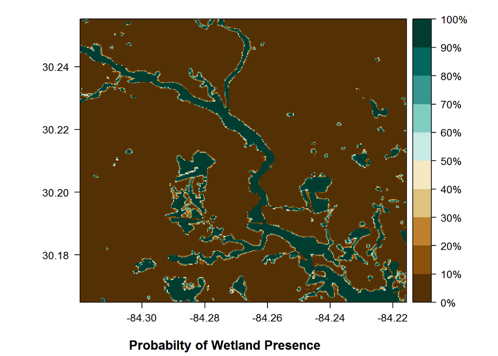

```r
M2p = Blank.r
values(M2p) = Wetlands.spdf@data$M730Prob

rng = seq(0, 1, 0.10)
rngL = paste(rng*100, '%', sep = "")
cr = brewer.pal(10, "BrBG")
M2pb = levelplot(M2p, margin = FALSE,
          sub = "Probabilty of Wetland Presence             ",
          xlab = NULL, ylab = NULL,
          col.regions = cr, at = rng,
          colorkey = list(at = rng, labels = rngL, col = cr),
          par.settings = list(fontsize = list(text = 13)))

M2pb
```

```r
rm(list=setdiff(ls(), c("FIX", "model7", "model7_30", "Domain100", "Soils2.spdf", "Wet_Soils.spdf",
                        "hyper.p", "SDAquery", "D30Time", "D100Time", "D30cnt", "D100cnt")))
```

# 70m Cell Edge

### Domain Target Cell Size (TCS)

```r
TCS = 70 #Raster cell edge length (meters)

xCOL = ceiling(10000/TCS)
yROW = ceiling(10000/TCS)
```

### Convert Soils PCA and MCA Results to Raster Objects

First, create a raster template based on the resolution specified at top of the script.

```r
Blank.r = raster(nrows = yROW, ncols = xCOL)
extent(Blank.r) = extent(Soils2.spdf)
proj4string(Blank.r) = proj4string(Soils2.spdf)
```

### Create Wetland/Upland Designation Raster

```r
w_rast = rasterize(Wet_Soils.spdf,
                   Blank.r,
                   field = 1)

w_rast = reclassify(w_rast,
                    cbind(NA, 0))
```

### Create Rasters for Significatnt PCA/MCA Results

```r
V1_rast = rasterize(Soils2.spdf,
                    Blank.r,
                    field = Soils2.spdf@data$V1)

V2_rast = rasterize(Soils2.spdf,
                    Blank.r,
                    field = Soils2.spdf@data$V2)

V3_rast = rasterize(Soils2.spdf,
                    Blank.r,
                    field = Soils2.spdf@data$V3)

MCA3_rast = rasterize(Soils2.spdf,
                    Blank.r,
                    field = Soils2.spdf@data$MCA3)
```

### Convert Rasters to SpatialPolygonsDataFrame

```r
Wetlands.spdf = as(w_rast, "SpatialPolygonsDataFrame")
names(Wetlands.spdf) = "Designation"

Wetlands.spdf@data = Wetlands.spdf@data %>%
                        mutate(V1 = values(V1_rast),
                               V2 = values(V2_rast),
                               V3 = values(V3_rast),
                               MCAV3 = values(MCA3_rast))
```

### Rasterize MUKEY

```r
AWC.r = rasterize(Soils2.spdf,
                      Blank.r,
                      field = Soils2.spdf@data$MUKEY)

OM.r = rasterize(Soils2.spdf,
                      Blank.r,
                      field = Soils2.spdf@data$MUKEY)
```

### Soil Functions

```r
HzWS = function(i) {
              wt = i$comppct_r[1]
              thick = with(i, hzdepb_r - hzdept_r)
              whc = thick * i$awc_r
                whc.total = sum(whc, na.rm=TRUE)
                data.frame(whc = whc.total, wt=wt)
}

HzWSO = function(i) {
              wto = i$comppct_r[1]
              thicko = with(i, hzdepb_r - hzdept_r)
              whco = thicko * i$Om_r
                whc.totalo = sum(whco, na.rm=TRUE)
                data.frame(whco = whc.totalo, wto=wto)
}
```

The next two functions find the average (weighted by component percentage) within each Soil Map Unit

```r
MU_mean = function(i) {
                  whc = wtd.mean(i$whc, weights=i$wt)
                  data.frame(whc=whc)
}

MU_meano = function(i) {
                  whco = wtd.mean(i$whco, weights=i$wto)
                  data.frame(whco=whco)
}
```

### Add Raster Attribute Table (RAT)

```r
AWC.r = ratify(AWC.r,
               count = TRUE)

OM.r = ratify(OM.r,
               count = TRUE)
```

### save RATs as Objects

```r
rat = levels(AWC.r)[[1]]

rato = levels(OM.r)[[1]]
```

### Extract MUKEYs from the RAT

```r
in.statement = format_SQL_in_statement(rat$ID)

in.statement2 = format_SQL_in_statement(rato$ID)
```

### Query SDA

```r
q = paste("SELECT component.mukey, component.cokey, compname, comppct_r, hzdept_r, hzdepb_r, hzname, Om_r, awc_r FROM component JOIN chorizon ON component.cokey = chorizon.cokey AND mukey IN ", in.statement, "ORDER BY mukey, comppct_r DESC, hzdept_r ASC", sep ="")

ACW.res = SDAquery(q)
```

```
## sending SOAP request...
## processing results...
```

```r
q2 = paste("SELECT component.mukey, component.cokey, compname, comppct_r, hzdept_r, hzdepb_r, hzname, Om_r, awc_r FROM component JOIN chorizon ON component.cokey = chorizon.cokey AND mukey IN ", in.statement2, "ORDER BY mukey, comppct_r DESC, hzdept_r ASC", sep ="")

OM.res = SDAquery(q2)
```

```
## sending SOAP request...
## processing results...
```

### Aggregate Data

```r
co.whc = ACW.res %>%
              group_by(mukey, cokey) %>%
              do(HzWS(.))

mu.whc = co.whc %>%
              group_by(mukey) %>%
              do(MU_mean(.))

co.whco = OM.res %>%
              group_by(mukey, cokey) %>%
              do(HzWSO(.))

mu.whco = co.whco %>%
              group_by(mukey) %>%
              do(MU_meano(.))
```

### Join Results to Domain Rasters

```r
names(mu.whc)[1] = 'ID'
rat.new = left_join(rat, mu.whc)
levels(AWC.r) = rat.new
AWC = deratify(AWC.r, att='whc')

names(mu.whco)[1] = 'ID'
rato.new = left_join(rato, mu.whco)
levels(OM.r) = rato.new
OM = deratify(OM.r, att='whco')
```

### Add Results to Wetlands.spdf

```r
Wetlands.spdf$AWC = values(AWC)
Wetlands.spdf$OM = values(OM)
```

### Explanatory Variables linked to Topograpy

```r
#DEM (USGS 1/3 arc-sec)
      DEM = raster("./WetlandData/DEM_NWF/dem_nwf/w001001.adf")
      DEM = reclassify(DEM,
                        cbind(0, 0.001))

       DomainB = readOGR(dsn = "./WetlandData/Domains/Domain100", layer = "Domain100",
                    stringsAsFactors = FALSE)
                 DomainBp = spTransform(DomainB,
                       CRS(projection(DEM)))

      DEM = crop(DEM, DomainBp)
```

### Calculate Topographic Indicies

```r
RR = raster(nrow = yROW, ncol = xCOL)
extent(RR) = extent(DEM)

DEM2 = resample(DEM, RR,
                method='bilinear')

tpi = terrain(DEM2,
              opt = 'tpi')

TPI = reclassify(tpi,
                 cbind(NA, minValue(tpi)))

proj4string(TPI) = proj4string(Soils2.spdf)
extent(TPI) = extent(Soils2.spdf)

Wetlands.spdf$TPI = values(TPI)
```

```r
CTI0 = upslope.area(DEM,
                    log = TRUE,
                    atb = TRUE,
                    deg = 0.1)

CTI = reclassify(CTI0$atb,
                 cbind(NA, maxValue(CTI0)))

extent(CTI) = extent(Soils2.spdf)
CTI = resample(CTI, Blank.r, method = 'bilinear')

Wetlands.spdf$CTI = values(CTI)
```

# Bayesian Analysis

### Assign Region and IDs Labels

```r
Wetlands.spdf$Region = 1:nrow(Wetlands.spdf)
```

### Spatial Neighborhood as an INLA Graph

```r
nb = poly2nb(Wetlands.spdf, queen = FALSE)
nb2INLA("J", nb)
J = inla.read.graph("J")
```

### Run Selected Model

```r
D70ST = Sys.time()

formula7 = Designation ~ f(Region, model = "besag",
                           adjust.for.con.comp = FALSE,
                           scale.model = TRUE,
                           hyper = hyper.p,
                           graph = J) +
                         V1 + V2 + V3 + AWC + OM + CTI + TPI

model7_70  =  inla(formula7, family = "binomial",
                       control.family = list(link = "cloglog"),
                       control.predictor = list(compute = TRUE),
                       control.compute=list(cpo = TRUE, waic=TRUE),
                       data = Wetlands.spdf@data)

summary(model7_70)
```

```
##
## Call:
## c("inla(formula = formula7, family = \"binomial\", data = Wetlands.spdf@data, ",  "    control.compute = list(cpo = TRUE, waic = TRUE), control.predictor = list(compute = TRUE), ",  "    control.family = list(link = \"cloglog\"))")
##
## Time used:
##  Pre-processing    Running inla Post-processing           Total
##          0.6536        302.6340          1.3638        304.6513
##
## Fixed effects:
##                 mean     sd 0.025quant 0.5quant 0.975quant     mode kld
## (Intercept) -10.6865 0.5226   -11.7150 -10.6770    -9.7081 -10.6554   0
## V1           -1.8326 0.0879    -2.0075  -1.8312    -1.6649  -1.8280   0
## V2           -0.9931 0.0603    -1.1143  -0.9920    -0.8779  -0.9896   0
## V3           -0.9174 0.0657    -1.0480  -0.9168    -0.7901  -0.9155   0
## AWC           0.1805 0.0134     0.1545   0.1803     0.2072   0.1800   0
## OM           -0.0030 0.0009    -0.0047  -0.0030    -0.0012  -0.0030   0
## CTI           0.4356 0.0316     0.3749   0.4352     0.4986   0.4343   0
## TPI          -1.1423 0.0757    -1.2931  -1.1413    -0.9967  -1.1392   0
##
## Random effects:
## Name   Model
##  Region   Besags ICAR model
##
## Model hyperparameters:
##                        mean     sd 0.025quant 0.5quant 0.975quant   mode
## Precision for Region 0.1835 0.0143     0.1572   0.1828     0.2133 0.1815
##
## Expected number of effective parameters(std dev): 2063.41(41.25)
## Number of equivalent replicates : 9.91
##
## Watanabe-Akaike information criterion (WAIC) ...: 3057.05
## Effective number of parameters .................: 297.10
##
## Marginal log-Likelihood:  -15789.39
## CPO and PIT are computed
##
## Posterior marginals for linear predictor and fitted values computed
```

```r
#Exponentiate
FIX(model7_70)
```

```
##             expMean exp0.025 exp0.975
## (Intercept) -100.00  -100.00   -99.99
## V1           -84.00   -86.57   -81.08
## V2           -62.96   -67.19   -58.44
## V3           -60.04   -64.94   -54.62
## AWC           19.78    16.71    23.03
## OM            -0.30    -0.47    -0.12
## CTI           54.59    45.48    64.65
## TPI          -68.09   -72.56   -63.09
```

```r
Wetlands.spdf@data = Wetlands.spdf@data %>%
                        mutate(M770SLPM = model7_70$summary.linear.predictor[,"mean"],
                               M770Prob = exp(M770SLPM)/(1+exp(M770SLPM)))

D70ET = Sys.time()
D70Time = as.numeric(D70ET - D70ST, units = "mins")
D70cnt = length(Wetlands.spdf@data$Designation)
```

### Wetland Probabilty Map

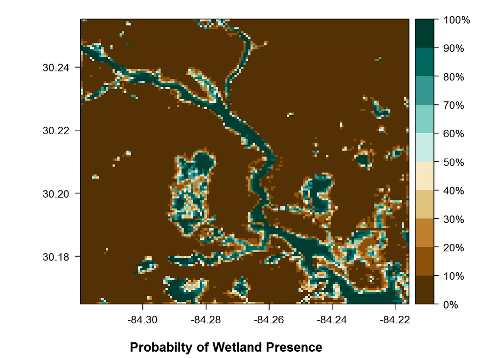

```r
M2p = Blank.r
values(M2p) = Wetlands.spdf@data$M770Prob

rng = seq(0, 1, 0.10)
rngL = paste(rng*100, '%', sep = "")
cr = brewer.pal(10, "BrBG")
M2pb = levelplot(M2p, margin = FALSE,
          sub = "Probabilty of Wetland Presence             ",
          xlab = NULL, ylab = NULL,
          col.regions = cr, at = rng,
          colorkey = list(at = rng, labels = rngL, col = cr),
          par.settings = list(fontsize = list(text = 13)))

M2pb
```

```r
rm(list=setdiff(ls(), c("model7", "model7_30", "model7_70", "SDAquery", "D100Time", "D100cnt",
                        "D30cnt", "D30Time", "D70Time", "D70cnt", "FIX")))
```

# Change Domain Extent

The initial project domain encompassed a 100km^2 area. The sensitivity of the model to changes in areal extent is explored below by first increasing the domain to 200km^2 and then to 300km^2. The selected model (“model7”) is applied to both domains holding resolution constant for both with a cell edge of 50m.

### Read Domain200

```r
#Domain (shapefile)
Domain200 = readOGR(dsn = "./WetlandData/Domains/Domain200", layer = "Domain200",
                    stringsAsFactors = FALSE, p4s = "+proj=utm +zone=17 +datum=NAD83")
                    gIsValid(Domain200)
```

```
## [1] TRUE
```

```r
                    Domain200 = gBuffer(Domain200, width=0, byid=TRUE)
```

### Domain Target Cell Size (TCS)

```r
TCS = 50 #Raster cell edge length (meters)

xCOL = ceiling(14142/TCS)
yROW = ceiling(14144/TCS)
```

### Read Soil and Landuse/Landcover Shapefiles

```r
#Soils Data
    Raw_Soils.spdf = readOGR(dsn = "./WetlandData/SSURGO_NWF", layer = "SSURGO_NWF",
                     stringsAsFactors = FALSE, p4s = "+proj=utm +zone=17 +datum=NAD83")
                     Raw_Soils.spdf = crop(Raw_Soils.spdf, Domain200)
                     gIsValid(Raw_Soils.spdf) #Chk TopologY
```

```
## [1] TRUE
```

```r
                     Raw_Soils.spdf = gBuffer(Raw_Soils.spdf, width=0, byid=TRUE) #Fix Topology

#Landcover/Landuse Data
    LCLU_NWF.spdf = readOGR(dsn = "./WetlandData/LCLU_NWF", layer = "LCLU_NWF",
                    stringsAsFactors = FALSE, p4s = "+proj=utm +zone=17 +datum=NAD83")
                    LCLU_NWF.spdf = crop(LCLU_NWF.spdf, Domain200)
                    gIsValid(LCLU_NWF.spdf)
```

```
## [1] FALSE
```

```r
                    LCLU_NWF.spdf = gBuffer(LCLU_NWF.spdf, width=0, byid=TRUE)
```

### Subset Landcover Groups

```r
UP_LC.spdf = subset(LCLU_NWF.spdf,
                    LANDUSE_CO >= 2600 &
                    LANDUSE_CO <= 4430 )

Wet_LC.spdf = subset(LCLU_NWF.spdf,
                     LANDUSE_CO >= 5000 &
                     LANDUSE_CO <= 6999 )
```

### Crop soils data

```r
UP_Soils.spdf = crop(Raw_Soils.spdf, UP_LC.spdf)
UP_Soils.spdf@data = UP_Soils.spdf@data %>%
                     mutate(Designation = 0)


Wet_Soils.spdf = crop(Raw_Soils.spdf, Wet_LC.spdf)
Wet_Soils.spdf@data = Wet_Soils.spdf@data %>%
                      mutate(Designation = 1)
```

```r
UP_Soils1.spdf = spChFIDs(UP_Soils.spdf,
                          paste(as.character(
                                1:nrow(UP_Soils.spdf)),"U", sep = ""))

Wet_Soils1.spdf = spChFIDs(Wet_Soils.spdf,
                           paste(as.character(
                                1:nrow(Wet_Soils.spdf)),"W", sep = ""))

Soils.spdf = spRbind(UP_Soils1.spdf, Wet_Soils1.spdf)

Soils.spdf$IDs = 1:nrow(Soils.spdf)
```

### Combine Upland and Wetland Data Frames

```r
Soils.df = Soils.spdf@data

Soils0.df = subset(Soils.df,
                   select = -c(AREASYMBOL,  SPATIALVER, NationalMu,
                                muhelcl,  muwathelcl,  muwndhelcl,  interpfocu,
                                invesinten,  lkey,  iacornsr,  projectsca,  tabularver,
                                iccdcd,   iccdcdpct,  engstafdcd,  engstafll,  engstafml,
                                albedo_h,  albedo_l,  cropprodin,  rsprod_h,  rsprod_l,
                                rsprod_r,  slopelen_h,  slopelen_l,  cokey,  comppct_l,
                                comppct_h,  compkind,  earthcovki,  earthcov_1,  aspectccwi,
                                aspectrep,  aspectcwis,  geomdesc,  nirrcapuni,  irrcapcl,
                                irrcapscl,  irrcapunit,  constreesh,  soilslippo,  frostact,
                                soiltaxedi,  taxclname,  taxorder,  taxsuborde,  taxgrtgrou,
                                taxsubgrp,  taxparts_1, map_h,  map_l,  map_r, Shape_Leng, Shape_Area))

Soils1.df = as.data.frame(lapply
                          (Soils0.df, factor))
Soils2.df = Soils1.df %>%
            mutate(Designation = as.numeric(Soils.df$Designation),
                   IDs = as.numeric(Soils.df$IDs),
                   wtdepaprju = as.numeric(round(Soils.df$wtdepaprju),5),
                   wtdepannmi = as.numeric(round(Soils.df$wtdepannmi),5),
                   slopegradd = as.numeric(round(Soils.df$slopegradd),5),
                   slopegradw = as.numeric(round(Soils.df$slopegradw), 5),
                   aws025wta = as.numeric(round(Soils.df$aws025wta), 5),
                   aws050wta = as.numeric(round(Soils.df$aws050wta), 5),
                   aws0100wta = as.numeric(round(Soils.df$aws0100wta), 5),
                   aws0150wta = as.numeric(round(Soils.df$aws0150wta), 5),
                   niccdcdpct = as.numeric(round(Soils.df$niccdcdpct), 5),
                   albedo_r = as.numeric(round(Soils.df$albedo_r), 5),
                   elev_h = as.numeric(round(Soils.df$elev_h), 5),
                   elev_l = as.numeric(round(Soils.df$elev_l), 5),
                   elev_r = as.numeric(round(Soils.df$elev_r), 5),
                   slope_h = as.numeric(round(Soils.df$slope_h), 5),
                   slope_r = as.numeric(round(Soils.df$niccdcdpct), 5))
```

### Prior Distribution

```r
D0 = 0.33 #Prob of wetlands in Florida
D1 = 0.50 #Prop of being wetland if known to have wetland vegetation

Soils.spdf$Extent = gArea(Soils.spdf,
                          byid = TRUE)

Wet_area = as.numeric(
             Soils.spdf@data %>%
                       filter(Designation == 1) %>%
                       summarise(sum(Extent, na.rm = TRUE)))

Up_area = as.numeric(
            Soils.spdf@data %>%
                      filter(Designation == 0) %>%
                      summarise(sum(Extent, na.rm = TRUE)))

Wp = (Wet_area/(Wet_area + Up_area))
Up = (Up_area/(Wet_area + Up_area))

Pr = (Up*D0) + (Wp*D1)

q1 = list(p = .5, x = Pr)
q2 = list(p = .9, x = D1)
B.select = beta.select(q1, q2)

a = B.select[1]
b = B.select[2]

hyper.p = list(prec = list(
                        list(prior = "logitbeta",
                             param = c(a, b),
                             initial = 0)))
```

### Conduct Principal Components Analysis (PCA)

```r
Soils.PCA = Soils2.df %>%
                select(slopegradd, slopegradw, aws025wta, aws050wta, aws0100wta,
                aws0150wta, niccdcdpct, albedo_r, elev_h, elev_l, elev_r, slope_h,
                slope_r, wtdepaprju, wtdepannmi)

PCA.Result = PCA(Soils.PCA ,
                 scale.unit = TRUE,
                 ncp = 5,
                 graph = FALSE)
```

### Singular Value Decomposition (SVD) to Data Frame

```r
PCA.df = as.data.frame(PCA.Result$svd$U) %>%
                 mutate(Designation = as.numeric(Soils.df$Designation))
```

### Conduct Multiple Correspondance Analysis (MCA)

```r
Soils.MCA = Soils2.df %>%
               select(MUSYM, muname, mukind, farmlndcl, museq, brockdepmi,
                      flodfreqdc, flodfreqma, pondfreqpr, drclassdcd,
                      drclasswet, hydgrpdcd, niccdcd, engdwobdcd, engdwbdcd,  engdwbll,
                      engdwbml,   engsldcd,   engsldcp, englrsdcd,  engcmssdcd, engcmssmp,
                      urbrecptdc, urbrecptwt, forpehrtdc, hydclprs, awmmfpwwta, airtempa_h,
                      airtempa_l, airtempa_r, ffd_h, ffd_l, ffd_r, initsub_h, initsub_l,
                      initsub_r, slope_l, slopelen_r, totalsub_h, totalsub_l, totalsub_r,
                      compname, otherph, localphase, runoff, tfact, wei, weg, erocl,
                      hydricon, nirrcapcl, nirrcapscl, foragesuit, wlgrai, wlgrass, wlherbaceo,
                      wlshrub, wlconifero, wlhardwood, wlwetplant, wlshalloww, wlrangelan,
                      wlopenland, wlwoodland, wlwetland, corcon, corsteel, taxpartsiz,
                      taxceactcl, taxreactio, taxtempcl, taxmoistsc, taxtempreg)

MCA.Result = MCA(Soils.MCA,
                 ncp=5,
                 graph = FALSE)
```

### MCA Singular Value Decomposition (SVD) to .df

```r
MCA.df = as.data.frame(MCA.Result$svd$U) %>%
                 mutate(Designation = as.numeric(Soils.df$Designation))
```

### Combine Significant MCA and PCA Results

```r
Soils2.spdf = Soils.spdf

Soils2.spdf@data = PCA.df %>%
                   select(Designation, V1, V2, V3) %>%
                   mutate(MCA3 = MCA.df[,"V3"],
                          MUKEY = as.numeric(Soils.spdf@data[,"MUKEY"]))
```

### Convert Soils PCA and MCA Results to Raster Objects

```r
Blank.r = raster(nrows = yROW, ncols = xCOL)
extent(Blank.r) = extent(Raw_Soils.spdf)
proj4string(Blank.r) = proj4string(Raw_Soils.spdf)
```

### Create Wetland/Upland Designation Raster

```r
w_rast = rasterize(Wet_Soils.spdf,
                   Blank.r,
                   field = 1)

w_rast = reclassify(w_rast,
                    cbind(NA, 0))
```

### Create Rasters for Significatnt PCA/MCA Results

```r
V1_rast = rasterize(Soils2.spdf,
                    Blank.r,
                    field = Soils2.spdf@data$V1)

V2_rast = rasterize(Soils2.spdf,
                    Blank.r,
                    field = Soils2.spdf@data$V2)

V3_rast = rasterize(Soils2.spdf,
                    Blank.r,
                    field = Soils2.spdf@data$V3)

MCA3_rast = rasterize(Soils2.spdf,
                    Blank.r,
                    field = Soils2.spdf@data$MCA3)
```

### Convert Rasters to SpatialPolygonsDataFrame

```r
Wetlands.spdf = as(w_rast, "SpatialPolygonsDataFrame")
names(Wetlands.spdf) = "Designation"

Wetlands.spdf@data = Wetlands.spdf@data %>%
                        mutate(V1 = values(V1_rast),
                               V2 = values(V2_rast),
                               V3 = values(V3_rast),
                               MCAV3 = values(MCA3_rast))
```

## Soil Available Water Capacity (AWC) and Organic Mass (OM)

### Rasterize MUKEY

```r
AWC.r = rasterize(Soils2.spdf,
                      Blank.r,
                      field = Soils2.spdf@data$MUKEY)

OM.r = rasterize(Soils2.spdf,
                      Blank.r,
                      field = Soils2.spdf@data$MUKEY)
```

### Soil Functions

```r
HzWS = function(i) {
              wt = i$comppct_r[1]
              thick = with(i, hzdepb_r - hzdept_r)
              whc = thick * i$awc_r
                whc.total = sum(whc, na.rm=TRUE)
                data.frame(whc = whc.total, wt=wt)
}

HzWSO = function(i) {
              wto = i$comppct_r[1]
              thicko = with(i, hzdepb_r - hzdept_r)
              whco = thicko * i$Om_r
                whc.totalo = sum(whco, na.rm=TRUE)
                data.frame(whco = whc.totalo, wto=wto)
}
```

The next two functions find the average (weighted by component percentage) within each Soil Map Unit

```r
MU_mean = function(i) {
                  whc = wtd.mean(i$whc, weights=i$wt)
                  data.frame(whc=whc)
}

MU_meano = function(i) {
                  whco = wtd.mean(i$whco, weights=i$wto)
                  data.frame(whco=whco)
}
```

### Add Raster Attribute Table (RAT)

```r
AWC.r = ratify(AWC.r,
               count = TRUE)

OM.r = ratify(OM.r,
               count = TRUE)
```

### save RATs as Objects

```r
rat = levels(AWC.r)[[1]]

rato = levels(OM.r)[[1]]
```

### Extract MUKEYs from the RAT

```r
in.statement = format_SQL_in_statement(rat$ID)

in.statement2 = format_SQL_in_statement(rato$ID)
```

### Query SDA

```r
q = paste("SELECT component.mukey, component.cokey, compname, comppct_r, hzdept_r, hzdepb_r, hzname, Om_r, awc_r FROM component JOIN chorizon ON component.cokey = chorizon.cokey AND mukey IN ", in.statement, "ORDER BY mukey, comppct_r DESC, hzdept_r ASC", sep ="")

ACW.res = SDAquery(q)
```

```
## sending SOAP request...
## processing results...
```

```r
q2 = paste("SELECT component.mukey, component.cokey, compname, comppct_r, hzdept_r, hzdepb_r, hzname, Om_r, awc_r FROM component JOIN chorizon ON component.cokey = chorizon.cokey AND mukey IN ", in.statement2, "ORDER BY mukey, comppct_r DESC, hzdept_r ASC", sep ="")

OM.res = SDAquery(q2)
```

```
## sending SOAP request...
## processing results...
```

### Aggregate Data

```r
co.whc = ACW.res %>%
              group_by(mukey, cokey) %>%
              do(HzWS(.))

mu.whc = co.whc %>%
              group_by(mukey) %>%
              do(MU_mean(.))

co.whco = OM.res %>%
              group_by(mukey, cokey) %>%
              do(HzWSO(.))

mu.whco = co.whco %>%
              group_by(mukey) %>%
              do(MU_meano(.))
```

### Join Results to Domain Rasters

```r
names(mu.whc)[1] = 'ID'
rat.new = left_join(rat, mu.whc)
levels(AWC.r) = rat.new
AWC = deratify(AWC.r, att='whc')

names(mu.whco)[1] = 'ID'
rato.new = left_join(rato, mu.whco)
levels(OM.r) = rato.new
OM = deratify(OM.r, att='whco')
```

### Add Results to Wetlands.spdf

```r
Wetlands.spdf$AWC = values(AWC)
Wetlands.spdf$OM = values(OM)
```

### Explanatory Variables linked to Topograpy

```r
#DEM (USGS 1/3 arc-sec)
      DEM = raster("./WetlandData/DEM_NWF/dem_nwf/w001001.adf")
      DEM = reclassify(DEM,
                        cbind(0, 0.001))

      DomainB = readOGR(dsn = "./WetlandData/Domains/Domain200", layer = "Domain200",
                    stringsAsFactors = FALSE)
      DomainBp = spTransform(DomainB,
                       CRS(projection(DEM)))

      DEM = crop(DEM, DomainBp)
```

### Calculate Topographic Indicies

```r
RR = raster(nrow = yROW, ncol = xCOL)
extent(RR) = extent(DEM)

DEM2 = resample(DEM, RR,
                method='bilinear')

tpi = terrain(DEM2,
              opt = 'tpi')

TPI = reclassify(tpi,
                 cbind(NA, minValue(tpi)))

proj4string(TPI) = proj4string(LCLU_NWF.spdf)
extent(TPI) = extent(LCLU_NWF.spdf)

Wetlands.spdf$TPI = values(TPI)
```

```r
CTI0 = upslope.area(DEM,
                    log = TRUE,
                    atb = TRUE,
                    deg = 0.1)

CTI = reclassify(CTI0$atb,
                 cbind(NA, maxValue(CTI0)))

extent(CTI) = extent(LCLU_NWF.spdf)
CTI = resample(CTI, Blank.r, method = 'bilinear')

Wetlands.spdf$CTI = values(CTI)
```

## Bayesian Analysis

### Assign Region and IDs Labels

```r
Wetlands.spdf$Region = 1:nrow(Wetlands.spdf)
```

### Spatial Neighborhood as an INLA Graph

```r
nb = poly2nb(Wetlands.spdf, queen = FALSE)
nb2INLA("J", nb)
J = inla.read.graph("J")
```

### Run Previously Fitted Model

```r
D200ST = Sys.time()

formula7 = Designation ~ f(Region, model = "besag",
                           adjust.for.con.comp = FALSE,
                           scale.model = TRUE,
                           hyper = hyper.p,
                           graph = J) +
                         V1 + V2 + V3 + AWC + OM + CTI + TPI

model7_200  =  inla(formula7, family = "binomial",
                       control.family = list(link = "cloglog"),
                       control.predictor = list(compute = TRUE),
                       control.compute=list(cpo = TRUE, waic=TRUE),
                       data = Wetlands.spdf@data)

summary(model7_200)
```

```
##
## Call:
## c("inla(formula = formula7, family = \"binomial\", data = Wetlands.spdf@data, ",  "    control.compute = list(cpo = TRUE, waic = TRUE), control.predictor = list(compute = TRUE), ",  "    control.family = list(link = \"cloglog\"))")
##
## Time used:
##  Pre-processing    Running inla Post-processing           Total
##          2.1195       4959.4382          7.6222       4969.1800
##
## Fixed effects:
##                 mean     sd 0.025quant 0.5quant 0.975quant     mode kld
## (Intercept) -11.5937 0.2511   -12.0640 -11.6063   -11.0411 -11.6209   0
## V1           -2.1113 0.0513    -2.2107  -2.1119    -2.0086  -2.1132   0
## V2           -1.3171 0.0407    -1.3970  -1.3171    -1.2372  -1.3171   0
## V3            0.5135 0.0383     0.4384   0.5135     0.5886   0.5135   0
## AWC           0.2467 0.0079     0.2311   0.2467     0.2622   0.2468   0
## OM           -0.0007 0.0004    -0.0014  -0.0007     0.0000  -0.0007   0
## CTI           0.3094 0.0152     0.2795   0.3094     0.3392   0.3094   0
## TPI          -0.7975 0.0385    -0.8729  -0.7975    -0.7218  -0.7976   0
##
## Random effects:
## Name   Model
##  Region   Besags ICAR model
##
## Model hyperparameters:
##                        mean     sd 0.025quant 0.5quant 0.975quant   mode
## Precision for Region 0.1332 0.0057     0.1233   0.1327     0.1457 0.1314
##
## Expected number of effective parameters(std dev): 7658.75(44.15)
## Number of equivalent replicates : 10.46
##
## Watanabe-Akaike information criterion (WAIC) ...: 8813.39
## Effective number of parameters .................: 812.64
##
## Marginal log-Likelihood:  -64079.95
## CPO and PIT are computed
##
## Posterior marginals for linear predictor and fitted values computed
```

```r
#Exponentiate
FIX(model7_200)
```

```
##             expMean exp0.025 exp0.975
## (Intercept) -100.00  -100.00  -100.00
## V1           -87.89   -89.04   -86.58
## V2           -73.21   -75.27   -70.98
## V3            67.11    55.02    80.14
## AWC           27.98    25.99    29.98
## OM            -0.07    -0.14     0.00
## CTI           36.26    32.25    40.38
## TPI          -54.95   -58.22   -51.41
```

```r
Wetlands.spdf@data = Wetlands.spdf@data %>%
                        mutate(M7bSLPM = model7_200$summary.linear.predictor[,"mean"],
                               M7bProb = exp(M7bSLPM)/(1+exp(M7bSLPM)))

D200ET = Sys.time()
D200Time = as.numeric(D200ET - D200ST, units = "mins")
D200cnt = length(Wetlands.spdf@data$Designation)
```

### Wetland Probabilty Map

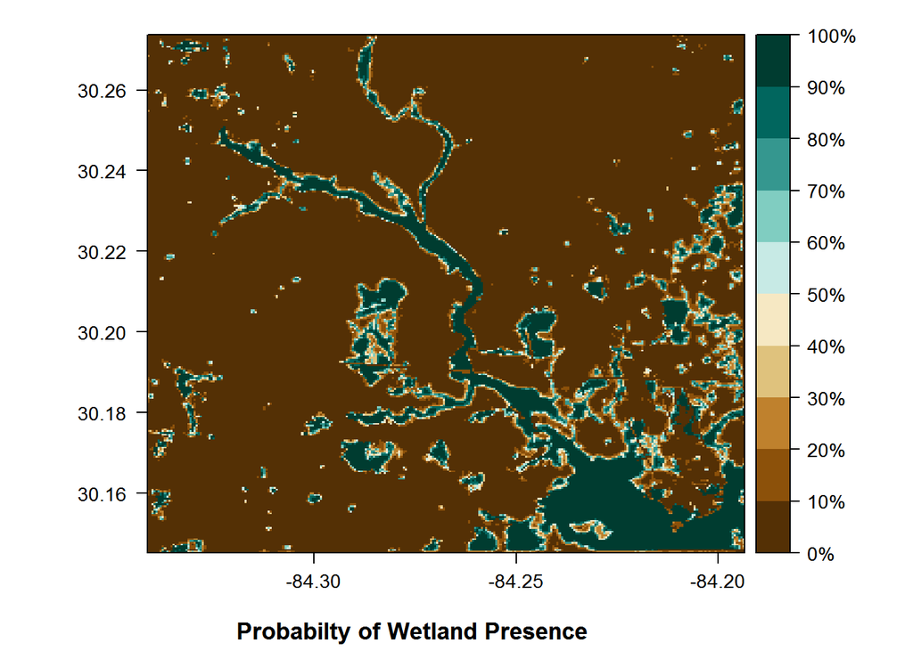

```r
M2p = Blank.r
values(M2p) = Wetlands.spdf@data$M7bProb

rng = seq(0, 1, 0.10)
rngL = paste(rng*100, '%', sep = "")
cr = brewer.pal(10, "BrBG")
M2pb = levelplot(M2p, margin = FALSE,
          sub = "Probabilty of Wetland Presence             ",
          xlab = NULL, ylab = NULL,
          col.regions = cr, at = rng,
          colorkey = list(at = rng, labels = rngL, col = cr),
          par.settings = list(fontsize = list(text = 13)))

M2pb
```

```r
rm(list=setdiff(ls(), c("model7", "model7_30", "model7_70", "model7_200", "TCS", "SDAquery",
                        "D100Time", "D30Time", "D70Time", "D200Time", "D200cnt", "D100cnt", "D70cnt",
                        "D30cnt", "FIX")))
```

# Extend Domain to 300km^2

### Domain Target Cell Size (TCS)

```r
xCOL = ceiling(17321/TCS)
yROW = ceiling(17328/TCS)
```

### Read Domain, Soil, and Landuse/Landcover Shapefiles

```r
#Domain (shapefile)
    Domain300 = readOGR(dsn = "./WetlandData/Domains/Domain300", layer = "Domain300",
                    stringsAsFactors = FALSE, p4s = "+proj=utm +zone=17 +datum=NAD83")
                    gIsValid(Domain300)
```

```
## [1] TRUE
```

```r
                    Domain300 = gBuffer(Domain300, width=0, byid=TRUE)

#Soils Data
    Raw_Soils.spdf = readOGR(dsn = "./WetlandData/SSURGO_NWF", layer = "SSURGO_NWF",
                     stringsAsFactors = FALSE, p4s = "+proj=utm +zone=17 +datum=NAD83")
                     Raw_Soils.spdf = crop(Raw_Soils.spdf, Domain300)
                     gIsValid(Raw_Soils.spdf) #Chk TopologY
```

```
## [1] TRUE
```

```r
                     Raw_Soils.spdf = gBuffer(Raw_Soils.spdf, width=0, byid=TRUE) #Fix Topology

#Landcover/Landuse Data
    LCLU_NWF.spdf = readOGR(dsn = "./WetlandData/LCLU_NWF", layer = "LCLU_NWF",
                    stringsAsFactors = FALSE, p4s = "+proj=utm +zone=17 +datum=NAD83")
                    LCLU_NWF.spdf = crop(LCLU_NWF.spdf, Domain300)
                    gIsValid(LCLU_NWF.spdf)
```

```
## [1] FALSE
```

```r
                    LCLU_NWF.spdf = gBuffer(LCLU_NWF.spdf, width=0, byid=TRUE)
```

### Subset Landcover Groups

```r
UP_LC.spdf = subset(LCLU_NWF.spdf,
                    LANDUSE_CO >= 2600 &
                    LANDUSE_CO <= 4430 )

Wet_LC.spdf = subset(LCLU_NWF.spdf,
                     LANDUSE_CO >= 5000 &
                     LANDUSE_CO <= 6999 )
```

### Crop soils data

```r
UP_Soils.spdf = crop(Raw_Soils.spdf, UP_LC.spdf)
UP_Soils.spdf@data = UP_Soils.spdf@data %>%
                     mutate(Designation = 0)


Wet_Soils.spdf = crop(Raw_Soils.spdf, Wet_LC.spdf)
Wet_Soils.spdf@data = Wet_Soils.spdf@data %>%
                      mutate(Designation = 1)
```

```r
UP_Soils1.spdf = spChFIDs(UP_Soils.spdf,
                          paste(as.character(
                                1:nrow(UP_Soils.spdf)),"U", sep = ""))

Wet_Soils1.spdf = spChFIDs(Wet_Soils.spdf,
                           paste(as.character(
                                1:nrow(Wet_Soils.spdf)),"W", sep = ""))

Soils.spdf = spRbind(UP_Soils1.spdf, Wet_Soils1.spdf)

Soils.spdf$IDs = 1:nrow(Soils.spdf)
```

### Combine Upland and Wetland Data Frames

```r
Soils.df = Soils.spdf@data

Soils0.df = subset(Soils.df,
                   select = -c(AREASYMBOL,  SPATIALVER, NationalMu,
                                muhelcl,  muwathelcl,  muwndhelcl,  interpfocu,
                                invesinten,  lkey,  iacornsr,  projectsca,  tabularver,
                                iccdcd,   iccdcdpct,  engstafdcd,  engstafll,  engstafml,
                                albedo_h,  albedo_l,  cropprodin,  rsprod_h,  rsprod_l,
                                rsprod_r,  slopelen_h,  slopelen_l,  cokey,  comppct_l,
                                comppct_h,  compkind,  earthcovki,  earthcov_1,  aspectccwi,
                                aspectrep,  aspectcwis,  geomdesc,  nirrcapuni,  irrcapcl,
                                irrcapscl,  irrcapunit,  constreesh,  soilslippo,  frostact,
                                soiltaxedi,  taxclname,  taxorder,  taxsuborde,  taxgrtgrou,
                                taxsubgrp,  taxparts_1, map_h,  map_l,  map_r, Shape_Leng, Shape_Area))

Soils1.df = as.data.frame(lapply
                          (Soils0.df, factor))
Soils2.df = Soils1.df %>%
            mutate(Designation = as.numeric(Soils.df$Designation),
                   IDs = as.numeric(Soils.df$IDs),
                   wtdepaprju = as.numeric(round(Soils.df$wtdepaprju),5),
                   wtdepannmi = as.numeric(round(Soils.df$wtdepannmi),5),
                   slopegradd = as.numeric(round(Soils.df$slopegradd),5),
                   slopegradw = as.numeric(round(Soils.df$slopegradw), 5),
                   aws025wta = as.numeric(round(Soils.df$aws025wta), 5),
                   aws050wta = as.numeric(round(Soils.df$aws050wta), 5),
                   aws0100wta = as.numeric(round(Soils.df$aws0100wta), 5),
                   aws0150wta = as.numeric(round(Soils.df$aws0150wta), 5),
                   niccdcdpct = as.numeric(round(Soils.df$niccdcdpct), 5),
                   albedo_r = as.numeric(round(Soils.df$albedo_r), 5),
                   elev_h = as.numeric(round(Soils.df$elev_h), 5),
                   elev_l = as.numeric(round(Soils.df$elev_l), 5),
                   elev_r = as.numeric(round(Soils.df$elev_r), 5),
                   slope_h = as.numeric(round(Soils.df$slope_h), 5),
                   slope_r = as.numeric(round(Soils.df$niccdcdpct), 5))
```

### Prior Distribution

```r
D0 = 0.33 #Prob of wetlands in Florida
D1 = 0.50 #Prop of being wetland if known to have wetland vegetation

Soils.spdf$Extent = gArea(Soils.spdf,
                          byid = TRUE)

Wet_area = as.numeric(
             Soils.spdf@data %>%
                       filter(Designation == 1) %>%
                       summarise(sum(Extent, na.rm = TRUE)))

Up_area = as.numeric(
            Soils.spdf@data %>%
                      filter(Designation == 0) %>%
                      summarise(sum(Extent, na.rm = TRUE)))

Wp = (Wet_area/(Wet_area + Up_area))
Up = (Up_area/(Wet_area + Up_area))

Pr = (Up*D0) + (Wp*D1)

q1 = list(p = .5, x = Pr)
q2 = list(p = .9, x = D1)
B.select = beta.select(q1, q2)

a = B.select[1]
b = B.select[2]

hyper.p = list(prec = list(
                        list(prior = "logitbeta",
                             param = c(a, b),
                             initial = 0)))
```

### Conduct Principal Components Analysis (PCA)

```r
Soils.PCA = Soils2.df %>%
                select(slopegradd, slopegradw, aws025wta, aws050wta, aws0100wta,
                aws0150wta, niccdcdpct, albedo_r, elev_h, elev_l, elev_r, slope_h,
                slope_r, wtdepaprju, wtdepannmi)

PCA.Result = PCA(Soils.PCA ,
                 scale.unit = TRUE,
                 ncp = 5,
                 graph = FALSE)
```

### Singular Value Decomposition (SVD) to Data Frame

```r
PCA.df = as.data.frame(PCA.Result$svd$U) %>%
                 mutate(Designation = as.numeric(Soils.df$Designation))
```

### Conduct Multiple Correspondance Analysis (MCA)

```r
Soils.MCA = Soils2.df %>%
               select(MUSYM, muname, mukind, farmlndcl, museq, brockdepmi,
                      flodfreqdc, flodfreqma, pondfreqpr, drclassdcd,
                      drclasswet, hydgrpdcd, niccdcd, engdwobdcd, engdwbdcd,  engdwbll,
                      engdwbml,   engsldcd,   engsldcp, englrsdcd,  engcmssdcd, engcmssmp,
                      urbrecptdc, urbrecptwt, forpehrtdc, hydclprs, awmmfpwwta, airtempa_h,
                      airtempa_l, airtempa_r, ffd_h, ffd_l, ffd_r, initsub_h, initsub_l,
                      initsub_r, slope_l, slopelen_r, totalsub_h, totalsub_l, totalsub_r,
                      compname, otherph, localphase, runoff, tfact, wei, weg, erocl,
                      hydricon, nirrcapcl, nirrcapscl, foragesuit, wlgrai, wlgrass, wlherbaceo,
                      wlshrub, wlconifero, wlhardwood, wlwetplant, wlshalloww, wlrangelan,
                      wlopenland, wlwoodland, wlwetland, corcon, corsteel, taxpartsiz,
                      taxceactcl, taxreactio, taxtempcl, taxmoistsc, taxtempreg)

MCA.Result = MCA(Soils.MCA,
                 ncp=5,
                 graph = FALSE)
```

### MCA Singular Value Decomposition (SVD) to .df

Pull SVD values from the MCA and add the associated Wetland/Upland “Designation” in a new data frame.

```r
MCA.df = as.data.frame(MCA.Result$svd$U) %>%
                 mutate(Designation = as.numeric(Soils.df$Designation))
```

### Combine Significant MCA and PCA Results

```r
Soils2.spdf = Soils.spdf

Soils2.spdf@data = PCA.df %>%
                   select(Designation, V1, V2, V3) %>%
                   mutate(MCA3 = MCA.df[,"V3"],
                          MUKEY = as.numeric(Soils.spdf@data[,"MUKEY"]))
```

### Convert Soils PCA and MCA Results to Raster Objects

First, create a raster template based on the resolution specified at top of the script.

```r
Blank.r = raster(nrows = yROW, ncols = xCOL)
extent(Blank.r) = extent(Soils2.spdf)
proj4string(Blank.r) = proj4string(Soils2.spdf)
```

### Create Wetland/Upland Designation Raster

```r
w_rast = rasterize(Wet_Soils.spdf,
                   Blank.r,
                   field = 1)

w_rast = reclassify(w_rast,
                    cbind(NA, 0))
```

### Create Rasters for Significatnt PCA/MCA Results

```r
V1_rast = rasterize(Soils2.spdf,
                    Blank.r,
                    field = Soils2.spdf@data$V1)

V2_rast = rasterize(Soils2.spdf,
                    Blank.r,
                    field = Soils2.spdf@data$V2)

V3_rast = rasterize(Soils2.spdf,
                    Blank.r,
                    field = Soils2.spdf@data$V3)

MCA3_rast = rasterize(Soils2.spdf,
                    Blank.r,
                    field = Soils2.spdf@data$MCA3)
```

### Convert Rasters to SpatialPolygonsDataFrame

```r
Wetlands.spdf = as(w_rast, "SpatialPolygonsDataFrame")
names(Wetlands.spdf) = "Designation"

Wetlands.spdf@data = Wetlands.spdf@data %>%
                        mutate(V1 = values(V1_rast),
                               V2 = values(V2_rast),
                               V3 = values(V3_rast),
                               MCAV3 = values(MCA3_rast))
```

## Soil Available Water Capacity (AWC) and Organic Mass (OM)

### Rasterize MUKEY

```r
AWC.r = rasterize(Soils2.spdf,
                      Blank.r,
                      field = Soils2.spdf@data$MUKEY)

OM.r = rasterize(Soils2.spdf,
                      Blank.r,
                      field = Soils2.spdf@data$MUKEY)
```

### Soil Functions

```r
HzWS = function(i) {
              wt = i$comppct_r[1]
              thick = with(i, hzdepb_r - hzdept_r)
              whc = thick * i$awc_r
                whc.total = sum(whc, na.rm=TRUE)
                data.frame(whc = whc.total, wt=wt)
}

HzWSO = function(i) {
              wto = i$comppct_r[1]
              thicko = with(i, hzdepb_r - hzdept_r)
              whco = thicko * i$Om_r
                whc.totalo = sum(whco, na.rm=TRUE)
                data.frame(whco = whc.totalo, wto=wto)
}
```

```r
MU_mean = function(i) {
                  whc = wtd.mean(i$whc, weights=i$wt)
                  data.frame(whc=whc)
}

MU_meano = function(i) {
                  whco = wtd.mean(i$whco, weights=i$wto)
                  data.frame(whco=whco)
}
```

### Add Raster Attribute Table (RAT)

```r
AWC.r = ratify(AWC.r,
               count = TRUE)

OM.r = ratify(OM.r,
               count = TRUE)
```

### save RATs as Objects

```r
rat = levels(AWC.r)[[1]]

rato = levels(OM.r)[[1]]
```

### Extract MUKEYs from the RAT

```r
in.statement = format_SQL_in_statement(rat$ID)

in.statement2 = format_SQL_in_statement(rato$ID)
```

### Query SDA

```r
q = paste("SELECT component.mukey, component.cokey, compname, comppct_r, hzdept_r, hzdepb_r, hzname, Om_r, awc_r FROM component JOIN chorizon ON component.cokey = chorizon.cokey AND mukey IN ", in.statement, "ORDER BY mukey, comppct_r DESC, hzdept_r ASC", sep ="")

ACW.res = SDAquery(q)
```

```
## sending SOAP request...
## processing results...
```

```r
q2 = paste("SELECT component.mukey, component.cokey, compname, comppct_r, hzdept_r, hzdepb_r, hzname, Om_r, awc_r FROM component JOIN chorizon ON component.cokey = chorizon.cokey AND mukey IN ", in.statement2, "ORDER BY mukey, comppct_r DESC, hzdept_r ASC", sep ="")

OM.res = SDAquery(q2)
```

```
## sending SOAP request...
## processing results...
```

### Aggregate Data

```r
co.whc = ACW.res %>%
              group_by(mukey, cokey) %>%
              do(HzWS(.))

mu.whc = co.whc %>%
              group_by(mukey) %>%
              do(MU_mean(.))

co.whco = OM.res %>%
              group_by(mukey, cokey) %>%
              do(HzWSO(.))

mu.whco = co.whco %>%
              group_by(mukey) %>%
              do(MU_meano(.))
```

### Join Results to Domain Rasters

```r
names(mu.whc)[1] = 'ID'
rat.new = left_join(rat, mu.whc)
levels(AWC.r) = rat.new
AWC = deratify(AWC.r, att='whc')

names(mu.whco)[1] = 'ID'
rato.new = left_join(rato, mu.whco)
levels(OM.r) = rato.new
OM = deratify(OM.r, att='whco')
```

### Add Results to Wetlands.spdf

```r
Wetlands.spdf$AWC = values(AWC)
Wetlands.spdf$OM = values(OM)
```

### Explanatory Variables linked to Topograpy

```r
#DEM (USGS 1/3 arc-sec)
      DEM = raster("./WetlandData/DEM_NWF/dem_nwf/w001001.adf")
      DEM = reclassify(DEM,
                        cbind(0, 0.001))

      DomainB = readOGR(dsn = "./WetlandData/Domains/Domain300",
                        layer = "Domain300",
                        stringsAsFactors = FALSE)
      DomainBp = spTransform(DomainB,
                       CRS(projection(DEM)))

      DEM = crop(DEM, DomainBp)
```

### Calculate Topographic Indicies

```r
RR = raster(nrow = yROW, ncol = xCOL)
extent(RR) = extent(DEM)

DEM2 = resample(DEM, RR,
                method='bilinear')

tpi = terrain(DEM2,
              opt = 'tpi')

TPI = reclassify(tpi,
                 cbind(NA, minValue(tpi)))

proj4string(TPI) = proj4string(LCLU_NWF.spdf)
extent(TPI) = extent(LCLU_NWF.spdf)

Wetlands.spdf$TPI = values(TPI)
```

```r
CTI0 = upslope.area(DEM,
                    log = TRUE,
                    atb = TRUE,
                    deg = 0.1)

CTI = reclassify(CTI0$atb,
                 cbind(NA, maxValue(CTI0)))

extent(CTI) = extent(LCLU_NWF.spdf)
CTI = resample(CTI, Blank.r, method = 'bilinear')

Wetlands.spdf$CTI = values(CTI)
```

## Bayesian Analysis

### Assign Region and IDs Labels

```r
Wetlands.spdf$Region = 1:nrow(Wetlands.spdf)
```

### Spatial Neighborhood as an INLA Graph

```r
nb = poly2nb(Wetlands.spdf, queen = FALSE)
nb2INLA("J", nb)
J = inla.read.graph("J")
```

### Run Previously Fitted Model

```r
D300ST = Sys.time()

formula7 = Designation ~ f(Region, model = "besag",
                           adjust.for.con.comp = FALSE,
                           scale.model = TRUE,
                           hyper = hyper.p,
                           graph = J) +
                         V1 + V2 + V3 + AWC + OM + CTI + TPI

model7_300  =  inla(formula7, family = "binomial",
                       control.family = list(link = "cloglog"),
                       control.predictor = list(compute = TRUE),
                       control.compute=list(cpo = TRUE, waic=TRUE),
                       data = Wetlands.spdf@data)

summary(model7_300)
```

```
##
## Call:
## c("inla(formula = formula7, family = \"binomial\", data = Wetlands.spdf@data, ",  "    control.compute = list(cpo = TRUE, waic = TRUE), control.predictor = list(compute = TRUE), ",  "    control.family = list(link = \"cloglog\"))")
##
## Time used:
##  Pre-processing    Running inla Post-processing           Total
##          2.6689      11627.4541         11.5028      11641.6258
##
## Fixed effects:
##                 mean     sd 0.025quant 0.5quant 0.975quant     mode kld
## (Intercept) -10.8459 0.1912   -11.2098 -10.8535   -10.4485 -10.8691   0
## V1           -1.9334 0.0387    -2.0091  -1.9336    -1.8569  -1.9342   0
## V2           -0.9452 0.0286    -1.0016  -0.9451    -0.8891  -0.9450   0
## V3            0.3386 0.0284     0.2829   0.3386     0.3942   0.3386   0
## AWC           0.1749 0.0053     0.1644   0.1749     0.1853   0.1749   0
## OM            0.0014 0.0003     0.0010   0.0014     0.0019   0.0014   0
## CTI           0.3339 0.0118     0.3107   0.3339     0.3571   0.3339   0
## TPI          -0.8050 0.0308    -0.8654  -0.8050    -0.7445  -0.8050   0
##
## Random effects:
## Name   Model
##  Region   Besags ICAR model
##
## Model hyperparameters:
##                        mean     sd 0.025quant 0.5quant 0.975quant   mode
## Precision for Region 0.1382 0.0042     0.1305    0.138      0.147 0.1374
##
## Expected number of effective parameters(std dev): 12301.13(59.26)
## Number of equivalent replicates : 9.788
##
## Watanabe-Akaike information criterion (WAIC) ...: 14423.21
## Effective number of parameters .................: 1275.24
##
## Marginal log-Likelihood:  -99185.21
## CPO and PIT are computed
##
## Posterior marginals for linear predictor and fitted values computed
```

```r
#Exponentiate
FIX(model7_300)
```

```
##             expMean exp0.025 exp0.975
## (Intercept) -100.00  -100.00  -100.00
## V1           -85.54   -86.59   -84.38
## V2           -61.14   -63.27   -58.90
## V3            40.30    32.70    48.32
## AWC           19.11    17.87    20.36
## OM             0.14     0.10     0.19
## CTI           39.64    36.44    42.91
## TPI          -55.29   -57.91   -52.50
```

```r
Wetlands.spdf@data = Wetlands.spdf@data %>%
                        mutate(M7cSLPM = model7_300$summary.linear.predictor[,"mean"],
                               M7cProb = exp(M7cSLPM)/(1+exp(M7cSLPM)))

D300ET = Sys.time()
D300Time = as.numeric(D300ET - D300ST, units = "mins")
D300cnt = length(Wetlands.spdf@data$Designation)
```

### Wetland Probabilty Map

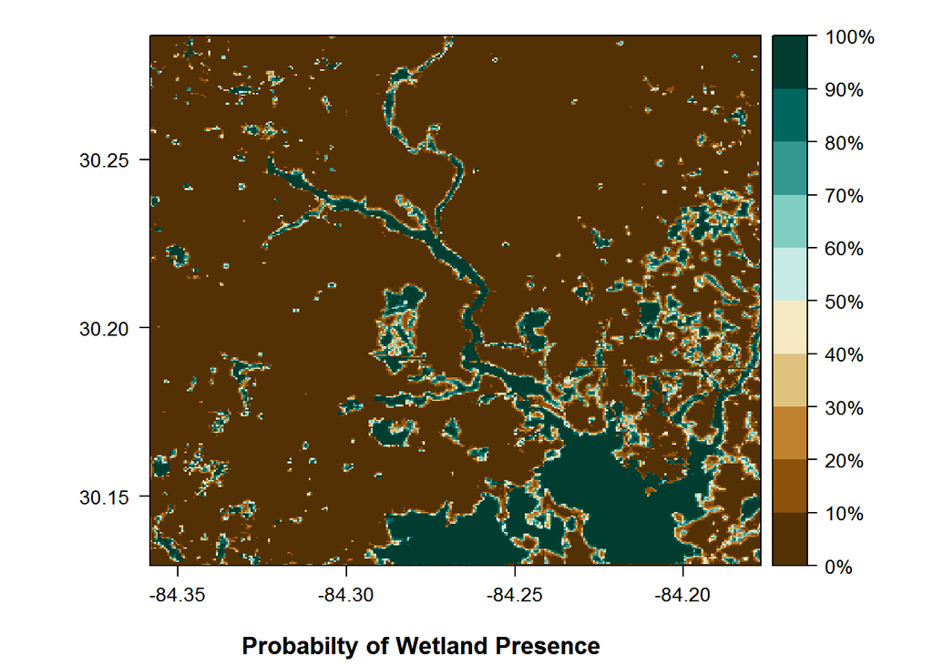

```r
M300 = Blank.r
values(M300) = Wetlands.spdf@data$M7cProb

rng = seq(0, 1, 0.10)
rngL = paste(rng*100, '%', sep = "")
cr = brewer.pal(10, "BrBG")
M300p = levelplot(M300, margin = FALSE,
          sub = "Probabilty of Wetland Presence             ",
          xlab = NULL, ylab = NULL,
          col.regions = cr, at = rng,
          colorkey = list(at = rng, labels = rngL, col = cr),
          par.settings = list(fontsize = list(text = 13)))

M300p
```

### Figure 4 (Compare Prediction to the NWI)

```r
M2p = Blank.r
values(M2p) = Wetlands.spdf@data$M7cProb

NWI = readOGR(dsn = "./WetlandData/NWI/Domain300",
              layer = "NWI_D300",
              stringsAsFactors = FALSE, p4s = "+proj=utm +zone=17 +datum=NAD83")
              gIsValid(NWI)
```

```
## [1] FALSE
```

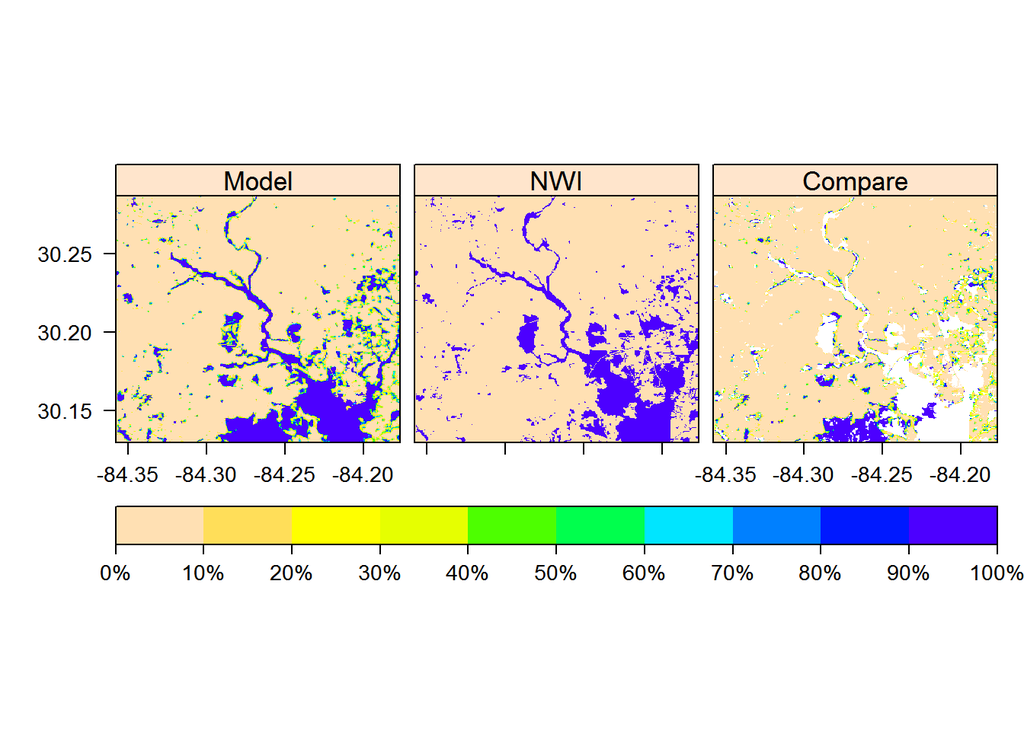

```r
              NWI = gBuffer(NWI, width=0, byid=TRUE)

nwi.r = rasterize(NWI,
                  Blank.r,
                  field = 1)

nwi.r = reclassify(nwi.r,
                     cbind(NA, 0))

Wetlands.spdf$NWI = values(nwi.r)

nwi2.r= reclassify(nwi.r,
                     cbind(1, NA))

Wet_Change = sum(nwi2.r, M2p)

stack <- stack(M2p, nwi.r, Wet_Change)
names(stack) = c("Model", "NWI", "Compare")


rng = seq(0, 1, 0.1)
rngL = paste(rng*100, '%', sep = "")
cr = rev(topo.colors(10))
levelplot(stack,
          layout=c(3, 1),
          margin = FALSE,
          sub = NULL,
          xlab = NULL, ylab = NULL,
          col.regions = cr, at = rng,
          colorkey = list(space = "bottom",
                          at = rng,
                          labels = rngL,
                          col = cr),
          par.settings = list(fontsize = list(text = 13)))
```

```r
PD_NWIcnt = sum(Wetlands.spdf@data$NWI)

PDwCells.df = filter(Wetlands.spdf@data,
                     M7cProb >= 0.5)

PDwCells = length(PDwCells.df$M7cProb)

WetDiffPD = ((PDwCells - PD_NWIcnt)/PD_NWIcnt)*100

PD_NWIcnt
```

```
## [1] 18300
```

```r
PDwCells
```

```
## [1] 19673
```

```r
WetDiffPD
```

```
## [1] 7.502732
```

### Figure 3 (Compare Response)

```r
detach("package:soilDB", unload=TRUE)
detach("package:aqp", unload=TRUE)

Fitted.df = as.data.frame(cbind(Run = rep("Fitted", 35),
                            V1 = (exp(-model7$marginals.fixed$V1[, 1]) - 1) * 100,
                            V2 = (exp(-model7$marginals.fixed$V2[, 1]) - 1) * 100,
                            V3 = (exp(-model7$marginals.fixed$V3[, 1]) - 1) * 100,
                            TPI = (exp(-model7$marginals.fixed$TPI[, 1]) - 1) * 100,
                            CTI = (exp(-model7$marginals.fixed$CTI[, 1]) - 1) * 100,
                            AWC = (exp(-model7$marginals.fixed$AWC[, 1]) - 1) * 100,
                            OM = (exp(-model7$marginals.fixed$OM[, 1]) - 1) * 100))

D200.df = as.data.frame(cbind(Run = rep("D200", 35),
                              V1 = (exp(-model7_200$marginals.fixed$V1[, 1]) - 1) * 100,
                              V2 = (exp(-model7_200$marginals.fixed$V2[, 1]) - 1) * 100,
                              V3 = (exp(-model7_200$marginals.fixed$V3[, 1]) - 1) * 100,
                              TPI = (exp(-model7_200$marginals.fixed$TPI[, 1]) - 1) * 100,
                              CTI = (exp(-model7_200$marginals.fixed$CTI[, 1]) - 1) * 100,
                              AWC = (exp(-model7_200$marginals.fixed$AWC[, 1]) - 1) * 100,
                              OM = (exp(-model7_200$marginals.fixed$OM[, 1]) - 1) * 100))

D300.df = as.data.frame(cbind(Run = rep("D300", 35),
                              V1 = (exp(-model7_300$marginals.fixed$V1[, 1]) - 1) * 100,
                              V2 = (exp(-model7_300$marginals.fixed$V2[, 1]) - 1) * 100,
                              V3 = (exp(-model7_300$marginals.fixed$V3[, 1]) - 1) * 100,
                              TPI = (exp(-model7_300$marginals.fixed$TPI[, 1]) - 1) * 100,
                              CTI = (exp(-model7_300$marginals.fixed$CTI[, 1]) - 1) * 100,
                              AWC = (exp(-model7_300$marginals.fixed$AWC[, 1]) - 1) * 100,
                              OM = (exp(-model7_300$marginals.fixed$OM[, 1]) - 1) * 100))

Res30.df = as.data.frame(cbind(Run = rep("Res30", 35),
                               V1 = (exp(-model7_30$marginals.fixed$V1[, 1]) - 1) * 100,
                               V2 = (exp(-model7_30$marginals.fixed$V2[, 1]) - 1) * 100,
                               V3 = (exp(-model7_30$marginals.fixed$V3[, 1]) - 1) * 100,
                               TPI = (exp(-model7_30$marginals.fixed$TPI[, 1]) - 1) * 100,
                               CTI = (exp(-model7_30$marginals.fixed$CTI[, 1]) - 1) * 100,
                               AWC = (exp(-model7_30$marginals.fixed$AWC[, 1]) - 1) * 100,
                               OM = (exp(-model7_30$marginals.fixed$OM[, 1]) - 1) * 100))

Res70.df = as.data.frame(cbind(Run = rep("Res70", 35),
                               V1 = (exp(-model7_70$marginals.fixed$V1[, 1]) - 1) * 100,
                               V2 = (exp(-model7_70$marginals.fixed$V2[, 1]) - 1) * 100,
                               V3 = (exp(-model7_70$marginals.fixed$V3[, 1]) - 1) * 100,
                               TPI = (exp(-model7_70$marginals.fixed$TPI[, 1]) - 1) * 100,
                               CTI = (exp(-model7_70$marginals.fixed$CTI[, 1]) - 1) * 100,
                               AWC = (exp(-model7_70$marginals.fixed$AWC[, 1]) - 1) * 100,
                               OM = (exp(-model7_70$marginals.fixed$OM[, 1]) - 1) * 100))

ResultsE.df = rbind(Fitted.df, D200.df, D300.df)
ResultsR.df = rbind(Fitted.df, Res30.df, Res70.df)

FWE.df = melt(ResultsE.df, "Run")
FWE.df$value = as.numeric(FWE.df$value)

FWR.df = melt(ResultsR.df, "Run")
```

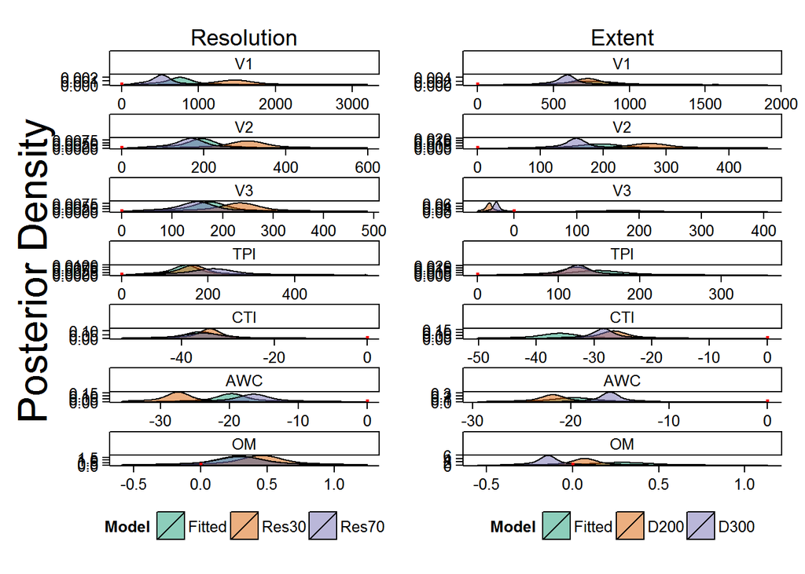

```r
FWR.df$value = as.numeric(FWR.df$value)

plotEXT = ggplot(FWE.df, aes(value, fill = as.factor(Run))) +
                 stat_density(adjust = 2,
                 position = "identity",
                 color = "black", alpha = 0.5) +
                 scale_fill_brewer(palette="Dark2") +
                 theme_classic() +
                 facet_wrap(~ variable,
                          scales = "free",
                          ncol = 1) +
                 xlab(NULL) +
                 ylab(NULL) +
                 theme(legend.position="bottom") +
                 labs(title = "Extent",
                    fill = "Model") +
                 geom_vline(data = FWE.df,
                 aes(xintercept = 0,
                     colour=Run),
                     linetype = "dotted",
                     size = 1, col = "red")


plotRES = ggplot(FWR.df, aes(value, fill = as.factor(Run))) +
                 stat_density(adjust = 2,
                 position = "identity",
                 color = "black", alpha = 0.5) +
                 scale_fill_brewer(palette="Dark2") +
                 theme_classic() +
                 facet_wrap(~ variable,
                          scales = "free",
                          ncol = 1) +
                 xlab(NULL) +
                 ylab("Posterior Density") +
                 theme(legend.position="bottom",
                       axis.title.y = element_text(size = 25)) +
                 labs(title = "Resolution",
                    fill = "Model") +
                 geom_vline(data = FWR.df,
                 aes(xintercept = 0,
                     colour=Run),
                     linetype = "dotted",
                     size = 1, col = "red")

grid.arrange(plotRES, plotEXT, ncol = 2)
```

### Comparison to NWI

```r
#Brier score (Training Set)
BSNW.df = filter(Wetlands.spdf@data, Designation == 1)
BSTrn = mean((BSNW.df$M7cProb - 1)^2)

BSNW.df = filter(Wetlands.spdf@data, Designation == 0)
BSTrnU = mean((BSNW.df$M7cProb - 1)^2)

BScnt.df = filter(Wetlands.spdf@data, M7cProb >= 0.49)
Cnt300 = length(BScnt.df$M7cProb)

#Brier score (NWI)
BSNWI.df = filter(Wetlands.spdf@data, NWI == 1)
BSNWI = mean((BSNWI.df$M7cProb - 1)^2)
NWI300Cnt = length(BSNWI.df$NWI)

BSNWI.df = filter(Wetlands.spdf@data, NWI == 0)
BSNWIU = mean((BSNWI.df$M7cProb - 1)^2)

Brier = as.data.frame(rbind(BST300 =BSTrn,
                            BSTU300 = BSTrnU,
                            Cnt300 = Cnt300,
                            BSNWI300 = BSNWI,
                            BSNWIU300 = BSNWIU,
                            NWI300cnt = NWI300Cnt))
Brier
```

```
##                     V1
## BST300    3.050098e-02
## BSTU300   9.414647e-01
## Cnt300    1.977000e+04
## BSNWI300  2.236197e-01
## BSNWIU300 8.953185e-01
## NWI300cnt 1.830000e+04
```

```r
NWI_Mod300 = ((Cnt300 - NWI300Cnt)/NWI300Cnt)*100

#Change relative to NWI:
NWI_Mod300
```

```
## [1] 8.032787
```

### Model Run Times

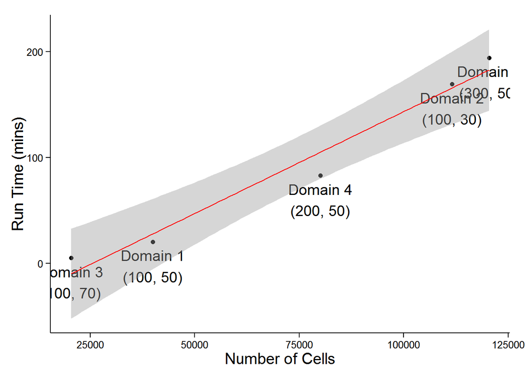

```r
Time.df = as.data.frame(rbind(D70Time, D100Time, D200Time, D30Time, D300Time))
colnames(Time.df) = "Time"

Time.df$Cnts = c(D70cnt, D100cnt, D200cnt, D30cnt, D300cnt)

TimeS = arrange(Time.df, Cnts)
rownames(TimeS) = c("Domain 3\n(100, 70)",
            "Domain 1\n(100, 50)",
            "Domain 4\n(200, 50)",
            "Domain 2\n(100, 30)",
            "Domain 5\n(300, 50)")

ggplot(TimeS, aes(Cnts, Time, label= rownames(TimeS))) +
       geom_point() +
       geom_text(hjust=0.5, vjust=1.25) +
       theme_classic() +
       stat_smooth(method = "lm",
                   col = "red") +
       xlab("Number of Cells") +
       ylab("Run Time (mins)") +
       theme(axis.title.y = element_text(size = 15),
             axis.title.x = element_text(size = 15))
```

```r
TimeS
```

```
##                           Time   Cnts
## Domain 3\n(100, 70)   5.079774  20449
## Domain 1\n(100, 50)  20.324654  40000
## Domain 4\n(200, 50)  82.823486  80089
## Domain 2\n(100, 30) 169.206008 111556
## Domain 5\n(300, 50) 194.032000 120409
```

```r
rm(list=setdiff(ls(), c("model7", "model7_30", "model7_70", "model7_200", "model7_300", "Brier",
                        "SDAquery", "Time.df", "FIX")))
```

# Changing Domain Location

The sensitivity of the model to changes in location is explored below by first relocating the domain to different portion of the same physiographic province as the primary domain and then to a location in southwest Florida. The selected model (“model7”) is applied to both domains holding resolution constant for both with a cell edge of 50m.

## Study Area Domain NW

[figure not shown]

```r
Map = get_map(location = c(-84.13, 30.30),
              source = "google",
              zoom = 12,
              color = "color",
              maptype = "terrain")
p1 = ggmap(Map, dev = "extent") +
  geom_segment(aes(x = -84.18281, xend = -84.07878 , y = 30.36819, yend = 30.36819),
             color = "red") +
  geom_segment(aes(x = -84.18281, xend = -84.07878 , y = 30.27797  , yend = 30.27797  ),
             color = "red") +
  geom_segment(aes(x = -84.18281, xend = -84.18281, y = 30.36819, yend = 30.27797  ),
             color = "red") +
  geom_segment(aes(x = -84.07878 , xend = -84.07878 , y = 30.36819, yend = 30.27797  ),
             color = "red") +
  labs(x = expression(paste("Longitude (", degree, "W)")),
       y = expression(paste("Latitude (", degree, "N)")))

source('./WetlandData/ScaleBar/ScaleBarNorth.R')

p1b = p1 + scaleBar(lon = -84.232,
                    lat = 30.21,
                    distanceLon = 5,
                    distanceLat = 1,
                    distanceLegend = 1.5,
                    dist.unit = "km",
                    arrow.length = 3,
                    arrow.distance = 2,
                    arrow.North.size = 12)

p1b + theme(panel.grid.minor = element_line(colour = NA),
            panel.grid.minor = element_line(colour = NA),
            panel.background = element_rect(fill = NA, colour = NA),
            rect = element_blank())
```

```r
graphics.off()
```

### Domain Target Cell Size (TCS)

```r
TCS = 50 #Raster cell edge length (meters)

xCOL = ceiling(10000/TCS)
yROW = ceiling(10000/TCS)
```

### Read Soil and Landuse/Landcover Shapefiles

```r
#Soils Data
    Raw_Soils.spdf = readOGR(dsn = "./WetlandData/SSURGO_NW2", layer = "SSURGO_NW2",
                     stringsAsFactors = FALSE, p4s = "+proj=utm +zone=17 +datum=NAD83")
                     gIsValid(Raw_Soils.spdf) #Chk TopologY
```

```
## [1] TRUE
```

```r
                     Raw_Soils.spdf = gBuffer(Raw_Soils.spdf, width=0, byid=TRUE) #Fix Topology

#Landcover/Landuse Data
    LCLU_NWF.spdf = readOGR(dsn = "./WetlandData/LCLU_NW2", layer = "LCLU_NW2",
                    stringsAsFactors = FALSE, p4s = "+proj=utm +zone=17 +datum=NAD83")
                    gIsValid(LCLU_NWF.spdf)
```

```
## [1] FALSE
```

```r
                    LCLU_NWF.spdf = gBuffer(LCLU_NWF.spdf, width=0, byid=TRUE)
```

### Subset Landcover Groups

```r
UP_LC.spdf = subset(LCLU_NWF.spdf,
                    LANDUSE_CO >= 2600 &
                    LANDUSE_CO <= 4430 )

Wet_LC.spdf = subset(LCLU_NWF.spdf,
                     LANDUSE_CO >= 5000 &
                     LANDUSE_CO <= 6999 )
```

### Crop soils data

```r
UP_Soils.spdf = crop(Raw_Soils.spdf, UP_LC.spdf)
UP_Soils.spdf@data = UP_Soils.spdf@data %>%
                     mutate(Designation = 0)


Wet_Soils.spdf = crop(Raw_Soils.spdf, Wet_LC.spdf)
Wet_Soils.spdf@data = Wet_Soils.spdf@data %>%
                      mutate(Designation = 1)
```

```r
UP_Soils1.spdf = spChFIDs(UP_Soils.spdf,
                          paste(as.character(
                                1:nrow(UP_Soils.spdf)),"U", sep = ""))

Wet_Soils1.spdf = spChFIDs(Wet_Soils.spdf,
                           paste(as.character(
                                1:nrow(Wet_Soils.spdf)),"W", sep = ""))

Soils.spdf = spRbind(UP_Soils1.spdf, Wet_Soils1.spdf)

Soils.spdf$IDs = 1:nrow(Soils.spdf)
```

### Prior Distribution

To quantify current understanding:

```r
D0 = 0.33 #Prob of wetlands in Florida
D1 = 0.50 #Prop of being wetland if known to have wetland vegetation

Soils.spdf$Extent = gArea(Soils.spdf,
                          byid = TRUE)

Wet_area = as.numeric(
             Soils.spdf@data %>%
                       filter(Designation == 1) %>%
                       summarise(sum(Extent, na.rm = TRUE)))

Up_area = as.numeric(
            Soils.spdf@data %>%
                      filter(Designation == 0) %>%
                      summarise(sum(Extent, na.rm = TRUE)))

Wp = (Wet_area/(Wet_area + Up_area))
Up = (Up_area/(Wet_area + Up_area))

Pr = (Up*D0) + (Wp*D1)
```

```r
q1 = list(p = .5, x = Pr)
q2 = list(p = .9, x = D1)
B.select = beta.select(q1, q2)

a = B.select[1]
b = B.select[2]
```

```r
hyper.p = list(prec = list(
                        list(prior = "logitbeta",
                             param = c(a, b),
                             initial = 0)))
```

### Combine Upland and Wetland Data Frames

```r
Soils.df = Soils.spdf@data

Soils0.df = subset(Soils.df,
                   select = -c(AREASYMBOL,  SPATIALVER, NationalMu,
                                muhelcl,  muwathelcl,  muwndhelcl,  interpfocu,
                                invesinten,  lkey,  iacornsr,  projectsca,  tabularver,
                                iccdcd,   iccdcdpct,  engstafdcd,  engstafll,  engstafml,
                                albedo_h,  albedo_l,  cropprodin,  rsprod_h,  rsprod_l,
                                rsprod_r,  slopelen_h,  slopelen_l,  cokey,  comppct_l,
                                comppct_h,  compkind,  earthcovki,  earthcov_1,  aspectccwi,
                                aspectrep,  aspectcwis,  geomdesc,  nirrcapuni,  irrcapcl,
                                irrcapscl,  irrcapunit,  constreesh,  soilslippo,  frostact,
                                soiltaxedi,  taxclname,  taxorder,  taxsuborde,  taxgrtgrou,
                                taxsubgrp,  taxparts_1, map_h,  map_l,  map_r, Shape_Leng, Shape_Area))

Soils1.df = as.data.frame(lapply
                          (Soils0.df, factor))
Soils2.df = Soils1.df %>%
            mutate(Designation = as.numeric(Soils.df$Designation),
                   IDs = as.numeric(Soils.df$IDs),
                   wtdepaprju = as.numeric(round(Soils.df$wtdepaprju),5),
                   wtdepannmi = as.numeric(round(Soils.df$wtdepannmi),5),
                   slopegradd = as.numeric(round(Soils.df$slopegradd),5),
                   slopegradw = as.numeric(round(Soils.df$slopegradw), 5),
                   aws025wta = as.numeric(round(Soils.df$aws025wta), 5),
                   aws050wta = as.numeric(round(Soils.df$aws050wta), 5),
                   aws0100wta = as.numeric(round(Soils.df$aws0100wta), 5),
                   aws0150wta = as.numeric(round(Soils.df$aws0150wta), 5),
                   niccdcdpct = as.numeric(round(Soils.df$niccdcdpct), 5),
                   albedo_r = as.numeric(round(Soils.df$albedo_r), 5),
                   elev_h = as.numeric(round(Soils.df$elev_h), 5),
                   elev_l = as.numeric(round(Soils.df$elev_l), 5),
                   elev_r = as.numeric(round(Soils.df$elev_r), 5),
                   slope_h = as.numeric(round(Soils.df$slope_h), 5),
                   slope_r = as.numeric(round(Soils.df$niccdcdpct), 5))
```

### Conduct Principal Components Analysis (PCA)

```r
Soils.PCA = Soils2.df %>%
                select(slopegradd, slopegradw, aws025wta, aws050wta, aws0100wta,
                aws0150wta, niccdcdpct, albedo_r, elev_h, elev_l, elev_r, slope_h,
                slope_r, wtdepaprju, wtdepannmi)

PCA.Result = PCA(Soils.PCA ,
                 scale.unit = TRUE,
                 ncp = 5,
                 graph = FALSE)
```

### Singular Value Decomposition (SVD) to Data Frame

```r
PCA.df = as.data.frame(PCA.Result$svd$U) %>%
                 mutate(Designation = as.numeric(Soils.df$Designation))
```

### Verify Significance of PCA

```r
PCAfnw = Designation ~ V1 + V2 + V3 + V4 + V5

PCAnw  =  inla(PCAfnw, family = "binomial",
                       control.family = list(link = "cloglog"),
                       control.predictor = list(compute = TRUE),
                       control.compute=list(dic = TRUE, cpo = TRUE),
                       data = PCA.df)
summary(PCAnw)
```

```
##
## Call:
## c("inla(formula = PCAfnw, family = \"binomial\", data = PCA.df, control.compute = list(dic = TRUE, ",  "    cpo = TRUE), control.predictor = list(compute = TRUE), control.family = list(link = \"cloglog\"))" )
##
## Time used:
##  Pre-processing    Running inla Post-processing           Total
##          0.1532          0.4885          0.2733          0.9150
##
## Fixed effects:
##                mean     sd 0.025quant 0.5quant 0.975quant    mode kld
## (Intercept)  0.3337 0.0588     0.2199   0.3331     0.4509  0.3319   0
## V1          -0.1428 0.0554    -0.2504  -0.1432    -0.0328 -0.1441   0
## V2          -0.0956 0.0609    -0.2171  -0.0950     0.0223 -0.0938   0
## V3           0.0868 0.0553    -0.0222   0.0869     0.1948  0.0872   0
## V4          -0.0199 0.0544    -0.1300  -0.0187     0.0838 -0.0164   0
## V5          -0.0565 0.0566    -0.1646  -0.0576     0.0580 -0.0598   0
##
## The model has no random effects
##
## The model has no hyperparameters
##
## Expected number of effective parameters(std dev): 6.005(0.00)
## Number of equivalent replicates : 99.25
##
## Deviance Information Criterion (DIC) ...: 824.63
## Effective number of parameters .........: 5.996
##
## Marginal log-Likelihood:  -439.83
## CPO and PIT are computed
##
## Posterior marginals for linear predictor and fitted values computed
```

```r
PCAfnw2 = Designation ~ V1

PCAnw2  =  inla(PCAfnw2, family = "binomial",
                       control.family = list(link = "cloglog"),
                       control.predictor = list(compute = TRUE),
                       control.compute=list(dic = TRUE, cpo = TRUE),
                       data = PCA.df)
summary(PCAnw2)
```

```
##
## Call:
## c("inla(formula = PCAfnw2, family = \"binomial\", data = PCA.df, control.compute = list(dic = TRUE, ",  "    cpo = TRUE), control.predictor = list(compute = TRUE), control.family = list(link = \"cloglog\"))" )
##
## Time used:
##  Pre-processing    Running inla Post-processing           Total
##          0.1121          0.4454          0.1912          0.7487
##
## Fixed effects:
##                mean     sd 0.025quant 0.5quant 0.975quant    mode kld
## (Intercept)  0.3271 0.0586     0.2137   0.3265     0.4438  0.3253   0
## V1          -0.1469 0.0561    -0.2556  -0.1474    -0.0356 -0.1484   0
##
## The model has no random effects
##
## The model has no hyperparameters
##
## Expected number of effective parameters(std dev): 2.005(0.00)
## Number of equivalent replicates : 297.28
##
## Deviance Information Criterion (DIC) ...: 823.10
## Effective number of parameters .........: 2.003
##
## Marginal log-Likelihood:  -417.81
## CPO and PIT are computed
##
## Posterior marginals for linear predictor and fitted values computed
```

### Conduct Multiple Correspondance Analysis (MCA)

```r
Soils.MCA = Soils2.df %>%
               select(MUSYM, muname, mukind, farmlndcl, museq, brockdepmi,
                      flodfreqdc, flodfreqma, pondfreqpr, drclassdcd,
                      drclasswet, hydgrpdcd, niccdcd, engdwobdcd, engdwbdcd,  engdwbll,
                      engdwbml,   engsldcd,   engsldcp, englrsdcd,  engcmssdcd, engcmssmp,
                      urbrecptdc, urbrecptwt, forpehrtdc, hydclprs, awmmfpwwta, airtempa_h,
                      airtempa_l, airtempa_r, ffd_h, ffd_l, ffd_r, initsub_h, initsub_l,
                      initsub_r, slope_l, slopelen_r, totalsub_h, totalsub_l, totalsub_r,
                      compname, otherph, localphase, runoff, tfact, wei, weg, erocl,
                      hydricon, nirrcapcl, nirrcapscl, foragesuit, wlgrai, wlgrass, wlherbaceo,
                      wlshrub, wlconifero, wlhardwood, wlwetplant, wlshalloww, wlrangelan,
                      wlopenland, wlwoodland, wlwetland, corcon, corsteel, taxpartsiz,
                      taxceactcl, taxreactio, taxtempcl, taxmoistsc, taxtempreg)

MCA.Result = MCA(Soils.MCA,
                 ncp=5,
                 graph = FALSE)
```

### MCA Singular Value Decomposition (SVD) to .df

```r
MCA.df = as.data.frame(MCA.Result$svd$U) %>%
                 mutate(Designation = as.numeric(Soils.df$Designation))
```

### Verify Significance of MCA

```r
MCAfnw = Designation ~ V1 + V2 + V3 + V4 + V5

MCAnw  =  inla(MCAfnw, family = "binomial",
                       control.family = list(link = "cloglog"),
                       control.predictor = list(compute = TRUE),
                       control.compute=list(dic = TRUE, cpo = TRUE),
                       data = MCA.df)
summary(MCAnw)
```

```
##
## Call:
## c("inla(formula = MCAfnw, family = \"binomial\", data = MCA.df, control.compute = list(dic = TRUE, ",  "    cpo = TRUE), control.predictor = list(compute = TRUE), control.family = list(link = \"cloglog\"))" )
##
## Time used:
##  Pre-processing    Running inla Post-processing           Total
##          0.1491          0.4733          0.2694          0.8918
##
## Fixed effects:
##                mean     sd 0.025quant 0.5quant 0.975quant    mode kld
## (Intercept)  0.3327 0.0587     0.2192   0.3321     0.4496  0.3309   0
## V1           0.1051 0.0678    -0.0198   0.1019     0.2470  0.0955   0
## V2          -0.0884 0.0573    -0.2010  -0.0884     0.0240 -0.0883   0
## V3           0.0497 0.0595    -0.0660   0.0493     0.1675  0.0486   0
## V4          -0.0077 0.0573    -0.1098  -0.0115     0.1154 -0.0196   0
## V5          -0.0702 0.0646    -0.2117  -0.0646     0.0416 -0.0526   0
##
## The model has no random effects
##
## The model has no hyperparameters
##
## Expected number of effective parameters(std dev): 6.005(0.00)
## Number of equivalent replicates : 99.25
##
## Deviance Information Criterion (DIC) ...: 829.84
## Effective number of parameters .........: 5.624
##
## Marginal log-Likelihood:  -442.37
## CPO and PIT are computed
##
## Posterior marginals for linear predictor and fitted values computed
```

Also adding variables used in model7 of the primary domain

```r
Soils2.spdf = Soils.spdf

Soils2.spdf@data = PCA.df %>%
                   select(Designation, V1, V2, V3) %>%
                   mutate(MUKEY = as.numeric(Soils.spdf@data[,"MUKEY"]))
```

### Convert Soils PCA and MCA Results to Raster Objects

```r
Blank.r = raster(nrows = yROW, ncols = xCOL)
extent(Blank.r) = extent(Soils2.spdf)
proj4string(Blank.r) = proj4string(Soils2.spdf)
```

### Create Wetland/Upland Designation Raster

```r
w_rast = rasterize(Wet_Soils.spdf,
                   Blank.r,
                   field = 1)

w_rast = reclassify(w_rast,
                    cbind(NA, 0))
```

### Create Rasters for Significatnt PCA/MCA Results

```r
V1_rast = rasterize(Soils2.spdf,
                    Blank.r,
                    field = Soils2.spdf@data$V1)

V2_rast = rasterize(Soils2.spdf,
                    Blank.r,
                    field = Soils2.spdf@data$V2)

V3_rast = rasterize(Soils2.spdf,
                    Blank.r,
                    field = Soils2.spdf@data$V3)
```

### Convert Rasters to SpatialPolygonsDataFrame

Add PCA and MCA results

```r
Wetlands.spdf = as(w_rast, "SpatialPolygonsDataFrame")
names(Wetlands.spdf) = "Designation"

Wetlands.spdf@data = Wetlands.spdf@data %>%
                        mutate(V1 = values(V1_rast),
                               V2 = values(V2_rast),
                               V3 = values(V3_rast))
```

### Additional Libraries are Needed

```r
#install.packages('Hmisc', dep=TRUE)
suppressMessages(library(Hmisc))

#install.packages('soilDB', dep=TRUE) #from CRAN + dependencies
#install.packages("soilDB", repos="http://R-Forge.R-project.org") # most recent from r-forge
suppressMessages(library(soilDB))

#install.packages("SSOAP", repos = "http://www.omegahat.org/R", type="source") # SSOAP, XMLSchema
suppressMessages(library(SSOAP))
```

## Soil Available Water Capacity (AWC) and Organic Mass (OM)

### Rasterize MUKEY

```r
AWC.r = rasterize(Soils2.spdf,
                      Blank.r,
                      field = Soils2.spdf@data$MUKEY)

OM.r = rasterize(Soils2.spdf,
                      Blank.r,
                      field = Soils2.spdf@data$MUKEY)
```

### Soil Functions

```r
HzWS = function(i) {
              wt = i$comppct_r[1]
              thick = with(i, hzdepb_r - hzdept_r)
              whc = thick * i$awc_r
                whc.total = sum(whc, na.rm=TRUE)
                data.frame(whc = whc.total, wt=wt)
}

HzWSO = function(i) {
              wto = i$comppct_r[1]
              thicko = with(i, hzdepb_r - hzdept_r)
              whco = thicko * i$Om_r
                whc.totalo = sum(whco, na.rm=TRUE)
                data.frame(whco = whc.totalo, wto=wto)
}
```

```r
MU_mean = function(i) {
                  whc = wtd.mean(i$whc, weights=i$wt)
                  data.frame(whc=whc)
}

MU_meano = function(i) {
                  whco = wtd.mean(i$whco, weights=i$wto)
                  data.frame(whco=whco)
}
```

### Add Raster Attribute Table (RAT)

```r
AWC.r = ratify(AWC.r,
               count = TRUE)

OM.r = ratify(OM.r,
               count = TRUE)
```

### save RATs as Objects

```r
rat = levels(AWC.r)[[1]]

rato = levels(OM.r)[[1]]
```

### Extract MUKEYs from the RAT

```r
in.statement = format_SQL_in_statement(rat$ID)

in.statement2 = format_SQL_in_statement(rato$ID)
```

### Query SDA

```r
q = paste("SELECT component.mukey, component.cokey, compname, comppct_r, hzdept_r, hzdepb_r, hzname, Om_r, awc_r FROM component JOIN chorizon ON component.cokey = chorizon.cokey AND mukey IN ", in.statement, "ORDER BY mukey, comppct_r DESC, hzdept_r ASC", sep ="")

ACW.res = SDAquery(q)
```

```
## sending SOAP request...
## processing results...
```

```r
q2 = paste("SELECT component.mukey, component.cokey, compname, comppct_r, hzdept_r, hzdepb_r, hzname, Om_r, awc_r FROM component JOIN chorizon ON component.cokey = chorizon.cokey AND mukey IN ", in.statement2, "ORDER BY mukey, comppct_r DESC, hzdept_r ASC", sep ="")

OM.res = SDAquery(q2)
```

```
## sending SOAP request...
## processing results...
```

### Aggregate Data

```r
co.whc = ACW.res %>%
              group_by(mukey, cokey) %>%
              do(HzWS(.))

mu.whc = co.whc %>%
              group_by(mukey) %>%
              do(MU_mean(.))

co.whco = OM.res %>%
              group_by(mukey, cokey) %>%
              do(HzWSO(.))

mu.whco = co.whco %>%
              group_by(mukey) %>%
              do(MU_meano(.))
```

### Join Results to Domain Rasters

```r
names(mu.whc)[1] = 'ID'
rat.new = left_join(rat, mu.whc)
levels(AWC.r) = rat.new
AWC = deratify(AWC.r, att='whc')

names(mu.whco)[1] = 'ID'
rato.new = left_join(rato, mu.whco)
levels(OM.r) = rato.new
OM = deratify(OM.r, att='whco')
```

### Add Results to Wetlands.spdf

```r
Wetlands.spdf$AWC = values(AWC)
Wetlands.spdf$OM = values(OM)
```

### Verify Significance of AWC and OM

```r
AWCfnw = Designation ~ AWC

AWCnw  =  inla(AWCfnw, family = "binomial",
                       control.family = list(link = "cloglog"),
                       control.predictor = list(compute = TRUE),
                       control.compute=list(dic = TRUE, cpo = TRUE),
                       data = Wetlands.spdf@data)
summary(AWCnw)
```

```
##
## Call:
## c("inla(formula = AWCfnw, family = \"binomial\", data = Wetlands.spdf@data, ",  "    control.compute = list(dic = TRUE, cpo = TRUE), control.predictor = list(compute = TRUE), ",  "    control.family = list(link = \"cloglog\"))")
##
## Time used:
##  Pre-processing    Running inla Post-processing           Total
##          0.1752         41.5135          1.7400         43.4286
##
## Fixed effects:
##                mean     sd 0.025quant 0.5quant 0.975quant    mode kld
## (Intercept) -1.6946 0.0176    -1.7293  -1.6946    -1.6600 -1.6946   0
## AWC          0.1059 0.0012     0.1035   0.1059     0.1083  0.1059   0
##
## The model has no random effects
##
## The model has no hyperparameters
##
## Expected number of effective parameters(std dev): 2.35(0.00)
## Number of equivalent replicates : 17020.03
##
## Deviance Information Criterion (DIC) ...: 38782.12
## Effective number of parameters .........: 2.35
##
## Marginal log-Likelihood:  -19403.26
## CPO and PIT are computed
##
## Posterior marginals for linear predictor and fitted values computed
```

```r
OMfnw = Designation ~ OM

OMnw  =  inla(OMfnw, family = "binomial",
                       control.family = list(link = "cloglog"),
                       control.predictor = list(compute = TRUE),
                       control.compute=list(dic = TRUE, cpo = TRUE),
                       data = Wetlands.spdf@data)
summary(OMnw)
```

```
##
## Call:
## c("inla(formula = OMfnw, family = \"binomial\", data = Wetlands.spdf@data, ",  "    control.compute = list(dic = TRUE, cpo = TRUE), control.predictor = list(compute = TRUE), ",  "    control.family = list(link = \"cloglog\"))")
##
## Time used:
##  Pre-processing    Running inla Post-processing           Total
##          0.1771         41.3954          1.7735         43.3459
##
## Fixed effects:
##                mean     sd 0.025quant 0.5quant 0.975quant    mode kld
## (Intercept) -0.7844 0.0094    -0.8028  -0.7844    -0.7660 -0.7844   0
## OM           0.0024 0.0000     0.0023   0.0024     0.0024  0.0024   0
##
## The model has no random effects
##
## The model has no hyperparameters
##
## Expected number of effective parameters(std dev): 2.353(0.00)
## Number of equivalent replicates : 17001.61
##
## Deviance Information Criterion (DIC) ...: 37450.26
## Effective number of parameters .........: 2.353
##
## Marginal log-Likelihood:  -18740.90
## CPO and PIT are computed
##
## Posterior marginals for linear predictor and fitted values computed
```

### Soil Adjusted Vegetation Index (SAVI)

```r
Band4 = raster("./WetlandData/LS8_NW2/band4_nw2/w001001.adf")

Band5 = raster("./WetlandData/LS8_NW2/band5_nw2/w001001.adf")

savi = ((Band5 - Band4) / (Band5 + Band4 + 0.5)) * (1.5)

extent(savi) = extent(Blank.r)

SAVI = resample(savi, Blank.r,
                method = 'bilinear')

Wetlands.spdf$SAVI = values(SAVI)
```

### Verify Significance of SAVI

```r
Form5nw = Designation ~ SAVI

SAVInw  =  inla(Form5nw, family = "binomial",
                       control.family = list(link = "cloglog"),
                       control.predictor = list(compute = TRUE),
                       control.compute=list(dic = TRUE, cpo = TRUE),
                       data = Wetlands.spdf@data)
summary(SAVInw)
```

```
##
## Call:
## c("inla(formula = Form5nw, family = \"binomial\", data = Wetlands.spdf@data, ",  "    control.compute = list(dic = TRUE, cpo = TRUE), control.predictor = list(compute = TRUE), ",  "    control.family = list(link = \"cloglog\"))")
##
## Time used:
##  Pre-processing    Running inla Post-processing           Total
##          0.1721         41.9838          1.7161         43.8720
##
## Fixed effects:
##                mean     sd 0.025quant 0.5quant 0.975quant    mode kld
## (Intercept) -0.7072 0.0212    -0.7488  -0.7072    -0.6654 -0.7073   0
## SAVI         0.5314 0.0185     0.4951   0.5315     0.5676  0.5315   0
##
## The model has no random effects
##
## The model has no hyperparameters
##
## Expected number of effective parameters(std dev): 2.402(0.00)
## Number of equivalent replicates : 16653.96
##
## Deviance Information Criterion (DIC) ...: 49759.94
## Effective number of parameters .........: 2.402
##
## Marginal log-Likelihood:  -24889.47
## CPO and PIT are computed
##
## Posterior marginals for linear predictor and fitted values computed
```

### Explanatory Variables linked to Topograpy

```r
#DEM (USGS 1/3 arc-sec)
      DEM = raster("./WetlandData/DEM_NW2/dem_nw2/w001001.adf")
      DEM = reclassify(DEM,
                        cbind(0, 0.001))
```

### Calculate Topographic Indicies

```r
RR = raster(nrow = yROW, ncol = xCOL)
extent(RR) = extent(DEM)

DEM2 = resample(DEM, RR,
                method='bilinear')

tpi = terrain(DEM2,
              opt = 'tpi')

TPI = reclassify(tpi,
                 cbind(NA, minValue(tpi)))

proj4string(TPI) = proj4string(LCLU_NWF.spdf)
extent(TPI) = extent(LCLU_NWF.spdf)

Wetlands.spdf$TPI = values(TPI)
```

```r
CTI0 = upslope.area(DEM,
                    log = TRUE,
                    atb = TRUE,
                    deg = 0.1)

CTI = reclassify(CTI0$atb,
                 cbind(NA, maxValue(CTI0)))

extent(CTI) = extent(LCLU_NWF.spdf)
CTI = resample(CTI, Blank.r, method = 'bilinear')

Wetlands.spdf$CTI = values(CTI)
```

### Verify Significance of TPI and CTI

```r
FormTPInw = Designation ~ TPI

TPInw  =  inla(FormTPInw, family = "binomial",
                       control.family = list(link = "cloglog"),
                       control.predictor = list(compute = TRUE),
                       control.compute=list(dic = TRUE, cpo = TRUE),
                       data = Wetlands.spdf@data)
summary(TPInw)
```

```
##
## Call:
## c("inla(formula = FormTPInw, family = \"binomial\", data = Wetlands.spdf@data, ",  "    control.compute = list(dic = TRUE, cpo = TRUE), control.predictor = list(compute = TRUE), ",  "    control.family = list(link = \"cloglog\"))")
##
## Time used:
##  Pre-processing    Running inla Post-processing           Total
##          0.1721         41.9438          1.6457         43.7616
##
## Fixed effects:
##                mean     sd 0.025quant 0.5quant 0.975quant    mode kld
## (Intercept) -0.1532 0.0065    -0.1660  -0.1532    -0.1404 -0.1532   0
## TPI         -0.7973 0.0206    -0.8379  -0.7973    -0.7570 -0.7972   0
##
## The model has no random effects
##
## The model has no hyperparameters
##
## Expected number of effective parameters(std dev): 2.393(0.00)
## Number of equivalent replicates : 16714.85
##
## Deviance Information Criterion (DIC) ...: 48710.48
## Effective number of parameters .........: 2.393
##
## Marginal log-Likelihood:  -24364.79
## CPO and PIT are computed
##
## Posterior marginals for linear predictor and fitted values computed
```

```r
FormCTInw = Designation ~ CTI

CTInw  =  inla(FormCTInw, family = "binomial",
                       control.family = list(link = "cloglog"),
                       control.predictor = list(compute = TRUE),
                       control.compute=list(dic = TRUE, cpo = TRUE),
                       data = Wetlands.spdf@data)
summary(CTInw)
```

```
##
## Call:
## c("inla(formula = FormCTInw, family = \"binomial\", data = Wetlands.spdf@data, ",  "    control.compute = list(dic = TRUE, cpo = TRUE), control.predictor = list(compute = TRUE), ",  "    control.family = list(link = \"cloglog\"))")
##
## Time used:
##  Pre-processing    Running inla Post-processing           Total
##          0.1762         43.1856          1.7131         45.0749
##
## Fixed effects:
##                mean     sd 0.025quant 0.5quant 0.975quant    mode kld
## (Intercept) -2.8089 0.0462    -2.8997  -2.8088    -2.7183 -2.8087   0
## CTI          0.2421 0.0042     0.2339   0.2421     0.2503  0.2421   0
##
## The model has no random effects
##
## The model has no hyperparameters
##
## Expected number of effective parameters(std dev): 2.377(0.00)
## Number of equivalent replicates : 16827.07
##
## Deviance Information Criterion (DIC) ...: 46816.90
## Effective number of parameters .........: 2.377
##
## Marginal log-Likelihood:  -23419.48
## CPO and PIT are computed
##
## Posterior marginals for linear predictor and fitted values computed
```

### Initial Evaluation for Collinearity

```r
suppressMessages(library(perturb))
Col.df = Wetlands.spdf@data %>%
            select(V1, AWC, OM, SAVI, TPI, CTI)

CI = colldiag(Col.df)
CI
```

```
## Condition
## Index    Variance Decomposition Proportions
##           intercept V1    AWC   OM    SAVI  TPI   CTI
## 1   1.000 0.000     0.000 0.001 0.002 0.001 0.000 0.001
## 2   1.679 0.000     0.162 0.000 0.012 0.000 0.042 0.000
## 3   2.082 0.000     0.013 0.000 0.003 0.000 0.804 0.000
## 4   3.432 0.000     0.517 0.001 0.092 0.001 0.009 0.002
## 5  15.914 0.003     0.002 0.039 0.063 0.279 0.095 0.695
## 6  17.962 0.009     0.046 0.542 0.440 0.386 0.001 0.023
## 7  31.614 0.987     0.260 0.417 0.388 0.333 0.049 0.279
```

```r
detach("package:perturb", unload=TRUE)
```

## Bayesian Analysis

### Assign Region and IDs Labels

```r
Wetlands.spdf$Region = 1:nrow(Wetlands.spdf)
```

### Spatial Neighborhood as an INLA Graph

```r
nb = poly2nb(Wetlands.spdf, queen = FALSE)
nb2INLA("J", nb)
J = inla.read.graph("J")
```

### model0

```r
formula0 = Designation ~ f(Region, model = "besag",
                           scale.model = TRUE,
                           adjust.for.con.comp = FALSE,
                           graph = J)


model0  =  inla(formula0, family = "binomial",
                control.family = list(link = "cloglog"),
                control.predictor = list(compute = TRUE),
                control.compute = list(cpo = TRUE, waic=TRUE),
                data = Wetlands.spdf@data)

summary(model0)
```

```
##
## Call:
## c("inla(formula = formula0, family = \"binomial\", data = Wetlands.spdf@data, ",  "    control.compute = list(cpo = TRUE, waic = TRUE), control.predictor = list(compute = TRUE), ",  "    control.family = list(link = \"cloglog\"))")
##
## Time used:
##  Pre-processing    Running inla Post-processing           Total
##          0.9218        862.8770          2.5877        866.3865
##
## Fixed effects:
##                mean     sd 0.025quant 0.5quant 0.975quant    mode kld
## (Intercept) -1.2951 0.0588    -1.4086  -1.2698    -1.2227 -1.2493   0
##
## Random effects:
## Name   Model
##  Region   Besags ICAR model
##
## Model hyperparameters:
##                        mean     sd 0.025quant 0.5quant 0.975quant   mode
## Precision for Region 0.2124 0.0097     0.1963   0.2113     0.2339 0.2082
##
## Expected number of effective parameters(std dev): 9217.47(156.58)
## Number of equivalent replicates : 4.34
##
## Watanabe-Akaike information criterion (WAIC) ...: 22440.65
## Effective number of parameters .................: 4037.37
##
## Marginal log-Likelihood:  -41185.54
## CPO and PIT are computed
##
## Posterior marginals for linear predictor and fitted values computed
```

```r
Wetlands.spdf@data = Wetlands.spdf@data %>%
                        mutate(M0SLPM = model0$summary.linear.predictor[,"mean"],
                               M0Prob = exp(M0SLPM)/(1+exp(M0SLPM)))
```

### Plot Spatial Random Effects

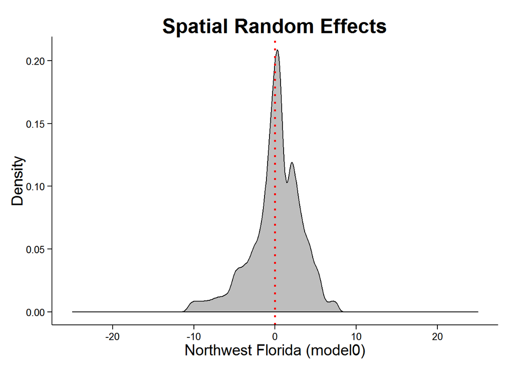

```r
RE.r = Blank.r
Wetlands.spdf$SREm0 = model0$summary.random$Region[,2]
values(RE.r) = (exp(model0$summary.random$Region$mean/10) - 1) * 100

REffect = round(Wetlands.spdf$SREm0, 4)
Var = rep("RE", length(REffect))
RE.df = data.frame(Var, REffect)
RE.df$REffect = as.numeric(RE.df$REffect)

RE.d = ggplot(RE.df, aes(REffect, fill = as.factor(Var))) +
              geom_density(fill = "grey") +
              theme_classic() +
              xlim(-25, 25) +
                 xlab("Northwest Florida (model0)") +
                 ylab("Density") +
                 theme(axis.title.y = element_text(size = 15),
                       axis.title.x = element_text(size = 15),
                       plot.title = element_text(size = 20, face="bold")) +
                 geom_vline(data = RE.df,
                 aes(xintercept = 0,
                     colour = Run),
                     linetype = "dotted",
                     size = 1, col = "red") +
                ggtitle("Spatial Random Effects")

RE.d
```

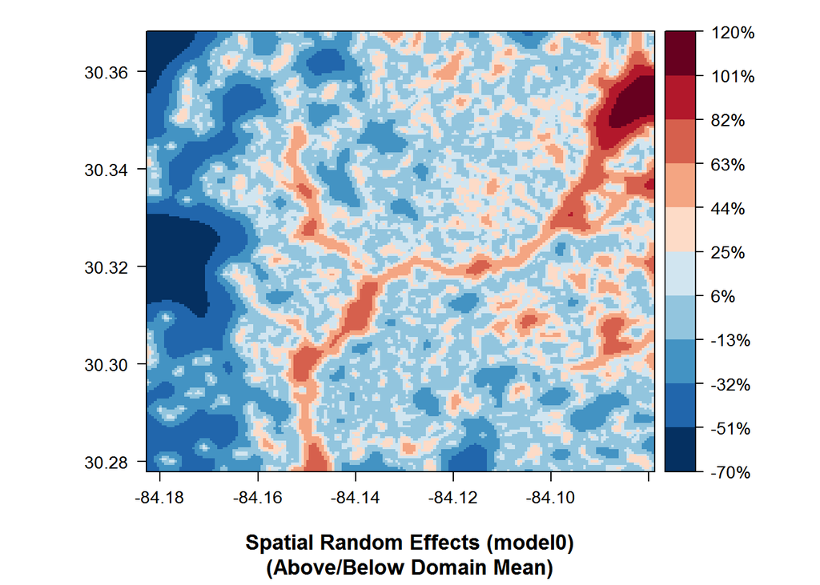

```r
rng = seq(-70, 120, 19)

rngL = paste(rng, '%', sep = "")
cr = rev(brewer.pal(10, "RdBu"))

M0RE = levelplot(RE.r, margin = FALSE,
          sub = "                Spatial Random Effects (model0)                \n(Above/Below Domain Mean)",
          xlab = NULL, ylab = NULL,
          col.regions = cr, at = rng,
          colorkey = list(at = rng, labels = rngL, col = cr),
          par.settings = list(fontsize = list(text = 13)))

M0RE
```

### model1

```r
formula1 = Designation ~ f(Region, model = "besag",
                           adjust.for.con.comp = FALSE,
                           scale.model = TRUE,
                           hyper = hyper.p,
                           graph = J) +
                         V1

model1  =  inla(formula1, family = "binomial",
                       control.family = list(link = "cloglog"),
                       control.predictor = list(compute = TRUE),
                       control.compute=list(cpo = TRUE, waic=TRUE),
                       data = Wetlands.spdf@data)

summary(model1)
```

```
##
## Call:
## c("inla(formula = formula1, family = \"binomial\", data = Wetlands.spdf@data, ",  "    control.compute = list(cpo = TRUE, waic = TRUE), control.predictor = list(compute = TRUE), ",  "    control.family = list(link = \"cloglog\"))")
##
## Time used:
##  Pre-processing    Running inla Post-processing           Total
##          0.9437        907.4659          2.9370        911.3466
##
## Fixed effects:
##                mean     sd 0.025quant 0.5quant 0.975quant    mode kld
## (Intercept) -1.0454 0.0332    -1.1092  -1.0453    -0.9697 -1.0399   0
## V1          -1.7803 0.0334    -1.8450  -1.7806    -1.7133 -1.7810   0
##
## Random effects:
## Name   Model
##  Region   Besags ICAR model
##
## Model hyperparameters:
##                        mean     sd 0.025quant 0.5quant 0.975quant  mode
## Precision for Region 0.2488 0.0121     0.2283   0.2475     0.2756 0.244
##
## Expected number of effective parameters(std dev): 7444.15(80.39)
## Number of equivalent replicates : 5.373
##
## Watanabe-Akaike information criterion (WAIC) ...: 21025.03
## Effective number of parameters .................: 3988.41
##
## Marginal log-Likelihood:  -39005.34
## CPO and PIT are computed
##
## Posterior marginals for linear predictor and fitted values computed
```

```r
Wetlands.spdf@data = Wetlands.spdf@data %>%
                        mutate(M1SLPM = model1$summary.linear.predictor[,"mean"],
                               M1Prob = exp(M1SLPM)/(1+exp(M1SLPM)))
```

### model2

```r
formula2 = Designation ~ f(Region, model = "besag",
                           adjust.for.con.comp = FALSE,
                           scale.model = TRUE,
                           hyper = hyper.p,
                           graph = J) +
                         V1 + AWC

model2  =  inla(formula2, family = "binomial",
                       control.family = list(link = "cloglog"),
                       control.predictor = list(compute = TRUE),
                       control.compute=list(cpo = TRUE, waic=TRUE),
                       data = Wetlands.spdf@data)

summary(model2)
```

```
##
## Call:
## c("inla(formula = formula2, family = \"binomial\", data = Wetlands.spdf@data, ",  "    control.compute = list(cpo = TRUE, waic = TRUE), control.predictor = list(compute = TRUE), ",  "    control.family = list(link = \"cloglog\"))")
##
## Time used:
##  Pre-processing    Running inla Post-processing           Total
##          0.9627        962.4945          4.4769        967.9341
##
## Fixed effects:
##                mean     sd 0.025quant 0.5quant 0.975quant    mode kld
## (Intercept) -2.8211 0.0717    -2.9611  -2.8215    -2.6791 -2.8221   0
## V1          -1.1003 0.0325    -1.1641  -1.1003    -1.0366 -1.1004   0
## AWC          0.1336 0.0042     0.1254   0.1336     0.1419  0.1336   0
##
## Random effects:
## Name   Model
##  Region   Besags ICAR model
##
## Model hyperparameters:
##                        mean     sd 0.025quant 0.5quant 0.975quant  mode
## Precision for Region 0.3082 0.0155     0.2815   0.3068     0.3421 0.303
##
## Expected number of effective parameters(std dev): 6575.04(88.85)
## Number of equivalent replicates : 6.084
##
## Watanabe-Akaike information criterion (WAIC) ...: 21006.58
## Effective number of parameters .................: 3674.28
##
## Marginal log-Likelihood:  -38540.03
## CPO and PIT are computed
##
## Posterior marginals for linear predictor and fitted values computed
```

```r
Wetlands.spdf@data = Wetlands.spdf@data %>%
                        mutate(M2SLPM = model2$summary.linear.predictor[,"mean"],
                               M2Prob = exp(M2SLPM)/(1+exp(M2SLPM)))
```

### model3

```r
formula3 = Designation ~ f(Region, model = "besag",
                           adjust.for.con.comp = FALSE,
                           scale.model = TRUE,
                           hyper = hyper.p,
                           graph = J) +
                         V1 + AWC + OM

model3  =  inla(formula3, family = "binomial",
                       control.family = list(link = "cloglog"),
                       control.predictor = list(compute = TRUE),
                       control.compute=list(cpo = TRUE, waic=TRUE),
                       data = Wetlands.spdf@data)

summary(model3)
```

```
##
## Call:
## c("inla(formula = formula3, family = \"binomial\", data = Wetlands.spdf@data, ",  "    control.compute = list(cpo = TRUE, waic = TRUE), control.predictor = list(compute = TRUE), ",  "    control.family = list(link = \"cloglog\"))")
##
## Time used:
##  Pre-processing    Running inla Post-processing           Total
##          1.0517       1133.2180          2.3706       1136.6403
##
## Fixed effects:
##                mean     sd 0.025quant 0.5quant 0.975quant    mode kld
## (Intercept) -3.5536 0.1040    -3.7642  -3.5507    -3.3582 -3.5432   0
## V1          -1.1456 0.0344    -1.2145  -1.1451    -1.0794 -1.1440   0
## AWC          0.1956 0.0069     0.1822   0.1956     0.2094  0.1954   0
## OM          -0.0005 0.0000    -0.0006  -0.0005    -0.0004 -0.0005   0
##
## Random effects:
## Name   Model
##  Region   Besags ICAR model
##
## Model hyperparameters:
##                        mean     sd 0.025quant 0.5quant 0.975quant   mode
## Precision for Region 0.2828 0.0121     0.2597   0.2825     0.3074 0.2819
##
## Expected number of effective parameters(std dev): 6676.19(101.94)
## Number of equivalent replicates : 5.991
##
## Watanabe-Akaike information criterion (WAIC) ...: 20765.37
## Effective number of parameters .................: 3719.31
##
## Marginal log-Likelihood:  -38498.54
## CPO and PIT are computed
##
## Posterior marginals for linear predictor and fitted values computed
```

```r
Wetlands.spdf@data = Wetlands.spdf@data %>%
                        mutate(M3SLPM = model3$summary.linear.predictor[,"mean"],
                               M3Prob = exp(M3SLPM)/(1+exp(M3SLPM)))
```

### model4

```r
formula4 = Designation ~ f(Region, model = "besag",
                           adjust.for.con.comp = FALSE,
                           scale.model = TRUE,
                           hyper = hyper.p,
                           graph = J) +
                         V1 + AWC + OM + SAVI

model4  =  inla(formula4, family = "binomial",
                       control.family = list(link = "cloglog"),
                       control.predictor = list(compute = TRUE),
                       control.compute=list(cpo = TRUE, waic=TRUE),
                       data = Wetlands.spdf@data)

summary(model4)
```

```
##
## Call:
## c("inla(formula = formula4, family = \"binomial\", data = Wetlands.spdf@data, ",  "    control.compute = list(cpo = TRUE, waic = TRUE), control.predictor = list(compute = TRUE), ",  "    control.family = list(link = \"cloglog\"))")
##
## Time used:
##  Pre-processing    Running inla Post-processing           Total
##          1.1248       1036.2721          2.4799       1039.8769
##
## Fixed effects:
##                mean     sd 0.025quant 0.5quant 0.975quant    mode kld
## (Intercept) -3.6533 0.1447    -3.9420  -3.6516    -3.3741 -3.6477   0
## V1          -1.1453 0.0343    -1.2137  -1.1449    -1.0794 -1.1439   0
## AWC          0.1956 0.0069     0.1822   0.1955     0.2093  0.1954   0
## OM          -0.0005 0.0000    -0.0006  -0.0005    -0.0004 -0.0005   0
## SAVI         0.0903 0.0916    -0.0894   0.0902     0.2702  0.0901   0
##
## Random effects:
## Name   Model
##  Region   Besags ICAR model
##
## Model hyperparameters:
##                        mean     sd 0.025quant 0.5quant 0.975quant   mode
## Precision for Region 0.2834 0.0118     0.2616   0.2829     0.3079 0.2816
##
## Expected number of effective parameters(std dev): 6675.69(99.53)
## Number of equivalent replicates : 5.992
##
## Watanabe-Akaike information criterion (WAIC) ...: 20768.94
## Effective number of parameters .................: 3719.85
##
## Marginal log-Likelihood:  -38504.06
## CPO and PIT are computed
##
## Posterior marginals for linear predictor and fitted values computed
```

```r
Wetlands.spdf@data = Wetlands.spdf@data %>%
                        mutate(M4SLPM = model4$summary.linear.predictor[,"mean"],
                               M4Prob = exp(M4SLPM)/(1+exp(M4SLPM)))
```

### model5

```r
formula5 = Designation ~ f(Region, model = "besag",
                           adjust.for.con.comp = FALSE,
                           scale.model = TRUE,
                           hyper = hyper.p,
                           graph = J) +
                         V1 + AWC + OM + SAVI + TPI

model5  =  inla(formula5, family = "binomial",
                       control.family = list(link = "cloglog"),
                       control.predictor = list(compute = TRUE),
                       control.compute=list(cpo = TRUE, waic=TRUE),
                       data = Wetlands.spdf@data)

summary(model5)
```

```
##
## Call:
## c("inla(formula = formula5, family = \"binomial\", data = Wetlands.spdf@data, ",  "    control.compute = list(cpo = TRUE, waic = TRUE), control.predictor = list(compute = TRUE), ",  "    control.family = list(link = \"cloglog\"))")
##
## Time used:
##  Pre-processing    Running inla Post-processing           Total
##          1.0047       1122.6251          4.9064       1128.5363
##
## Fixed effects:
##                mean     sd 0.025quant 0.5quant 0.975quant    mode kld
## (Intercept) -5.0772 0.1703    -5.4180  -5.0745    -4.7503 -5.0684   0
## V1          -1.1480 0.0380    -1.2237  -1.1475    -1.0747 -1.1466   0
## AWC          0.2029 0.0077     0.1882   0.2029     0.2182  0.2027   0
## OM          -0.0006 0.0000    -0.0007  -0.0006    -0.0005 -0.0006   0
## SAVI         1.0138 0.1053     0.8075   1.0136     1.2208  1.0132   0
## TPI         -2.3684 0.0612    -2.4917  -2.3668    -2.2527 -2.3629   0
##
## Random effects:
## Name   Model
##  Region   Besags ICAR model
##
## Model hyperparameters:
##                        mean     sd 0.025quant 0.5quant 0.975quant   mode
## Precision for Region 0.2413 0.0104     0.2221   0.2409      0.263 0.2398
##
## Expected number of effective parameters(std dev): 6456.27(92.96)
## Number of equivalent replicates : 6.196
##
## Watanabe-Akaike information criterion (WAIC) ...: 18482.07
## Effective number of parameters .................: 3405.13
##
## Marginal log-Likelihood:  -37516.01
## CPO and PIT are computed
##
## Posterior marginals for linear predictor and fitted values computed
```

```r
Wetlands.spdf@data = Wetlands.spdf@data %>%
                        mutate(M5SLPM = model5$summary.linear.predictor[,"mean"],
                               M5Prob = exp(M5SLPM)/(1+exp(M5SLPM)))
```

### model6

```r
formula6 = Designation ~ f(Region, model = "besag",
                           adjust.for.con.comp = FALSE,
                           scale.model = TRUE,
                           hyper = hyper.p,
                           graph = J) +
                         V1 + AWC + OM + SAVI + TPI + CTI

model6  =  inla(formula6, family = "binomial",
                       control.family = list(link = "cloglog"),
                       control.predictor = list(compute = TRUE),
                       control.compute=list(cpo = TRUE, waic=TRUE),
                       data = Wetlands.spdf@data)

summary(model6)
```

```
##
## Call:
## c("inla(formula = formula6, family = \"binomial\", data = Wetlands.spdf@data, ",  "    control.compute = list(cpo = TRUE, waic = TRUE), control.predictor = list(compute = TRUE), ",  "    control.family = list(link = \"cloglog\"))")
##
## Time used:
##  Pre-processing    Running inla Post-processing           Total
##           1.154        1177.437           2.780        1181.371
##
## Fixed effects:
##                mean     sd 0.025quant 0.5quant 0.975quant    mode kld
## (Intercept) -7.3482 0.2452    -7.8385  -7.3446    -6.8771 -7.3364   0
## V1          -1.1142 0.0378    -1.1895  -1.1138    -1.0413 -1.1129   0
## AWC          0.2049 0.0077     0.1901   0.2048     0.2202  0.2047   0
## OM          -0.0006 0.0000    -0.0007  -0.0006    -0.0005 -0.0006   0
## SAVI         0.9328 0.1058     0.7256   0.9326     1.1407  0.9323   0
## TPI         -2.1779 0.0608    -2.3000  -2.1767    -2.0621 -2.1737   0
## CTI          0.2078 0.0142     0.1801   0.2078     0.2359  0.2076   0
##
## Random effects:
## Name   Model
##  Region   Besags ICAR model
##
## Model hyperparameters:
##                        mean     sd 0.025quant 0.5quant 0.975quant   mode
## Precision for Region 0.2448 0.0106     0.2251   0.2443     0.2669 0.2432
##
## Expected number of effective parameters(std dev): 6344.31(92.46)
## Number of equivalent replicates : 6.305
##
## Watanabe-Akaike information criterion (WAIC) ...: 18530.45
## Effective number of parameters .................: 3417.16
##
## Marginal log-Likelihood:  -37441.77
## CPO and PIT are computed
##
## Posterior marginals for linear predictor and fitted values computed
```

```r
Wetlands.spdf@data = Wetlands.spdf@data %>%
                        mutate(M6SLPM = model6$summary.linear.predictor[,"mean"],
                               M6Prob = exp(M6SLPM)/(1+exp(M6SLPM)))
```

### model7

```r
formula7 = Designation ~ f(Region, model = "besag",
                           adjust.for.con.comp = FALSE,
                           scale.model = TRUE,
                           hyper = hyper.p,
                           graph = J) +
                         V1 + V2 + V3 + AWC + OM + CTI + TPI

model7  =  inla(formula7, family = "binomial",
                       control.family = list(link = "cloglog"),
                       control.predictor = list(compute = TRUE),
                       control.compute=list(cpo = TRUE, waic=TRUE),
                       data = Wetlands.spdf@data)

summary(model7)
```

```
##
## Call:
## c("inla(formula = formula7, family = \"binomial\", data = Wetlands.spdf@data, ",  "    control.compute = list(cpo = TRUE, waic = TRUE), control.predictor = list(compute = TRUE), ",  "    control.family = list(link = \"cloglog\"))")
##
## Time used:
##  Pre-processing    Running inla Post-processing           Total
##          1.1698       1265.9630          2.8878       1270.0207
##
## Fixed effects:
##                mean     sd 0.025quant 0.5quant 0.975quant    mode kld
## (Intercept) -5.7235 0.2173    -6.1521  -5.7229    -5.2989 -5.7219   0
## V1          -1.1701 0.0402    -1.2491  -1.1700    -1.0914 -1.1699   0
## V2           0.3401 0.0353     0.2704   0.3402     0.4091  0.3404   0
## V3          -0.2103 0.0290    -0.2672  -0.2104    -0.1535 -0.2104   0
## AWC          0.1543 0.0084     0.1381   0.1542     0.1710  0.1541   0
## OM          -0.0005 0.0000    -0.0006  -0.0005    -0.0004 -0.0005   0
## CTI          0.2287 0.0142     0.2010   0.2287     0.2567  0.2286   0
## TPI         -2.0514 0.0575    -2.1636  -2.0517    -1.9381 -2.0525   0
##
## Random effects:
## Name   Model
##  Region   Besags ICAR model
##
## Model hyperparameters:
##                        mean     sd 0.025quant 0.5quant 0.975quant   mode
## Precision for Region 0.2453 0.0111     0.2257   0.2445      0.269 0.2424
##
## Expected number of effective parameters(std dev): 6418.21(80.27)
## Number of equivalent replicates : 6.232
##
## Watanabe-Akaike information criterion (WAIC) ...: 18402.61
## Effective number of parameters .................: 3439.23
##
## Marginal log-Likelihood:  -37412.51
## CPO and PIT are computed
##
## Posterior marginals for linear predictor and fitted values computed
```

```r
Wetlands.spdf@data = Wetlands.spdf@data %>%
                        mutate(M7SLPM = model7$summary.linear.predictor[,"mean"],
                               M7Prob = exp(M7SLPM)/(1+exp(M7SLPM)))
```